# Port Everglades and Broward–Miami Coral Survey Data Analysis

## 3.3 Filter by habitat

```r
allsitemd %>% count(Type)
```

```
## # A tibble: 10 × 2
##    Type                                          n
##    <chr>                                     <int>
##  1 Aggregated Patch Reef                        45
##  2 Artificial                                   64
##  3 Inlet Channel                                 1
##  4 Inner Reef                                  173
##  5 Middle Reef                                 175
##  6 Nearshore Ridge Complex                     288
##  7 Outer Reef                                  231
##  8 Ridge                                         2
##  9 Sand                                          9
## 10 Scattered Rock in Unconsolidated Sediment     2
```

```r
# Select sites in Nearshore Ridge Complex, Inner Reef, and Middle Reef, Outer Reef and Aggregated Patch Reef
selected <- allsitemd %>%
  filter(Type %in% c("Nearshore Ridge Complex", "Inner Reef", "Middle Reef",
                     "Artificial", "Outer Reef", "Aggregated Patch Reef"))

# Which sites were excluded?
excluded <- anti_join(allsitemd, selected)

excluded %>%
  count(dataset, Type)
```

```
## # A tibble: 7 × 3
##   dataset   Type                                          n
##   <chr>     <chr>                                     <int>
## 1 dca17_esa Ridge                                         2
## 2 dca17_esa Sand                                          6
## 3 drm24     Sand                                          1
## 4 nsu11_esa Sand                                          2
## 5 nsu11_esa Scattered Rock in Unconsolidated Sediment     1
## 6 tt21      Inlet Channel                                 1
## 7 tt21      Scattered Rock in Unconsolidated Sediment     1
```

```r
# Filter dataset to just selected sites
dff0 <- df_completed %>% inner_join(selected)
dff <- df_completed %>% inner_join(selected)
```

Shedd dataset has some sites in the NRC south that are further from the channel relative to other datasets. Are these similar enough to the NRC south sites that are closer to the channel that they can be reasonably included?

First, look at total coral density between the nearer vs. farther sites

```r
drm24_NRCS <- drm24_counts_ag %>%
  left_join(allsitemd) %>%
  filter(Type == "Nearshore Ridge Complex", dir == "S")

drm24_NRCS <- drm24_NRCS %>%
  mutate(grp = if_else(latitude > 26.08, "near", "far"))

# Fit a Negative Binomial GLM
mod_nb <- MASS::glm.nb(n ~ grp, data = drm24_NRCS)

# Generate prediction grid for far/near sites
newdata_1 <- drm24_NRCS %>%
  distinct(grp)

# Get predicted values & standard errors (log scale)
preds_nb <- predict(mod_nb, newdata_1, type = "link", se.fit = TRUE)

# Compute total coral density
results_nb <- newdata_1 %>%
  mutate(
    fit = exp(preds_nb$fit),                    # Convert fitted values to response scale
    fit_se = exp(preds_nb$fit) * preds_nb$se.fit,   # Convert SE using the Delta Method
    fit_var = (fit * preds_nb$se.fit)^2,         # Variance propagation
    fit_lower = exp(preds_nb$fit - 1.96 * preds_nb$se.fit),  # Lower CI
    fit_upper = exp(preds_nb$fit + 1.96 * preds_nb$se.fit)   # Upper CI
  )

# Compute total coral density + confidence intervals
total_ci_nb <- results_nb %>%
  group_by(grp) %>%
  summarize(
    total_density = sum(fit),
    total_se = sqrt(sum(fit_var)),
    lower_95CI = exp(log(total_density) - 1.96 * (total_se / total_density)),
    upper_95CI = exp(log(total_density) + 1.96 * (total_se / total_density))
  )

knitr::kable(total_ci_nb)
```

| grp | total_density | total_se | lower_95CI | upper_95CI |
| --- | --- | --- | --- | --- |
| far | 0.7357724 | 0.1482593 | 0.4957033 | 1.0921069 |
| near | 0.5073171 | 0.0803872 | 0.3718771 | 0.6920851 |

Next, look at community composition between the nearer vs. farther sites

```r
# Create a wide community matrix: rows = site x grp, columns = taxa
comm_matrix <- drm24_NRCS %>%
  group_by(site, grp, taxon) %>%
  summarize(total_n = sum(n), .groups = "drop") %>%
  pivot_wider(names_from = taxon, values_from = total_n, values_fill = 0)

# Extract community matrix and metadata
comm_data <- comm_matrix %>% select(-site, -grp)
site_info <- comm_matrix %>% select(site, grp)

# Run NMDS
set.seed(123)
nmds <- metaMDS(comm_data, distance = "bray", k = 2, trymax = 100)
```

```
## Square root transformation
## Wisconsin double standardization
## *** Best solution repeated 11 times
```

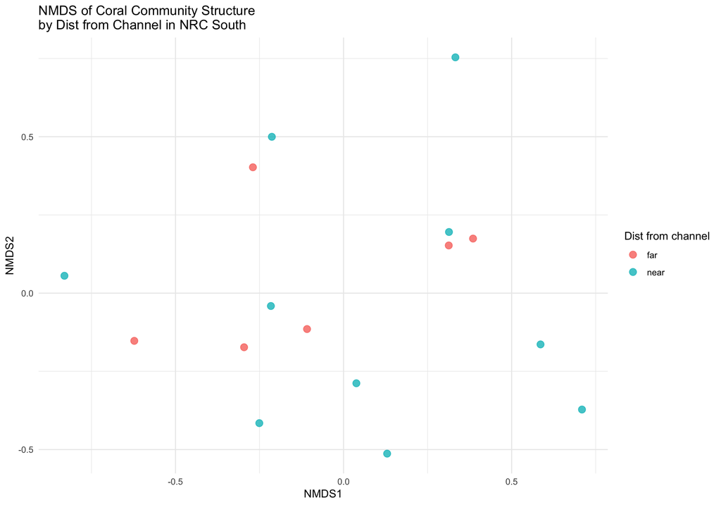

```r
# Prepare data for plotting
scores_df <- scores(nmds)$sites %>%
  bind_cols(site_info)

# Plot NMDS
ggplot(scores_df, aes(x = NMDS1, y = NMDS2, color = grp)) +
  geom_point(size = 3, alpha = 0.8) +
  theme_minimal() +
  labs(title = "NMDS of Coral Community Structure\nby Dist from Channel in NRC South",
       color = "Dist from channel")
```

Density and community composition are not different in the NRC S sites that are nearer vs. farther from the channel. So, no need to exclude the farther sites.

DCA dataset has the most sites in the “Artificial” habitat classification. (Some in other datasets too, but DCA has most). Can ‘Artificial’ be aggregated with ‘Nearshore Ridge Complex’?

‘Artificial’ is only present in DCA and minorly in TT – but absent from Shedd.  
It is in close spatial proximity to Nearshore Ridge Complex – can these be combined?

Test for differences in coral density in DCA survey between habitat types

```r
# Subset DCA data
dcadf <- dca17_counts_ag %>%
  left_join(allsitemd)

# Fit a Negative Binomial GLM
mod_nb <- MASS::glm.nb(n ~ Type, data = dcadf)

# Generate new data only for existing habitats
newdata_1 <- dcadf %>%
  distinct(Type)

# Get predicted values & standard errors (log scale)
preds_nb <- predict(mod_nb, newdata_1, type = "link", se.fit = TRUE)

# Compute total coral density per habitat
results_nb <- newdata_1 %>%
  mutate(
    fit = exp(preds_nb$fit),                    # Convert fitted values to response scale
    fit_se = exp(preds_nb$fit) * preds_nb$se.fit,   # Convert SE using the Delta Method
    fit_var = (fit * preds_nb$se.fit)^2,         # Variance propagation
    fit_lower = exp(preds_nb$fit - 1.96 * preds_nb$se.fit),  # Lower CI
    fit_upper = exp(preds_nb$fit + 1.96 * preds_nb$se.fit)   # Upper CI
  )

# Compute total coral density + confidence intervals
total_ci_nb <- results_nb %>%
  group_by(Type) %>%
  summarize(
    total_density = sum(fit),
    total_se = sqrt(sum(fit_var)),
    lower_95CI = exp(log(total_density) - 1.96 * (total_se / total_density)),
    upper_95CI = exp(log(total_density) + 1.96 * (total_se / total_density))
  )

knitr::kable(total_ci_nb)
```

| Type | total_density | total_se | lower_95CI | upper_95CI |
| --- | --- | --- | --- | --- |
| Aggregated Patch Reef | 1.3971429 | 0.1634482 | 1.1108594 | 1.757205 |
| Artificial | 1.5571429 | 0.1814656 | 1.2391666 | 1.956713 |
| Inner Reef | 1.2116883 | 0.1359261 | 0.9725281 | 1.509662 |
| Middle Reef | 0.7593407 | 0.0803194 | 0.6171618 | 0.934274 |
| Nearshore Ridge Complex | 1.7598639 | 0.1409740 | 1.5041540 | 2.059045 |
| Outer Reef | 1.4123077 | 0.0916120 | 1.2436939 | 1.603781 |

Highly overlapping confidence intervals for Artifical and Nearshore Ridge Complex, so no difference in coral density.

Test for differences in community composition in DCA survey

```r
# Create a wide community matrix: rows = site x Type, columns = taxa
comm_matrix <- dcadf %>%
  group_by(site, Type, taxon) %>%
  summarize(total_n = sum(n), .groups = "drop") %>%
  pivot_wider(names_from = taxon, values_from = total_n, values_fill = 0)

# Extract community matrix and metadata
comm_data <- comm_matrix %>% select(-site, -Type)
site_info <- comm_matrix %>% select(site, Type)

# Run NMDS
set.seed(123)
nmds <- metaMDS(comm_data, distance = "bray", k = 2, trymax = 100)
```

```
## Square root transformation
## Wisconsin double standardization
## *** Best solution repeated 1 times
```

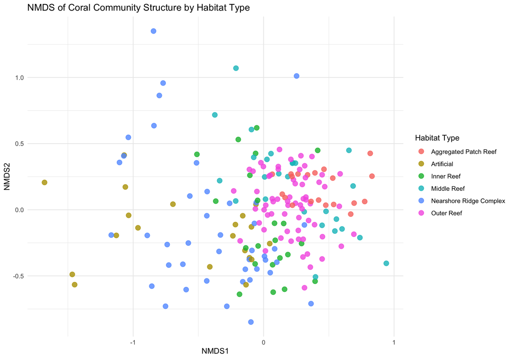

```r
# Prepare data for plotting
scores_df <- scores(nmds)$sites %>%
  bind_cols(site_info)

# Plot NMDS
ggplot(scores_df, aes(x = NMDS1, y = NMDS2, color = Type)) +
  geom_point(size = 3, alpha = 0.8) +
  theme_minimal() +
  labs(title = "NMDS of Coral Community Structure by Habitat Type",
       color = "Habitat Type")
```

High degree of similarity between Artificial and Nearshore Ridge Complex coral communities.

Combine ‘Artificial’ with ‘Nearshore Ridge Complex’

```r
# Based on these results, combine "Artificial" with "Nearshore Ridge Complex"
dff[dff$Type == "Artificial", "Type"] <- "Nearshore Ridge Complex"
```

Combine ‘Aggregated Patch Reef’ with ‘Outer Reef’, following previous studies (DCA)

```r
dff[dff$Type == "Aggregated Patch Reef", "Type"] <- "Outer Reef"

dff <- dff %>% mutate(Type = factor(Type, levels = type_levels))
```

Remove ACER (zeros) from tt23 dataset

```r
dstax <- dff %>%
  filter(!dataset %in% c("nsu11_esa", "dca17_esa")) %>%
  filter(n > 0) %>%
  distinct(dataset, taxon)

dstax %>%
  count(dataset) %>%
  print(n = nrow(.))
```

```
## # A tibble: 4 × 2
##   dataset     n
##   <chr>   <int>
## 1 dca17      20
## 2 drm24      20
## 3 tt21       19
## 4 tt23       19
```

```r
dstax %>%
  count(taxon)
```

```
## # A tibble: 20 × 2
##    taxon     n
##    <chr> <int>
##  1 ACER      3
##  2 AGAR      4
##  3 CNAT      3
##  4 DLAB      4
##  5 DSTO      4
##  6 EFAS      4
##  7 FAVI      4
##  8 MADR      4
##  9 MCAV      4
## 10 MEAN      4
## 11 MMEA      4
## 12 MUSS      4
## 13 MYCE      4
## 14 ORBI      4
## 15 PCLI      4
## 16 PORI      4
## 17 PSTR      4
## 18 SIDE      4
## 19 SINT      4
## 20 SOLE      4
```

```r
# CNAT not observed in TT21 (super rare)
# ACER not observed in TT23 (known habitat distribution was NOT SURVEYED)

## remove ACER from tt23 dff
dff <- dff %>%
  filter(!(taxon == "ACER" & dataset == "tt23"))
```

# 4 Summarize combined dataset

```r
# Count number of sites per habitat
nsites <- dff %>%
  group_by(dataset, Type) %>%
  summarize(n = n_distinct(site)) %>%
  mutate(Type = factor(Type, levels = type_levels)) %>%
  arrange(Type) %>%
  pivot_wider(names_from = Type, values_from = n, values_fill = 0) %>%
  janitor::adorn_totals(where = "col", name = "Total Sites")

# Get area surveyed per transect and total area surveyed
area_per_site <- dff %>%
  group_by(dataset) %>%
  summarise(
    area_per_site = {
      r <- range(transect_area_m2)
      if (r[1] == r[2]) as.character(r[1]) else paste(r, collapse = " - ")})

total_area <- dff %>%
  group_by(dataset, site) %>%
  summarize(max_area = max(transect_area_m2)) %>%
  summarize(total_area = round(sum(max_area), 0))

# Get total number of corals counted
total_corals <- dff %>%
  group_by(dataset) %>%
  summarize(total_n = sum(n))

survey_summary <- reduce(
  list(nsites, area_per_site, total_area, total_corals),
  full_join,
  by = "dataset"
) %>%
  mutate(dataset = factor(dataset, levels = dataset_levels)) %>%
  arrange(dataset) %>%
  janitor::adorn_totals(where = "row") %>%
  mutate(dataset2 = c(dataset_labels, "Total"))

dir.create(output_file("intermediate"), recursive = TRUE, showWarnings = FALSE)
write_csv(survey_summary, file = output_file("intermediate/coral_Table1.csv"))

survey_summary %>% knitr::kable()
```

| dataset | Nearshore Ridge Complex | Inner Reef | Middle Reef | Outer Reef | Total Sites | area_per_site | total_area | total_n | dataset2 |
| --- | --- | --- | --- | --- | --- | --- | --- | --- | --- |
| nsu11_esa | 85 | 94 | 83 | 111 | 373 | 3600 | 1342800 | 11871 | 2011 / NSU ESA |
| dca17_esa | 92 | 17 | 21 | 25 | 155 | 784 | 121520 | 3620 | 2017 / DCA ESA |
| dca17 | 62 | 22 | 26 | 85 | 195 | 30 | 5850 | 9489 | 2017 / DCA Recon |
| tt21 | 7 | 6 | 5 | 17 | 35 | 3.9 - 784 | 24314 | 2172 | 2021 / Tetra Tech |
| tt23 | 81 | 19 | 34 | 38 | 172 | 10 - 20 | 3180 | 5691 | 2023 / Tetra Tech |
| drm24 | 25 | 15 | 6 | 0 | 46 | 20 - 40 | 1840 | 2566 | 2024 / Shedd |
| Total | 352 | 173 | 175 | 276 | 976 | - | 1499504 | 35409 | Total |

```r
# Summarize count data
# Just get columns we need for modeling
dfftaxon <- dff %>% select(dataset, Type, dir, site, transect_area_m2, taxon, class, n)
write_csv(dfftaxon, file = processed_file("all_coral_counts_processed.csv"))

# Number of observations/counts
nrow(dfftaxon)
```

```
## [1] 14387
```

```r
# Number of colonies counted
sum(dfftaxon$n)
```

```
## [1] 35409
```

```r
# Number of taxa observed
n_distinct(dfftaxon$taxon)
```

```
## [1] 20
```

```r
# Number of sites surveyed
n_distinct(interaction(dfftaxon$dataset, dfftaxon$site))
```

```
## [1] 976
```

```r
# Zero-inflation / Number of zeros
table(dfftaxon$n == 0)
```

```
##
## FALSE  TRUE
##  4444  9943
```

```r
# Overdispersion
mean_count <- mean(dfftaxon$n)
var_count <- var(dfftaxon$n)
var_count / mean_count
```

```
## [1] 70.3437
```

```r
# Data are highly zero-inflated and overdispersed -- use zero-inflated negative binomial models.
```

# 5 Map surveys & impact zones

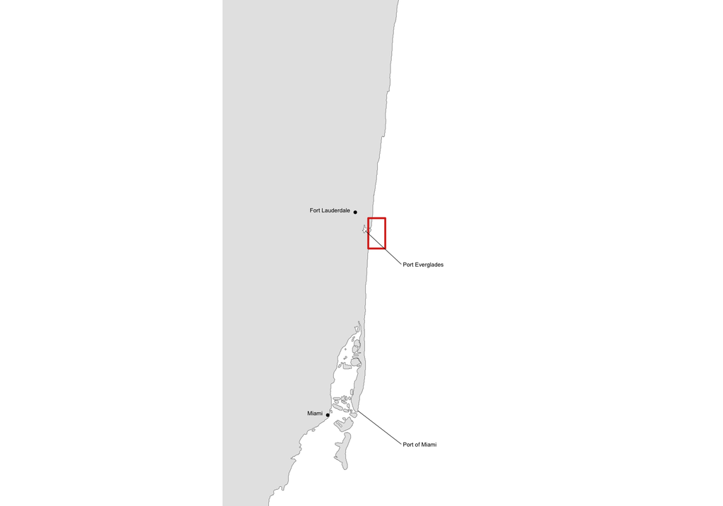

```r
# High-resolution SE Florida coastline with GSHHG (no counties), plus ports & study box
# ------------------------------------------------------------------------------------
# Install if needed:
# install.packages(c("sf","dplyr","ggplot2"))
# (No special geofabrik/overpass/hires packages required)

library(sf)
library(dplyr)
library(ggplot2)

# 1) Define your exact view bbox (SE Florida)
bbox_view <- st_bbox(c(
  xmin = -80.4, ymin = 25.60,
  xmax = -79.85, ymax = 26.50
), crs = st_crs(4326))

# Slight pad for safety when cropping
pad <- 0.05
bbox_pad <- bbox_view
bbox_pad["xmin"] <- bbox_view["xmin"] - pad
bbox_pad["ymin"] <- bbox_view["ymin"] - pad
bbox_pad["xmax"] <- bbox_view["xmax"] + pad
bbox_pad["ymax"] <- bbox_view["ymax"] + pad

# 2) Read the bundled full-resolution regional coastline (GSHHG 2.3.7).
# Source and crop bounds are documented in data/spatial/README.md.
gshhg_coast <- st_read("data/spatial/SE_Florida_coast.gpkg", quiet = TRUE) |>
  st_transform(4326)

# 3) Crop to your SE Florida view and convert to outlines (boundaries)
# 3) Validate, crop with s2 off, then take boundaries
bbox_pad_sfc <- st_as_sfc(bbox_pad)

# save current s2 setting and turn it off just for the clip
old_s2 <- sf::sf_use_s2()
sf::sf_use_s2(FALSE)
on.exit(sf::sf_use_s2(old_s2), add = TRUE)

# fix invalid rings, then clip to bbox
gshhg_valid <- sf::st_make_valid(gshhg_coast)
coast_crop  <- suppressWarnings(st_intersection(gshhg_valid, bbox_pad_sfc))

# optional: keep only polygons (in case multiparts/lines slipped in)
coast_crop  <- st_collection_extract(coast_crop, "POLYGON")

coast_line <- st_boundary(coast_crop)  # draw only the outline (crisp line map)

# 4) Annotations: ports + your detailed study box
ports <- tibble::tibble(
  name = c("Port Everglades", "Port of Miami"),
  lon  = c(-80.118, -80.133),
  lat  = c(26.090, 25.770)
)
cities <- tibble::tibble(
  name = c("Miami", "Fort Lauderdale"),
  lon = c(-80.1918, -80.1373),
  lat = c(25.7617, 26.1224)
)

study_box <- st_as_sfc(st_bbox(
  c(xmin = -80.1116, xmax = -80.078, ymin = 26.058, ymax = 26.112),
  crs = 4326
))

# 5) Plot: ultra-clean coastline outline + study box + ports
p_sef_gshhg <- ggplot() +
  geom_sf(data = coast_crop, fill = "gray90", color = "black", linewidth = 0.1) +
  geom_sf(data = study_box, fill = NA, color = "#D7301F", linewidth = 0.9) +
  geom_text_repel(data = ports, aes(lon, lat, label = name), hjust = 0, size = 2, nudge_y = -0.06,
                  xlim = c(-80.05, NA), segment.size = 0.2) +
  geom_point(data = cities, aes(lon, lat), size = 1) +
  geom_text(data = cities, aes(lon, lat, label = name), hjust = 1, vjust = 0, size = 2, nudge_x = -0.01) +
  coord_sf(xlim = c(bbox_view["xmin"], bbox_view["xmax"]),
           ylim = c(bbox_view["ymin"], bbox_view["ymax"]),
           expand = FALSE) +
  theme_void()

p_sef_gshhg
```

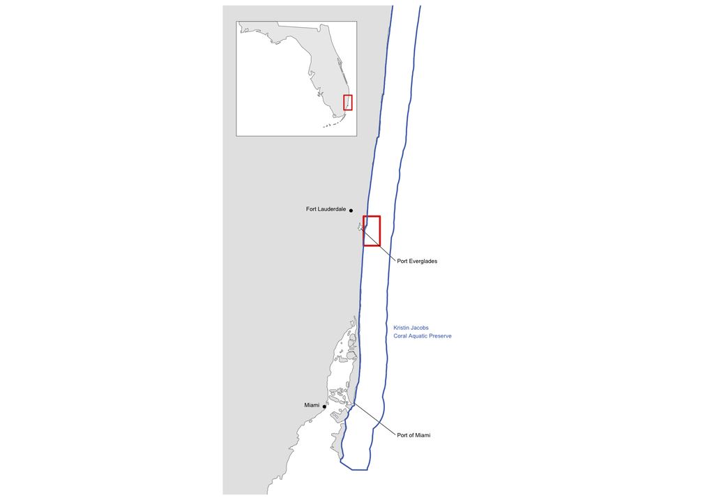

```r
# KJ Coral Reef ECA
kj_eca <- st_read("data/spatial/KJ_Coral_Aquatic_Preserve.gpkg", quiet = TRUE)

# Add to your existing map (choose fill/line to taste)
p_sef_map <- p_sef_gshhg +   # or p_sef_gshhg / p_sef_hi, etc.
  geom_sf(data = kj_eca, fill = NA, color = "#4B6CB7", linewidth = 0.6) +
  # or with a subtle transparent fill:
  # geom_sf(data = kj_eca, fill = scales::alpha("#4B6CB7", 0.08), color = "#4B6CB7", linewidth = 0.4)
    coord_sf(xlim = c(bbox_view["xmin"], bbox_view["xmax"]),
           ylim = c(bbox_view["ymin"], bbox_view["ymax"]),
           expand = FALSE) +
  annotate("text", x = -80.05, y = 25.9, label = "Kristin Jacobs\nCoral Aquatic Preserve",
           color = "#4B6CB7", hjust = 0, size = 2)

#p_sef_map



#####
library(rnaturalearth)
library(rnaturalearthdata)

# 1) Get a simple USA states outline
# Use the bundled Natural Earth state layer: no network download.
usa_states <- st_as_sf(rnaturalearthdata::states50)
fl_outline <- usa_states %>% filter(name == "Florida")

# 2) Define a Florida-wide bbox for inset
fl_bbox <- st_bbox(c(
  xmin = -87.8, ymin = 24.0,
  xmax = -79.5, ymax = 31.0
), crs = st_crs(4326))
fl_bbox_sfc <- st_as_sfc(fl_bbox)

# 3) Build inset plot with simple Florida outline + red box for SE FL extent
p_inset_simple <- ggplot() +
  geom_sf(data = fl_outline, fill = "grey92", color = "black", linewidth = 0.1) +
  geom_sf(data = st_as_sfc(bbox_view), fill = NA, color = "#D7301F", linewidth = 0.6) +
  coord_sf(xlim = c(fl_bbox["xmin"], fl_bbox["xmax"]),
           ylim = c(fl_bbox["ymin"], fl_bbox["ymax"]),
           expand = FALSE) +
  theme_void() +
  theme(
    panel.border = element_rect(color = "black", fill = NA, linewidth = 0.25), # <-- border
    panel.background = element_rect(color = "black", fill = "white", linewidth = 0) # <-- border
  )

# 4) Add inset to your detailed SE Florida map
p_final_with_inset <- p_sef_map +
  theme(plot.margin = margin(0,-10,0,0)) +
  # theme(
  #   plot.background = element_rect(
  #     color = "black",   # border color
  #     fill  = "white",   # background fill
  #     linewidth = 1      # thickness of the border
  #   )
  # ) +
  inset_element(p_inset_simple,
                left = 0.05, bottom = 0.6, right = 0.5, top = 1.1,
                align_to = "panel")

p_final_with_inset
```

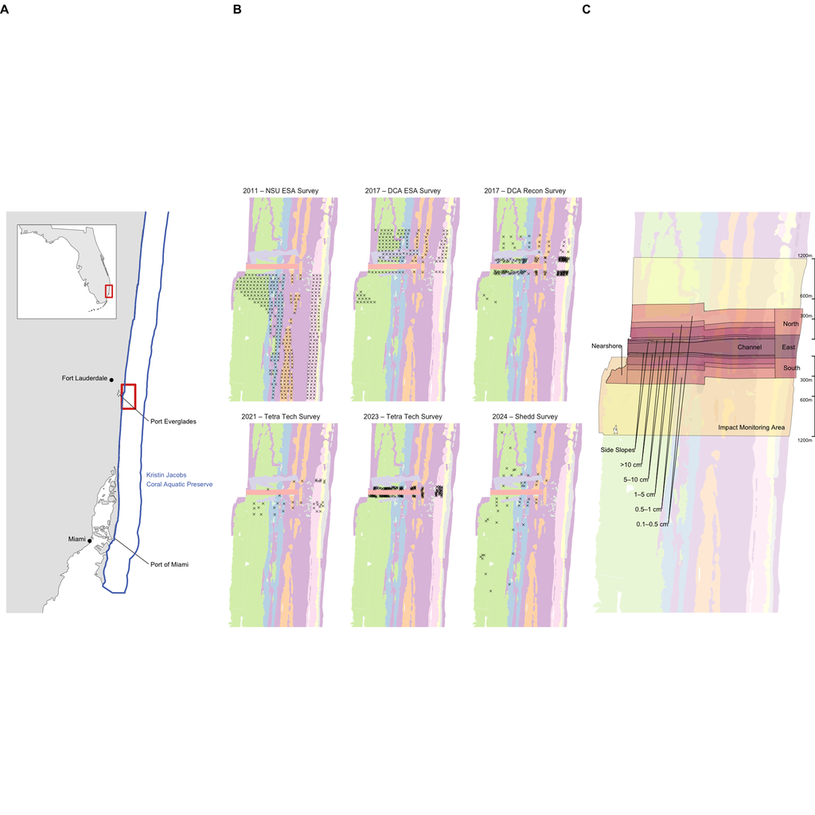

```r
# Define shared coordinate limits
coord_limits <- coord_sf(
  xlim = c(-80.1116, -80.078),
  ylim = c(26.058, 26.112),
  expand = FALSE#, clip = "off"#,
  #datum = NA  # avoid graticule
)

# Simplified base theme for clean layout
base_theme <- theme_minimal(base_size = 8) +
  theme(
    axis.title = element_blank(),
    axis.text = element_blank(),
    #axis.ticks = element_blank(),
    panel.grid = element_blank(),
    plot.margin = margin(t = 12, r = 5, b = 5, l = 5),
  )

# Reorder survey datasets
selected <- selected %>% mutate(dataset = factor(dataset, levels = c("nsu11_esa", "dca17_esa", "dca17", "tt21", "tt23", "drm24")))


# Left panel: faceted survey locations
pp2 <- ggplot(polygons_final) +
  # LAND background (from NOAA GSHHG)
  #geom_sf(data = land_zoom, fill = "grey90", color = "grey65", linewidth = 0.15) +

  geom_sf(aes(fill = Type), color = NA, size = 0.1, alpha = 0.5) +
  geom_point(
    data = selected,
    aes(x = longitude, y = latitude),
    pch = 4, alpha = 0.6, size = 0.65, stroke = 0.3, inherit.aes = FALSE
  ) +
  #scale_fill_brewer(palette = "Set3", na.value = "gray80") +
  scale_fill_manual(values = typecols, na.value = "gray80") +
  facet_wrap(~ dataset, ncol = 3,
               labeller = as_labeller(c(
    "nsu11_esa" = "2011 – NSU ESA Survey",
    "dca17_esa" = "2017 – DCA ESA Survey",
    "dca17"     = "2017 – DCA Recon Survey",
    "tt21"      = "2021 – Tetra Tech Survey",
    "tt23"      = "2023 – Tetra Tech Survey",
    "drm24"     = "2024 – Shedd Survey"
  ))) +
  coord_limits +
  scale_x_continuous(breaks = c(-80.11, -80.10, -80.09, -80.08)) +
  labs(title = NULL, fill = NULL) +
  base_theme +
  theme(
    legend.position = "none",
    strip.text = element_text(size = 6),
    panel.spacing = unit(0.5, "lines"),
    plot.margin = margin(2,0,0,-10)
  )

# Right panel: impact zones
iz_plot_clean <- p +
  geom_segment(data = label_segments,
               aes(x = segment_x, y = segment_y,
                   xend = label_x, yend = label_y),
               color = "black", linewidth = 0.2) +
  geom_text(data = zone_labels,
            aes(x = label_x, y = label_y, label = name),
            size = 2, hjust = 1) +
  coord_sf(xlim = c(-80.1116, -80.077), ylim = c(26.058, 26.112), expand = FALSE) +
  base_theme +
  theme(legend.position = "none") +
  geom_segment(
    data = scale_lines,
    aes(x = x, y = y, xend = xend, yend = yend),
    inherit.aes = FALSE,
    color = "black",
    linewidth = 0.4
  ) +
  geom_segment(
    data = ticks_segments,
    aes(x = x, y = y, xend = xend, yend = yend),
    color = "black",
    linewidth = 0.3
  ) +
  geom_text(
    data = tick_labels,
    aes(x = x, y = y, label = label),
    hjust = 1,
    vjust = c(rep(1.5, 4), rep(-0.5, 4)),
    size = 1.5
  ) +
  theme(plot.margin = margin(0,0,0,0))

dir.create(output_file("intermediate"), recursive = TRUE, showWarnings = FALSE)
saveRDS(p_final_with_inset, output_file("intermediate/coral_fig1_panel_a_ggplot.rds"))
saveRDS(iz_plot_clean, output_file("intermediate/coral_fig1_panel_c_ggplot.rds"))
save_figure(
  output_file("intermediate/coral_fig1_panel_c.png"),
  iz_plot_clean,
  width = 85,
  height = 120,
  units = "mm",
  dpi = 300,
  bg = "white"
)

# # Set y tick positions and labels manually
# y_breaks <- c(26.06, 26.07, 26.08, 26.11)  # adjust to match your plot extent
# x_right_label <- -80.08  # just outside your xlim max
#
# right_axis_labels <- tibble(
#   x = x_right_label,
#   y = y_breaks,
#   label = scales::number(y_breaks, accuracy = 0.01)
# )
#
# x_breaks <- c(-80.09, -80.10, -80.11)
# y_bottom_label <- 26.06
# bottom_axis_labels <- tibble(x = x_breaks, y = y_bottom_label,
#                              label = scales::number(x_breaks, accuracy = 0.01))

# iz_plot_clean <- iz_plot_clean +
#   geom_text(data = right_axis_labels,
#             aes(x = x, y = y, label = label),
#             size = 2, hjust = 1, vjust = 0, fontface = "italic", color = "gray") +
#   geom_text(data = bottom_axis_labels,
#             aes(x = x, y = y, label = label),
#             size = 2, hjust = 0, vjust = 1, fontface = "italic", color = "gray")



# Combine with cowplot
final_fig <- plot_grid(
  p_final_with_inset,
  pp2,
  iz_plot_clean,
  nrow = 1,
  align = "hv",
  axis = "tb",
  labels = c("A", "B", "C"), hjust = 0, label_size = 11,
  rel_widths = c(0.24, 0.36, 0.24)  # adjust until panel areas are visually aligned
)
final_fig
```

```r
# Extract fill legend from habitat polygon plot
legend_plot <- polyplot +
  scale_fill_manual(values = typecols, na.value = "gray80") +
  guides(shape = "none", color = "none", fill = guide_legend(nrow = 2)) +
  base_theme +
  theme(
    legend.position = "bottom",
    legend.key.size = unit(0.3, "cm"),  # Reduce square size
    legend.text = element_text(size = 6),  # Optional: smaller legend text
    legend.title = element_text(size = 7)  # Optional: smaller legend title
  )
grob <- ggplotGrob(legend_plot)
fill_legend <- gtable::gtable_filter(grob, "guide-box")

bottom_row <- plot_grid(NULL, fill_legend, ncol = 2, rel_widths = c(0.2, 0.6))
final_final_fig <- plot_grid(final_fig, bottom_row, ncol = 1, rel_heights = c(0.92, 0.08))

# Save output
save_figure(
  filename = output_file("intermediate/coral_Fig1.png"),
  plot = final_final_fig,
  width = 220,
  height = 125,
  units = "mm",
  dpi = 300,
  bg = "white"
)
```

# 6 Joint adult and juvenile model

## 6.1 Geographic membership and original observations

The original data preparation above is retained so every legacy survey count and searched area is reproducible. Region is assigned from coordinates, not survey team or file membership. Distances are in UTM 17N and measured north or south from the nearest channel bounding edge, not radially from the inlet.

```r
original_survey_counts <- dfftaxon %>%
  mutate(across(c(dataset, site, taxon, class, Type, dir), as.character),
         original_pev_row = row_number())
original_coordinates <- allsitemd %>%
  select(dataset, site, latitude, longitude) %>%
  distinct() %>%
  semi_join(original_survey_counts, by = c("dataset", "site"))
stopifnot(!anyDuplicated(original_coordinates[c("dataset", "site")]))
channel_utm <- channel_poly %>% st_zm() %>% st_transform(32617) %>% st_make_valid()
channel_bounds <- st_bbox(channel_utm)
classify_region <- function(x) {
  stopifnot(all(is.finite(x$latitude)), all(is.finite(x$longitude)))
  points_utm <- st_as_sf(x, coords = c("longitude", "latitude"), crs = 4326) %>%
    st_transform(32617)
  northing <- st_coordinates(points_utm)[, 2]
  x$ns_distance_from_channel_m <- pmax(channel_bounds[["ymin"]] - northing,
                                      northing - channel_bounds[["ymax"]], 0)
  x$region <- ifelse(x$ns_distance_from_channel_m <= 1200, "PEV", "Broward-Miami")
  x
}
original_joint_counts <- original_survey_counts %>%
  left_join(original_coordinates, by = c("dataset", "site")) %>%
  classify_region() %>%
  mutate(source = "Original surveys")
write_csv(original_joint_counts, output_file("original_survey_geographic_assignments.csv"))
geographic_rule <- data.frame(
  rule = "PEV: <=1,200 m N/S of the nearest channel bounding edge",
  crs_epsg = 32617, cutoff_m = 1200,
  channel_ymin_m = channel_bounds[["ymin"]], channel_ymax_m = channel_bounds[["ymax"]],
  pev_ymin_m = channel_bounds[["ymin"]] - 1200,
  pev_ymax_m = channel_bounds[["ymax"]] + 1200
)
write_csv(geographic_rule, output_file("geographic_definition.csv"))
```

## 6.2 Broader Broward–Miami adult observations

The cleaned annual DRM2024 data are authoritative for the added adult counts, as in the evaluated joint fit. The raw worksheets independently establish transect coverage and document the two fully recently dead colonies omitted from the annual file. Identical species and dimensions are never treated as proof that colony records are duplicates.

Existing PEV metadata sites, including deliberately targeted ACER sites and sites omitted from the annual export, are excluded from the *additional* data to prevent double counting. All retained observations are subsequently classified by the same geographic rule. Only Broward–Miami is retained: Biscayne, North/South Palm Beach and Martin are excluded.

```r
annual_environment <- new.env(parent = emptyenv())
load("data/full_drm_2024/2024.RData", envir = annual_environment)
stopifnot("df24" %in% ls(annual_environment))
drm_regional <- annual_environment$df24 %>%
  transmute(site = as.character(Site), transect_num = as.integer(Transect),
            latitude = Latitude, longitude = Longitude,
            subregion = as.character(Subregion), drm_habitat = as.character(Habitat),
            species = as.character(Species), width = Width, height = Height) %>%
  filter(subregion == "Broward-Miami")
regional_site_coordinates <- drm_regional %>%
  filter(transect_num %in% 1:2) %>%
  distinct(site, latitude, longitude, subregion, drm_habitat)
stopifnot(!anyDuplicated(regional_site_coordinates$site))
regional_habitats <- st_read("data/spatial/drm_regional_habitat/habitat_polygons.geojson", quiet = TRUE) %>%
  st_zm() %>% st_transform(32617) %>% st_make_valid()
regional_points <- st_as_sf(regional_site_coordinates,
                            coords = c("longitude", "latitude"), crs = 4326, remove = FALSE) %>%
  st_transform(32617)
regional_hits <- st_join(regional_points, select(regional_habitats, Type, Modifier),
                         join = st_within) %>%
  st_drop_geometry() %>%
  mutate(mapped_type = case_when(Type == "Artificial" ~ "Nearshore Ridge Complex",
                                Type == "Aggregated Patch Reef" ~ "Outer Reef",
                                TRUE ~ as.character(Type)))
all_pev_metadata_ids <- penipsites %>% pull(drm_site_id) %>% as.character()
regional_site_audit <- regional_hits %>%
  group_by(site, latitude, longitude, subregion, drm_habitat) %>%
  summarize(source_types = paste(sort(unique(na.omit(Type))), collapse = "; "),
            reef_types = list(sort(unique(mapped_type[mapped_type %in% type_levels]))),
            .groups = "drop") %>%
  mutate(n_reef_types = lengths(reef_types),
         Type = map_chr(reef_types, ~if (length(.x) == 1) .x else NA_character_),
         in_original_metadata = sub("^AA", "", site) %in% all_pev_metadata_ids,
         exclusion = case_when(
           in_original_metadata ~ "Original metadata site: do not add twice",
           drm_habitat == "PTCH" ~ "DRM PTCH excluded",
           n_reef_types > 1 ~ "Conflicting reef classes",
           n_reef_types == 0 ~ "Outside the four mapped reef strata",
           TRUE ~ "Retained")) %>%
  select(-reef_types)
stopifnot(!any(regional_site_audit$n_reef_types > 1 & !regional_site_audit$in_original_metadata))
regional_sites <- regional_site_audit %>%
  filter(exclusion == "Retained") %>%
  mutate(dir = if_else(latitude > 26.093570, "N", "S")) %>%
  classify_region()
write_csv(regional_site_audit, output_file("regional_site_classification_audit.csv"))
write_csv(regional_sites, output_file("regional_site_metadata.csv"))
show_table(count(regional_site_audit, exclusion))
```

| exclusion | n |
| --- | --- |
| DRM PTCH excluded | 1 |
| Original metadata site: do not add twice | 39 |
| Outside the four mapped reef strata | 5 |
| Retained | 93 |

```r
show_table(count(regional_sites, region, Type))
```

| region | Type | n |
| --- | --- | --- |
| Broward-Miami | Inner Reef | 15 |
| Broward-Miami | Middle Reef | 10 |
| Broward-Miami | Nearshore Ridge Complex | 63 |
| Broward-Miami | Outer Reef | 5 |

```r
target_species <- c("CNAT", "DSTO", "DLAB", "MMEA", "MANG", "MALI", "MFER", "MLAM", "PCLI", "PSTR")
adult_taxa <- original_survey_counts %>% filter(class == ">4cm") %>% pull(taxon) %>% unique() %>% sort()
regional_records <- drm_regional %>% semi_join(regional_sites, by = "site")
missing_sizes <- regional_records %>% filter(!is.na(species), is.na(width) & is.na(height))
unexpected_extra_transects <- regional_records %>%
  filter(transect_num %in% 3:4, !is.na(species), !species %in% target_species)
write_csv(missing_sizes, output_file("adult_colonies_missing_sizes.csv"))
write_csv(unexpected_extra_transects, output_file("adult_nontarget_T3_T4_records.csv"))
stopifnot(nrow(missing_sizes) == 0, nrow(unexpected_extra_transects) == 0)
adult_records <- regional_records %>%
  filter(!is.na(species), species != "", pmax(width, height, na.rm = TRUE) >= 4,
         transect_num %in% 1:2 | (transect_num %in% 3:4 & species %in% target_species)) %>%
  left_join(taxon_lookup, by = c("species" = "taxon")) %>%
  mutate(taxon = coalesce(taxon_group, species))
write_csv(filter(adult_records, !taxon %in% adult_taxa), output_file("regional_adult_taxa_outside_model.csv"))
regional_adults <- expand_grid(site = regional_sites$site, taxon = adult_taxa) %>%
  left_join(count(adult_records, site, taxon, name = "n"), by = c("site", "taxon")) %>%
  mutate(n = replace_na(n, 0L), class = ">4cm", dataset = "drm24",
         transect_area_m2 = if_else(taxon %in% c(target_species, "MYCE"), 40, 20)) %>%
  left_join(select(regional_sites, site, Type, dir, latitude, longitude, region,
                   ns_distance_from_channel_m), by = "site") %>%
  mutate(source = "Added DRM2024 adults")
stopifnot(all(regional_adults$transect_area_m2[regional_adults$taxon == "MYCE"] == 40))
```

## 6.3 Juvenile coverage and adult T3/T4 quality control

All four juvenile groups were searched on all four 10 m² transects. Their searched area is 40 m²/site. Other juvenile taxa were not comprehensively searched at the added sites and receive neither invented observations nor regional table entries. The original PEV juvenile observations are retained.

```r
juvenile_fields <- c(MCAV = "montastraea_ct", MEAN = "meandrinidae_ct",
                     MUSS = "mussinae_ct", FAVI = "faviinae_ct")
juvenile_records <- readxl::read_xlsx("data/2024_shedd_drm/2024ANU_JuvenileCoralData_Shedd.xlsx") %>%
  janitor::clean_names() %>% filter(subregion == "Broward-Miami") %>%
  mutate(site = as.character(site)) %>% semi_join(regional_sites, by = "site")
missing_juvenile_transects <- anti_join(
  crossing(site = regional_sites$site, transect_num = 1:4), juvenile_records,
  by = c("site", "transect_num")
)
stopifnot(nrow(missing_juvenile_transects) == 0,
          !anyDuplicated(juvenile_records[c("site", "transect_num")]),
          all(vapply(juvenile_records[unname(juvenile_fields)],
                     function(x) all(is.finite(x) & x >= 0 & x == round(x)), logical(1))))
juvenile_transect_counts <- juvenile_records %>%
  select(site, transect_num, all_of(unname(juvenile_fields))) %>%
  pivot_longer(all_of(unname(juvenile_fields)), names_to = "field", values_to = "n") %>%
  mutate(taxon = names(juvenile_fields)[match(field, juvenile_fields)],
         class = "<4cm", transect_area_m2 = 10)
regional_juveniles <- juvenile_transect_counts %>%
  group_by(site, taxon, class) %>%
  summarize(n = sum(n), transect_area_m2 = sum(transect_area_m2), .groups = "drop") %>%
  left_join(select(regional_sites, site, Type, dir, latitude, longitude, region,
                   ns_distance_from_channel_m), by = "site") %>%
  mutate(dataset = "drm24", source = "Added DRM2024 juveniles")
juvenile_audit <- juvenile_transect_counts %>%
  group_by(taxon, transect_num) %>%
  summarize(sites = n_distinct(site), colonies = sum(n), searched_m2 = sum(transect_area_m2),
            .groups = "drop")
write_csv(juvenile_transect_counts, output_file("regional_juvenile_transect_counts.csv"))
write_csv(juvenile_audit, output_file("juvenile_transect_audit.csv"))
show_table(juvenile_audit)
```

| taxon | transect_num | sites | colonies | searched_m2 |
| --- | --- | --- | --- | --- |
| FAVI | 1 | 93 | 0 | 930 |
| FAVI | 2 | 93 | 7 | 930 |
| FAVI | 3 | 93 | 4 | 930 |
| FAVI | 4 | 93 | 4 | 930 |
| MCAV | 1 | 93 | 58 | 930 |
| MCAV | 2 | 93 | 50 | 930 |
| MCAV | 3 | 93 | 54 | 930 |
| MCAV | 4 | 93 | 48 | 930 |
| MEAN | 1 | 93 | 6 | 930 |
| MEAN | 2 | 93 | 9 | 930 |
| MEAN | 3 | 93 | 12 | 930 |
| MEAN | 4 | 93 | 4 | 930 |
| MUSS | 1 | 93 | 9 | 930 |
| MUSS | 2 | 93 | 5 | 930 |
| MUSS | 3 | 93 | 3 | 930 |
| MUSS | 4 | 93 | 3 | 930 |

```r
adult_worksheet_files <- file.path("data/2024_shedd_drm", c(
  "2024ANU_RawCoralDataTransect1and2_Shedd.xlsx",
  "2024ANU_RawCoralDataTransect3and4_Shedd.xlsx"
))
adult_worksheet <- map_dfr(adult_worksheet_files, ~readxl::read_xlsx(.x, guess_max = 50000) %>%
                            janitor::clean_names()) %>%
  filter(subregion == "Broward-Miami") %>% mutate(site = as.character(site)) %>%
  semi_join(regional_sites, by = "site")
missing_adult_transects <- anti_join(crossing(site = regional_sites$site, transect_num = 1:4),
                                    distinct(adult_worksheet, site, transect_num),
                                    by = c("site", "transect_num"))
stopifnot(nrow(missing_adult_transects) == 0)
adult_audit <- adult_worksheet %>% group_by(transect_num) %>%
  summarize(sites = n_distinct(site), raw_rows = n(), recorded_colonies = sum(!is.na(species)),
            .groups = "drop")
comparison_keys <- c("site", "transect_num", "species", "width", "height")
adult_record_comparison <- full_join(
  adult_worksheet %>% filter(!is.na(species)) %>% count(across(all_of(comparison_keys)), name = "worksheet_rows"),
  regional_records %>% filter(!is.na(species)) %>% count(across(all_of(comparison_keys)), name = "annual_rows"),
  by = comparison_keys
) %>% mutate(across(c(worksheet_rows, annual_rows), ~replace_na(.x, 0L)),
             difference = worksheet_rows - annual_rows)
adult_record_differences <- filter(adult_record_comparison, difference != 0)
stopifnot(nrow(adult_record_differences) == 2,
          setequal(paste(adult_record_differences$site, adult_record_differences$transect_num,
                         adult_record_differences$species), c("AA1083 2 SRAD", "AA1159 4 MALI")))
write_csv(adult_audit, output_file("adult_transect_audit.csv"))
write_csv(adult_record_comparison, output_file("adult_raw_multiset_validation.csv"))
write_csv(adult_record_differences, output_file("adult_raw_vs_cleaned_differences.csv"))
show_table(adult_audit)
```

| transect_num | sites | raw_rows | recorded_colonies |
| --- | --- | --- | --- |
| 1 | 93 | 1098 | 1098 |
| 2 | 93 | 1245 | 1245 |
| 3 | 93 | 112 | 59 |
| 4 | 93 | 107 | 50 |

```r
show_table(adult_record_differences)
```

| site | transect_num | species | width | height | worksheet_rows | annual_rows | difference |
| --- | --- | --- | --- | --- | --- | --- | --- |
| AA1083 | 2 | SRAD | 4 | 3 | 2 | 1 | 1 |
| AA1159 | 4 | MALI | 23 | 10 | 1 | 0 | 1 |

## 6.4 Assemble the full likelihood and check the spatial footprint

```r
model_columns <- c("dataset", "site", "taxon", "class", "Type", "dir", "n",
                   "transect_area_m2", "region", "source", "latitude", "longitude",
                   "ns_distance_from_channel_m")
joint_counts <- bind_rows(select(original_joint_counts, all_of(model_columns)),
                          select(regional_adults, all_of(model_columns)),
                          select(regional_juveniles, all_of(model_columns)))
stopifnot(!anyDuplicated(joint_counts[c("dataset", "site", "taxon", "class")]),
          all(joint_counts$n >= 0 & joint_counts$n == round(joint_counts$n)),
          all(joint_counts$transect_area_m2 > 0))
write_csv(joint_counts, output_file("joint_model_inputs.csv"))
joint_survey_summary <- joint_counts %>% group_by(region, dataset, source, class, Type) %>%
  summarize(sites = n_distinct(site), rows = n(), colonies = sum(n), .groups = "drop")
write_csv(joint_survey_summary, output_file("joint_survey_summary.csv"))
show_table(joint_survey_summary)
```

| region | dataset | source | class | Type | sites | rows | colonies |
| --- | --- | --- | --- | --- | --- | --- | --- |
| Broward-Miami | drm24 | Added DRM2024 adults | >4cm | Inner Reef | 15 | 255 | 658 |
| Broward-Miami | drm24 | Added DRM2024 adults | >4cm | Middle Reef | 10 | 170 | 218 |
| Broward-Miami | drm24 | Added DRM2024 adults | >4cm | Nearshore Ridge Complex | 63 | 1071 | 1455 |
| Broward-Miami | drm24 | Added DRM2024 adults | >4cm | Outer Reef | 5 | 85 | 114 |
| Broward-Miami | drm24 | Added DRM2024 juveniles | <4cm | Inner Reef | 15 | 60 | 124 |
| Broward-Miami | drm24 | Added DRM2024 juveniles | <4cm | Middle Reef | 10 | 40 | 38 |
| Broward-Miami | drm24 | Added DRM2024 juveniles | <4cm | Nearshore Ridge Complex | 63 | 252 | 98 |
| Broward-Miami | drm24 | Added DRM2024 juveniles | <4cm | Outer Reef | 5 | 20 | 16 |
| Broward-Miami | drm24 | Original surveys | <4cm | Inner Reef | 3 | 36 | 68 |
| Broward-Miami | drm24 | Original surveys | <4cm | Nearshore Ridge Complex | 7 | 84 | 373 |
| Broward-Miami | drm24 | Original surveys | >4cm | Inner Reef | 3 | 51 | 74 |
| Broward-Miami | drm24 | Original surveys | >4cm | Nearshore Ridge Complex | 7 | 119 | 109 |
| Broward-Miami | nsu11_esa | Original surveys | >4cm | Inner Reef | 54 | 162 | 1544 |
| Broward-Miami | nsu11_esa | Original surveys | >4cm | Middle Reef | 68 | 204 | 2517 |
| Broward-Miami | nsu11_esa | Original surveys | >4cm | Nearshore Ridge Complex | 4 | 12 | 142 |
| Broward-Miami | nsu11_esa | Original surveys | >4cm | Outer Reef | 78 | 234 | 1917 |
| PEV | dca17 | Original surveys | <4cm | Inner Reef | 22 | 264 | 473 |
| PEV | dca17 | Original surveys | <4cm | Middle Reef | 26 | 312 | 238 |
| PEV | dca17 | Original surveys | <4cm | Nearshore Ridge Complex | 62 | 744 | 2823 |
| PEV | dca17 | Original surveys | <4cm | Outer Reef | 85 | 1020 | 1306 |
| PEV | dca17 | Original surveys | >4cm | Inner Reef | 22 | 374 | 460 |
| PEV | dca17 | Original surveys | >4cm | Middle Reef | 26 | 442 | 453 |
| PEV | dca17 | Original surveys | >4cm | Nearshore Ridge Complex | 62 | 1054 | 853 |
| PEV | dca17 | Original surveys | >4cm | Outer Reef | 85 | 1445 | 2883 |
| PEV | dca17_esa | Original surveys | <4cm | Inner Reef | 17 | 34 | 0 |
| PEV | dca17_esa | Original surveys | <4cm | Middle Reef | 21 | 42 | 0 |
| PEV | dca17_esa | Original surveys | <4cm | Nearshore Ridge Complex | 92 | 184 | 11 |
| PEV | dca17_esa | Original surveys | <4cm | Outer Reef | 25 | 50 | 0 |
| PEV | dca17_esa | Original surveys | >4cm | Inner Reef | 17 | 34 | 13 |
| PEV | dca17_esa | Original surveys | >4cm | Middle Reef | 21 | 42 | 1 |
| PEV | dca17_esa | Original surveys | >4cm | Nearshore Ridge Complex | 92 | 184 | 3574 |
| PEV | dca17_esa | Original surveys | >4cm | Outer Reef | 25 | 50 | 21 |
| PEV | drm24 | Original surveys | <4cm | Inner Reef | 12 | 144 | 347 |
| PEV | drm24 | Original surveys | <4cm | Middle Reef | 6 | 72 | 167 |
| PEV | drm24 | Original surveys | <4cm | Nearshore Ridge Complex | 18 | 216 | 822 |
| PEV | drm24 | Original surveys | >4cm | Inner Reef | 12 | 204 | 279 |
| PEV | drm24 | Original surveys | >4cm | Middle Reef | 6 | 102 | 122 |
| PEV | drm24 | Original surveys | >4cm | Nearshore Ridge Complex | 18 | 306 | 205 |
| PEV | nsu11_esa | Original surveys | >4cm | Inner Reef | 40 | 120 | 985 |
| PEV | nsu11_esa | Original surveys | >4cm | Middle Reef | 15 | 45 | 115 |
| PEV | nsu11_esa | Original surveys | >4cm | Nearshore Ridge Complex | 81 | 243 | 4411 |
| PEV | nsu11_esa | Original surveys | >4cm | Outer Reef | 33 | 99 | 240 |
| PEV | tt21 | Original surveys | <4cm | Inner Reef | 6 | 72 | 141 |
| PEV | tt21 | Original surveys | <4cm | Middle Reef | 5 | 60 | 107 |
| PEV | tt21 | Original surveys | <4cm | Nearshore Ridge Complex | 7 | 84 | 297 |
| PEV | tt21 | Original surveys | <4cm | Outer Reef | 17 | 204 | 702 |
| PEV | tt21 | Original surveys | >4cm | Inner Reef | 6 | 102 | 115 |
| PEV | tt21 | Original surveys | >4cm | Middle Reef | 5 | 85 | 92 |
| PEV | tt21 | Original surveys | >4cm | Nearshore Ridge Complex | 7 | 119 | 155 |
| PEV | tt21 | Original surveys | >4cm | Outer Reef | 17 | 289 | 563 |
| PEV | tt23 | Original surveys | <4cm | Inner Reef | 19 | 209 | 333 |
| PEV | tt23 | Original surveys | <4cm | Middle Reef | 34 | 374 | 483 |
| PEV | tt23 | Original surveys | <4cm | Nearshore Ridge Complex | 81 | 891 | 1376 |
| PEV | tt23 | Original surveys | <4cm | Outer Reef | 38 | 418 | 1115 |
| PEV | tt23 | Original surveys | >4cm | Inner Reef | 19 | 304 | 357 |
| PEV | tt23 | Original surveys | >4cm | Middle Reef | 34 | 544 | 643 |
| PEV | tt23 | Original surveys | >4cm | Nearshore Ridge Complex | 81 | 1296 | 616 |
| PEV | tt23 | Original surveys | >4cm | Outer Reef | 38 | 608 | 768 |

```r
# The geometric outlines differ, but all modeled sites must classify identically.
zone_union <- st_union(st_transform(st_make_valid(all_zones_sf), 32617))
geographic_sites <- distinct(joint_counts, dataset, site, region, latitude, longitude)
geographic_points <- st_as_sf(geographic_sites, coords = c("longitude", "latitude"),
                              crs = 4326, remove = FALSE) %>% st_transform(32617)
geographic_sites$inside_original_polygon_union <- lengths(st_covered_by(geographic_points, zone_union)) > 0
geographic_sites$inside_ns_band <- geographic_sites$region == "PEV"
write_csv(geographic_sites, output_file("spatial_classification_crosscheck.csv"))
stopifnot(all(geographic_sites$inside_original_polygon_union == geographic_sites$inside_ns_band))
pev_raw_counts <- joint_counts %>% filter(region == "PEV")

# Freeze the original source-coverage grid for manuscript source averaging.
# These are weights/grids, not reuse of the old fitted posterior.
prediction_reference <- dfftaxon
```

## 6.5 Model specification and baseline priors

The likelihood is zero-inflated negative binomial. For taxon × size class × habitat cell $k$, region indicator $B$ (0 PEV, 1 broader Broward–Miami), survey/source $d$, direction $q$, and searched area $A$:

$$\log\mu_i=\log A_i+\alpha_{k_i}+B_i\delta^\mu_{k_i}
+u_{d_i,h_i}+v_{d_i,t_i,c_i}+w_{r_i,k_i,q_i}.$$
$$\operatorname{logit}(zi_i)=\zeta_{k_i}+B_i\delta^{zi}_{k_i},\qquad
\log(shape_i)=\psi_{k_i}+B_i\delta^{shape}_{k_i}.$$

The original PEV fixed structure is `taxon:class * Type` for all three distributional predictors. The centered count intercept prior is `normal(-2.8, 1.8)` and count coefficients are `normal(0, 2)`; zi coefficients are `normal(1.5, 2.5)` with `logistic(0, 1)` intercept; log-shape coefficients are `normal(-0.9, 1)` with `student_t(3, 0, 2.5)` intercept. Source/habitat effects retain `(1 + Type | dataset)` with `LKJ(1)` correlations, source × taxon × class offsets retain their shared SD, and SD priors are `exponential(4)`. Direction SDs are specific to region.

Regional log-mean departures are `normal(0, 1.5)`; zi and log-shape departures are independent cell deviations with separate half-normal(0, 0.75) SDs. The source effects are shared across regions. These choices match the evaluated full joint model. No fitted original posterior is used as a prior.

The centered, partly redundant original design is integrated to a cell-level multivariate prior. The following calculation preserves its full covariance and coefficient means, including the centering over the original observations.

```r
taxon_class_grid <- original_survey_counts %>% distinct(taxon, class) %>%
  arrange(taxon, class) %>% mutate(tc_id = row_number())
cell_grid <- crossing(taxon_class_grid, Type = type_levels) %>%
  arrange(tc_id, match(Type, type_levels)) %>%
  mutate(cell_id = row_number(), habitat_id = match(Type, type_levels))
design_grid <- cell_grid
for (variable in c("taxon", "class", "Type")) {
  levels_used <- if (is.factor(prediction_reference[[variable]])) {
    levels(prediction_reference[[variable]])
  } else sort(unique(prediction_reference[[variable]]))
  design_grid[[variable]] <- factor(design_grid[[variable]], levels = levels_used)
}
original_design <- model.matrix(~taxon:class * Type, data = prediction_reference)
cell_design <- model.matrix(~taxon:class * Type, data = design_grid)
stopifnot(identical(colnames(original_design), colnames(cell_design)))
centered_design <- sweep(cell_design[, -1, drop = FALSE], 2,
                         colMeans(original_design[, -1, drop = FALSE]), "-")
cell_covariance <- tcrossprod(centered_design)
eigendecomposition <- eigen(cell_covariance, symmetric = TRUE)
keep_dimensions <- eigendecomposition$values > 1e-9
fixed_prior_basis <- sweep(eigendecomposition$vectors[, keep_dimensions, drop = FALSE], 2,
                           sqrt(eigendecomposition$values[keep_dimensions]), "*")
# A covariance square root is not unique, especially with repeated eigenvalues.
# Keep a validated orientation per prior covariance so cached latent parameters
# remain interpretable; this never imports a fitted posterior as a prior.
prior_basis_key <- digest::digest(list(grid = cell_grid,
                                      covariance = signif(cell_covariance, 10)), algo = "md5")
prior_basis_file <- output_file("models", "prior_bases", paste0(prior_basis_key, ".rds"))
basis_reference <- NULL
if (file.exists(prior_basis_file)) {
  basis_reference <- readRDS(prior_basis_file)
} else if (isTRUE(params$import_completed_joint_fit)) {
  previous_input_file <- file.path(project_root, "outputs/drm_joint_full/pilot_2024/cache/prepared_inputs.rds")
  if (file.exists(previous_input_file)) {
    previous_input <- readRDS(previous_input_file)
    basis_reference <- list(grid = previous_input$grid, basis = previous_input$data$L_fixed_prior)
    rm(previous_input)
  }
}
if (!is.null(basis_reference) && identical(basis_reference$grid, cell_grid) &&
    identical(dim(basis_reference$basis), dim(fixed_prior_basis)) &&
    max(abs(tcrossprod(basis_reference$basis) - cell_covariance)) < 1e-9) {
  fixed_prior_basis <- basis_reference$basis
}
saveRDS(list(grid = cell_grid, basis = fixed_prior_basis), prior_basis_file)
count_prior_covariance <- 4 * cell_covariance + 1.8^2
stopifnot(max(abs(tcrossprod(fixed_prior_basis) - cell_covariance)) < 1e-9,
          min(eigen(count_prior_covariance, symmetric = TRUE)$values) > 0)
joint_counts <- joint_counts %>%
  left_join(select(cell_grid, taxon, class, Type, cell_id, tc_id), by = c("taxon", "class", "Type")) %>%
  mutate(region_id = match(region, c("PEV", "Broward-Miami")),
         joint_cell = cell_id + (region_id - 1L) * nrow(cell_grid),
         dataset_id = match(dataset, dataset_levels), direction_id = match(dir, c("N", "S")))
stopifnot(!anyNA(joint_counts[c("joint_cell", "dataset_id", "direction_id")]))
stan_data <- list(
  N = nrow(joint_counts), K = nrow(cell_grid), R = ncol(fixed_prior_basis),
  T = nrow(taxon_class_grid), H = 4L, D = length(dataset_levels),
  target_dataset = match("drm24", dataset_levels), y = as.integer(joint_counts$n),
  cell = as.integer(joint_counts$joint_cell), dataset = as.integer(joint_counts$dataset_id),
  direction = as.integer(joint_counts$direction_id), taxon_cell = cell_grid$tc_id,
  habitat_cell = cell_grid$habitat_id, log_area = log(joint_counts$transect_area_m2),
  L_mu_prior = t(chol(count_prior_covariance)), L_fixed_prior = fixed_prior_basis,
  fixed_prior_sums = rowSums(centered_design), region_mu_sd = 1.5,
  region_dpar_sd_scale = 0.75, grainsize = 400L
)
prepared <- list(data = stan_data, counts = joint_counts, grid = cell_grid,
                 tc = taxon_class_grid, datasets = dataset_levels,
                 original_data = prediction_reference)
saveRDS(prepared, processed_file("prepared_joint_inputs.rds"))
show_table(data.frame(original_rows = nrow(original_survey_counts),
                     added_adult_rows = nrow(regional_adults), added_juvenile_rows = nrow(regional_juveniles),
                     model_rows = nrow(joint_counts), taxon_class_cells = nrow(cell_grid)))
```

| original_rows | added_adult_rows | added_juvenile_rows | model_rows | taxon_class_cells |
| --- | --- | --- | --- | --- |
| 14387 | 1581 | 372 | 16340 | 116 |

## 6.6 Fit once and save the complete posterior

The Stan program is included below and is written to the new output directory when this document runs. Its likelihood keeps every site × taxon × size-class observation; it does not replace those observations with habitat totals. The model uses within-chain threading and preserves all posterior draws.

```r
stan_code <- r"---(// Full adult and juvenile joint model; exact original PEV fixed priors.
functions {
  real joint_zinb(array[] int ys, int start, int end,
                  array[] int cell, array[] int dataset, array[] int direction,
                  vector log_area, matrix log_mu, matrix dir_effect,
                  vector zi_eta, vector phi) {
    real lp = 0;
    for (s in 1:size(ys)) {
      int i = start + s - 1;
      int k = cell[i];
      real eta = log_area[i] + log_mu[dataset[i], k]
                 + dir_effect[k, direction[i]];
      if (ys[s] == 0)
        lp += log_sum_exp(log_inv_logit(zi_eta[k]),
               log1m_inv_logit(zi_eta[k]) + neg_binomial_2_log_lpmf(0 | eta, phi[k]));
      else
        lp += log1m_inv_logit(zi_eta[k]) + neg_binomial_2_log_lpmf(ys[s] | eta, phi[k]);
    }
    return lp;
  }
}
data {
  int<lower=1> N;
  int<lower=1> K;
  int<lower=1> R;
  int<lower=1> T;
  int<lower=1> H;
  int<lower=1> D;
  int<lower=1,upper=D> target_dataset;
  array[N] int<lower=0> y;
  array[N] int<lower=1,upper=2*K> cell;
  array[N] int<lower=1,upper=D> dataset;
  array[N] int<lower=1,upper=2> direction;
  array[K] int<lower=1,upper=T> taxon_cell;
  array[K] int<lower=1,upper=H> habitat_cell;
  vector[N] log_area;
  cholesky_factor_cov[K] L_mu_prior;
  matrix[K,R] L_fixed_prior;
  vector[K] fixed_prior_sums;
  real<lower=0> region_mu_sd;
  real<lower=0> region_dpar_sd_scale;
  int<lower=1> grainsize;
}
parameters {
  vector[K] z_alpha;
  vector[K] delta_mu;
  real zi_intercept;
  vector[R] z_zi;
  real shape_intercept;
  vector[R] z_shape;
  vector[K] z_zi_region;
  vector[K] z_shape_region;
  real<lower=0> sd_zi_region;
  real<lower=0> sd_shape_region;
  matrix[H,D] dataset_raw;
  vector<lower=0>[H] sd_dataset;
  cholesky_factor_corr[H] L_dataset;
  matrix[T,D] dataset_taxon_raw;
  real<lower=0> sd_dataset_taxon;
  matrix[2*K,2] direction_raw;
  vector<lower=0>[2] sd_direction;
}
transformed parameters {
  vector[K] alpha = rep_vector(-2.8,K) + L_mu_prior * z_alpha;
  vector[2*K] zi_eta;
  vector[2*K] log_phi;
  vector[2*K] phi;
  matrix[D,H] dataset_effect = (diag_pre_multiply(sd_dataset,L_dataset) * dataset_raw)';
  matrix[D,T] dataset_taxon_effect = (sd_dataset_taxon * dataset_taxon_raw)';
  matrix[D,2*K] log_mu;
  matrix[2*K,2] dir_effect;
  zi_eta[1:K] = rep_vector(zi_intercept,K) + 1.5*fixed_prior_sums + 2.5*L_fixed_prior*z_zi;
  log_phi[1:K] = rep_vector(shape_intercept,K) - 0.9*fixed_prior_sums + L_fixed_prior*z_shape;
  zi_eta[(K+1):(2*K)] = zi_eta[1:K] + sd_zi_region*z_zi_region;
  log_phi[(K+1):(2*K)] = log_phi[1:K] + sd_shape_region*z_shape_region;
  phi = exp(log_phi);
  for (r in 1:2) for (k in 1:K) {
    int j = (r-1)*K+k;
    dir_effect[j] = sd_direction[r]*direction_raw[j];
    for (d in 1:D)
      log_mu[d,j] = alpha[k] + (r == 2 ? delta_mu[k] : 0)
        + dataset_effect[d,1]
        + (habitat_cell[k] == 1 ? 0 : dataset_effect[d,habitat_cell[k]])
        + dataset_taxon_effect[d,taxon_cell[k]];
  }
}
model {
  z_alpha ~ std_normal();
  delta_mu ~ normal(0,region_mu_sd);
  zi_intercept ~ logistic(0,1);
  z_zi ~ std_normal();
  shape_intercept ~ student_t(3,0,2.5);
  z_shape ~ std_normal();
  z_zi_region ~ std_normal();
  z_shape_region ~ std_normal();
  sd_zi_region ~ normal(0,region_dpar_sd_scale);
  sd_shape_region ~ normal(0,region_dpar_sd_scale);
  to_vector(dataset_raw) ~ std_normal();
  sd_dataset ~ exponential(4);
  L_dataset ~ lkj_corr_cholesky(1);
  to_vector(dataset_taxon_raw) ~ std_normal();
  sd_dataset_taxon ~ exponential(4);
  to_vector(direction_raw) ~ std_normal();
  sd_direction ~ exponential(4);
  target += reduce_sum_static(joint_zinb,y,grainsize,cell,dataset,direction,
                              log_area,log_mu,dir_effect,zi_eta,phi);
}
generated quantities {
  vector[2*K] density_2024;
  vector[2*K] density_north;
  vector[2*K] density_south;
  real log_lik_sum = joint_zinb(y,1,N,cell,dataset,direction,log_area,
                              log_mu,dir_effect,zi_eta,phi);
  for (j in 1:(2*K)) {
    density_2024[j] = exp(log_mu[target_dataset,j] + log1m_inv_logit(zi_eta[j]));
    density_north[j] = density_2024[j]*exp(dir_effect[j,1]);
    density_south[j] = density_2024[j]*exp(dir_effect[j,2]);
  }
})---"
```

```r
fit_settings <- list(
  chains = as.integer(params$chains), warmup = as.integer(params$warmup),
  sampling = as.integer(params$sampling), threads = as.integer(params$threads_per_chain),
  adapt_delta = params$adapt_delta, max_treedepth = as.integer(params$max_treedepth),
  seed = as.integer(params$seed)
)
stopifnot(fit_settings$chains >= 2L, fit_settings$warmup > 0L, fit_settings$sampling > 0L)
stan_file <- output_file("models/joint_model.stan")
writeLines(stan_code, stan_file)
fit_signature <- list(data = stan_data, settings = fit_settings, stan = readLines(stan_file))
fit_hash <- digest::digest(fit_signature, algo = "md5")
fit_directory <- output_file("models", fit_hash)
dir.create(fit_directory, recursive = TRUE, showWarnings = FALSE)
fit_file <- file.path(fit_directory, "posterior.rds")
saveRDS(fit_signature, file.path(fit_directory, "signature.rds"))
writeLines(stan_code, file.path(fit_directory, "model.stan"))
fit_status <- function(status) {
  jsonlite::write_json(list(status = status, fit = fit_file, hash = fit_hash,
                            settings = fit_settings, updated = as.character(Sys.time())),
                       output_file("run_status.json"), auto_unbox = TRUE, pretty = TRUE)
}
```

The optional import below is a cache migration, not a dependency on the earlier experimental data-processing scripts. Rebuilding from the raw inputs remains possible when that old directory is absent. Import requires matching cell labels, Stan code, priors and hyperparameters, sampling settings, and all count/effort/source/direction/region likelihood rows. Reordering identical observations does not change the likelihood and is checked explicitly.

```r
same_likelihood <- function(first, second) {
  fields <- c("y", "cell", "dataset", "direction", "log_area")
  first_rows <- as.data.frame(first[fields])
  second_rows <- as.data.frame(second[fields])
  first_rows <- first_rows[do.call(order, first_rows), , drop = FALSE]
  second_rows <- second_rows[do.call(order, second_rows), , drop = FALSE]
  rownames(first_rows) <- rownames(second_rows) <- NULL
  isTRUE(all.equal(first_rows, second_rows, tolerance = 1e-12, check.attributes = FALSE))
}
same_model_data <- function(first, second) {
  structural <- setdiff(names(first), c("y", "cell", "dataset", "direction", "log_area"))
  setequal(names(first), names(second)) && same_likelihood(first, second) &&
    all(vapply(structural, function(name) isTRUE(all.equal(first[[name]], second[[name]],
              tolerance = 1e-10, check.attributes = FALSE)), logical(1)))
}
if (!file.exists(fit_file) && isTRUE(params$import_completed_joint_fit)) {
  completed_directory <- file.path(project_root, "outputs/drm_joint_full/pilot_2024")
  completed_status <- file.path(completed_directory, "run_status.json")
  completed_inputs <- file.path(completed_directory, "cache/prepared_inputs.rds")
  if (file.exists(completed_status) && file.exists(completed_inputs)) {
    previous_status <- jsonlite::read_json(completed_status, simplifyVector = TRUE)
    candidate <- readRDS(previous_status$posterior)
    candidate_inputs <- readRDS(completed_inputs)
    candidate_stan <- file.path(dirname(previous_status$posterior), "model.stan")
    import_checks <- data.frame(
      check = c("Identical cell labels and indices", "Identical likelihood and full prior parameterization",
                "Identical sampling settings", "Identical Stan model"),
      pass = c(identical(cell_grid, candidate_inputs$grid),
               same_model_data(stan_data, candidate$data),
               identical(fit_settings, candidate$settings),
               identical(trimws(readLines(stan_file)), trimws(readLines(candidate_stan))))
    )
    write_csv(import_checks, output_file("completed_fit_import_validation.csv"))
    show_table(import_checks)
    if (all(import_checks$pass)) {
      candidate$imported_from <- list(path = previous_status$posterior, hash = candidate$hash,
                                      md5 = unname(tools::md5sum(previous_status$posterior)))
      candidate$data <- stan_data
      candidate$hash <- fit_hash
      candidate$file <- fit_file
      saveRDS(candidate, fit_file)
      message("Validated completed posterior imported to the new model cache.")
      rm(candidate)
    }
  }
}
```

```r
compatible_cpp_options <- function() {
    if (!identical(Sys.info()[["sysname"]], "Darwin"))
        return(list())
    probe_dir <- tempfile("regional-cxx-")
    dir.create(probe_dir)
    on.exit(unlink(probe_dir, recursive = TRUE), add = TRUE)
    source_file <- file.path(probe_dir, "check.cpp")
    executable <- file.path(probe_dir, "check")
    writeLines(c("#include <iostream>", "int main() { std::cout << \"C++ link OK\\n\"; }"), source_file)
    probe <- function(flags = character()) suppressWarnings(system2("clang++", c("-std=c++17", flags,
        shQuote(source_file), "-o", shQuote(executable)), stdout = TRUE, stderr = TRUE))
    default_check <- probe()
    if (is.null(attr(default_check, "status")))
        return(list())
    if (!any(grepl("unknown architecture", default_check, fixed = TRUE)) || !any(grepl("arm64e.x1",
        default_check, fixed = TRUE)))
        stop(paste(default_check, collapse = "\n"), call. = FALSE)
    sdk <- suppressWarnings(system2("xcrun", c("--sdk", "macosx26.5", "--show-sdk-path"), stdout = TRUE,
        stderr = TRUE))
    if (!is.null(attr(sdk, "status")) || length(sdk) != 1L || !dir.exists(sdk))
        stop("The compatible macOS 26.5 SDK is unavailable.", call. = FALSE)
    sdk_flags <- c("-isysroot", shQuote(normalizePath(sdk, mustWork = TRUE)))
    fallback_check <- probe(sdk_flags)
    if (!is.null(attr(fallback_check, "status")))
        stop(paste(fallback_check, collapse = "\n"), call. = FALSE)
    message("Using compatible macOS SDK for this model: ", sdk)
    list(CXX = paste(c("clang++", sdk_flags), collapse = " "))
}
```

```r
if (file.exists(fit_file)) {
  joint_fit <- readRDS(fit_file)
  stopifnot(identical(joint_fit$hash, fit_hash), same_model_data(joint_fit$data, stan_data))
  fit_status("posterior_reused")
} else {
  if (!isTRUE(params$allow_new_fit)) {
    stop("No matching completed fit. Review the import checks, or set allow_new_fit: true to sample this model.")
  }
  fit_status("compiling")
  cached_stan <- file.path(fit_directory, "model.stan")
  file.copy(stan_file, cached_stan, overwrite = TRUE)
  cpp_options <- compatible_cpp_options()
  cpp_options$stan_threads <- TRUE
  stan_model <- cmdstanr::cmdstan_model(cached_stan, cpp_options = cpp_options)
  initial_values <- lapply(seq_len(fit_settings$chains), function(chain) {
    set.seed(fit_settings$seed + chain)
    initial_rates <- joint_counts %>% filter(region == "PEV") %>% group_by(cell_id) %>%
      summarize(rate = (sum(n) + 0.1) / (sum(transect_area_m2) + 10), .groups = "drop")
    stopifnot(identical(initial_rates$cell_id, seq_len(stan_data$K)))
    # The zi/shape design has one redundant direction; solve on its full-rank basis.
    initialize_fixed <- function(target) {
      drop(qr.solve(crossprod(stan_data$L_fixed_prior),
                    crossprod(stan_data$L_fixed_prior, target)))
    }
    list(
      z_alpha = drop(solve(stan_data$L_mu_prior, log(initial_rates$rate / 0.8) + 2.8)) +
        rnorm(stan_data$K, 0, 0.02), delta_mu = rep(0, stan_data$K),
      zi_intercept = qlogis(0.2),
      z_zi = initialize_fixed(-1.5 * stan_data$fixed_prior_sums) / 2.5,
      shape_intercept = -0.9,
      z_shape = initialize_fixed(0.9 * stan_data$fixed_prior_sums),
      z_zi_region = rep(0, stan_data$K), z_shape_region = rep(0, stan_data$K),
      sd_zi_region = 0.3, sd_shape_region = 0.3,
      dataset_raw = matrix(0, stan_data$H, stan_data$D), sd_dataset = rep(0.15, stan_data$H),
      L_dataset = diag(stan_data$H), dataset_taxon_raw = matrix(0, stan_data$T, stan_data$D),
      sd_dataset_taxon = 0.15, direction_raw = matrix(0, 2 * stan_data$K, 2),
      sd_direction = c(0.15, 0.15)
    )
  })
  fit_status("sampling")
  sampled_fit <- stan_model$sample(
    data = stan_data, chains = fit_settings$chains, parallel_chains = fit_settings$chains,
    threads_per_chain = fit_settings$threads, iter_warmup = fit_settings$warmup,
    iter_sampling = fit_settings$sampling, seed = fit_settings$seed, init = initial_values,
    adapt_delta = fit_settings$adapt_delta, max_treedepth = fit_settings$max_treedepth,
    refresh = 100, output_dir = fit_directory, sig_figs = 12, save_warmup = FALSE
  )
  joint_fit <- list(draws = sampled_fit$draws(), sampler_diagnostics = sampled_fit$sampler_diagnostics(),
                    time = sampled_fit$time(), metadata = sampled_fit$metadata(),
                    settings = fit_settings, data = stan_data, hash = fit_hash, file = fit_file)
  # Save immediately, before any plotting, evaluation or report formatting.
  saveRDS(joint_fit, fit_file)
  fit_status("posterior_saved")
}
```

## 6.7 Expected-density predictions

Expected density includes zero inflation: $E[n/A]=(1-zi)\mu/A$. PEV predictions explicitly select the PEV cells; regional predictions explicitly select Broward–Miami cells. Both use the same joint posterior. Survey/source effects remain included and direction effects are set to zero, matching the original conditional prediction convention. Zero direction is not an arithmetic average of the north and south predicted densities.

```r
expected_density_draws <- function(prepared, fit, newdata, region = "PEV") {
    draw_matrix <- if (is.matrix(fit))
        fit
    else posterior::as_draws_matrix(fit$draws)
    k <- match(paste(newdata$taxon, newdata$class, newdata$Type), paste(prepared$grid$taxon, prepared$grid$class,
        prepared$grid$Type))
    d <- match(newdata$dataset, prepared$datasets)
    stopifnot(!anyNA(k), !anyNA(d))
    j <- k + (match(region, c("PEV", "Broward-Miami")) - 1L) * nrow(prepared$grid)
    vapply(seq_len(nrow(newdata)), function(i) exp(draw_matrix[, paste0("log_mu[", d[i], ",", j[i],
        "]")] + plogis(-draw_matrix[, paste0("zi_eta[", j[i], "]")], log.p = TRUE)), numeric(nrow(draw_matrix)))
}

summarize_density_draws <- function(draw_matrix, g) cbind(g, as.data.frame(t(apply(draw_matrix,
    2, function(x) c(mean = mean(x), median = median(x), lower = unname(quantile(x, 0.025)), upper = unname(quantile(x,
        0.975)), maximum = max(x), largest_draw_share = max(x)/sum(x))))))
```

```r
joint_epred_draws <- function(newdata, region = "PEV", ndraws = NULL) {
  prediction_matrix <- expected_density_draws(prepared, joint_fit, newdata, region)
  draw_ids <- seq_len(nrow(prediction_matrix))
  if (!is.null(ndraws) && ndraws < length(draw_ids)) {
    set.seed(params$seed)
    draw_ids <- sort(sample(draw_ids, ndraws))
    prediction_matrix <- prediction_matrix[draw_ids, , drop = FALSE]
  }
  draws_per_row <- nrow(prediction_matrix)
  tibble(newdata[rep(seq_len(nrow(newdata)), each = draws_per_row), , drop = FALSE]) %>%
    mutate(.row = rep(seq_len(nrow(newdata)), each = draws_per_row),
           .draw = rep(draw_ids, times = nrow(newdata)),
           .epred = as.vector(prediction_matrix))
}
```

## 6.8 Sampling diagnostics and posterior predictive checks

Checks retain each observation’s searched area, source, region and direction. The likelihood is independently recomputed against Stan’s saved log likelihood. PPCs check density, zero fraction, positive sites and maximum counts by region/source/taxon/class/habitat. No posterior draws are trimmed by density.

```r
summarize_joint_fit <- function(prepared, fit, output_dir) {
    draw_matrix <- posterior::as_draws_matrix(fit$draws)
    K <- prepared$data$K
    pars <- posterior::summarise_draws(fit$draws)
    sd <- posterior::as_draws_matrix(fit$sampler_diagnostics)
    diag <- data.frame(max_rhat = max(pars$rhat, na.rm = TRUE), min_bulk_ess = min(pars$ess_bulk,
        na.rm = TRUE), min_tail_ess = min(pars$ess_tail, na.rm = TRUE), divergences = sum(sd[, "divergent__"]),
        treedepth_hits = sum(sd[, "treedepth__"] >= fit$settings$max_treedepth))
    diag$pass <- with(diag, max_rhat < 1.01 & min_bulk_ess > 400 & min_tail_ess > 400 & divergences ==
        0 & treedepth_hits == 0)
    write_csv(arrange(pars, desc(rhat)), file.path(output_dir, "parameter_diagnostics.csv"))
    write_csv(diag, file.path(output_dir, "sampling_diagnostics.csv"))
    print(diag)
    grid <- mutate(bind_rows(mutate(prepared$grid, region = "PEV"), mutate(prepared$grid, region = "Broward-Miami")),
        dataset = "drm24")
    den <- cbind(expected_density_draws(prepared, draw_matrix, mutate(prepared$grid, dataset = "drm24"),
        "PEV"), expected_density_draws(prepared, draw_matrix, mutate(prepared$grid, dataset = "drm24"),
        "Broward-Miami"))
    sum <- left_join(summarize_density_draws(den, grid), summarise(group_by(filter(prepared$counts,
        dataset == "drm24"), region, taxon, class, Type), rows = n(), positive_rows = sum(n > 0),
        colonies = sum(n), searched_m2 = sum(transect_area_m2), .groups = "drop"), by = c("region",
        "taxon", "class", "Type"))
    write_csv(sum, file.path(output_dir, "density_2024_all_cells.csv"))
    average <- function(z) vapply(seq_len(nrow(prepared$tc)), function(i) rowMeans(z[, prepared$grid$tc_id ==
        i, drop = FALSE]), numeric(nrow(z)))
    pev <- average(den[, 1:K])
    reg <- average(den[, (K + 1):(2 * K)])
    contrast <- mutate(summarize_density_draws(pev - reg, prepared$tc), probability_pev_gt_regional = colMeans(pev >
        reg), probability_pev_lt_regional = colMeans(pev < reg))
    eligible <- prepared$tc$class == ">4cm" | prepared$tc$taxon %in% c("MCAV", "FAVI", "MEAN", "MUSS")
    contrast$regional_full_survey_support <- eligible
    for (n in c("mean", "median", "lower", "upper", "maximum", "largest_draw_share", "probability_pev_gt_regional",
        "probability_pev_lt_regional")) contrast[[n]][!eligible] <- NA
    write_csv(contrast, file.path(output_dir, "habitat_averaged_2024_contrasts.csv"))
    z <- cbind(pev, reg, pev - reg)
    colnames(z) <- c(paste0(prepared$tc$taxon, ":", prepared$tc$class, ":PEV"), paste0(prepared$tc$taxon,
        ":", prepared$tc$class, ":regional"), paste0(prepared$tc$taxon, ":", prepared$tc$class,
        ":difference"))
    ar <- array(z, dim = c(dim(fit$draws)[1:2], ncol(z)), dimnames = list(NULL, NULL, colnames(z)))
    derived <- mutate(posterior::summarise_draws(posterior::as_draws_array(ar), "mean", "mcse_mean",
        "rhat", "ess_bulk", "ess_tail"), relative_mcse = mcse_mean/pmax(abs(mean), 1e-12))
    write_csv(derived, file.path(output_dir, "prediction_diagnostics.csv"))
    set.seed(20261026)
    take <- sort(sample(seq_len(nrow(draw_matrix)), 250))
    d <- prepared$counts
    S <- length(take)
    eta <- vapply(seq_len(nrow(d)), function(i) draw_matrix[take, paste0("log_mu[", d$dataset_id[i],
        ",", d$joint_cell[i], "]")] + draw_matrix[take, paste0("dir_effect[", d$joint_cell[i], ",",
        d$direction_id[i], "]")] + log(d$transect_area_m2[i]), numeric(S))
    zi <- vapply(d$joint_cell, function(i) plogis(draw_matrix[take, paste0("zi_eta[", i, "]")]),
        numeric(S))
    phi <- vapply(d$joint_cell, function(i) draw_matrix[take, paste0("phi[", i, "]")], numeric(S))
    yrep <- matrix(rnbinom(length(eta), mu = exp(eta), size = phi), S)
    yrep[matrix(runif(length(eta)), S) < zi] <- 0
    stopifnot(all(is.finite(yrep)))
    groups <- split(seq_len(nrow(d)), interaction(d$region, d$dataset, d$taxon, d$class, d$Type,
        drop = TRUE))
    ppc <- bind_rows(lapply(groups, function(ix) {
        observed <- c(density = mean(d$n[ix]/d$transect_area_m2[ix]), zero_fraction = mean(d$n[ix] ==
            0), maximum = max(d$n[ix]), positive_sites = sum(d$n[ix] > 0))
        pred <- list(density = rowMeans(sweep(yrep[, ix, drop = FALSE], 2, d$transect_area_m2[ix],
            "/")), zero_fraction = rowMeans(yrep[, ix, drop = FALSE] == 0), maximum = apply(yrep[,
            ix, drop = FALSE], 1, max), positive_sites = rowSums(yrep[, ix, drop = FALSE] > 0))
        bind_rows(lapply(names(pred), function(n) {
            x <- pred[[n]]
            lo <- unname(quantile(x, 0.025))
            hi <- unname(quantile(x, 0.975))
            data.frame(d[ix[1], c("region", "dataset", "taxon", "class", "Type")], metric = n, observed = observed[[n]],
                predicted_median = median(x), lower = lo, upper = hi, outside_95 = observed[[n]] <
                  lo | observed[[n]] > hi)
        }))
    }))
    write_csv(ppc, file.path(output_dir, "posterior_predictive_checks.csv"))
    err <- vapply(seq_len(10), function(i) {
        lz <- log(zi[i, ])
        ln <- log1p(-zi[i, ]) + dnbinom(d$n, mu = exp(eta[i, ]), size = phi[i, ], log = TRUE)
        ix <- d$n == 0
        mx <- pmax(lz[ix], ln[ix])
        ln[ix] <- mx + log(exp(lz[ix] - mx) + exp(ln[ix] - mx))
        abs(sum(ln) - draw_matrix[take[i], "log_lik_sum"])
    }, numeric(1))
    stopifnot(max(err) < 1e-05)
    write_csv(data.frame(maximum_likelihood_recomputation_error = max(err), pass = TRUE), file.path(output_dir,
        "likelihood_validation.csv"))
    a <- filter(ppc, dataset == "drm24", metric == "density")
    g <- ggplot(a, aes(observed, predicted_median, color = region)) + geom_abline(slope = 1, intercept = 0,
        color = "gray60") + geom_errorbar(aes(ymin = lower, ymax = upper), alpha = 0.25, width = 0) +
        geom_point(size = 1) + facet_grid(class ~ Type, scales = "free") + theme_minimal() + labs(x = "Observed site-mean colonies/m²",
        y = "Replicated median and 95% interval", title = "2024 posterior predictive checks")
    ggsave(file.path(output_dir, "posterior_predictive_density.png"), g, width = 12, height = 6,
        dpi = 250, bg = "white")
    e <- list(diagnostic = diag, density = sum, contrast = contrast, derived = derived, ppc = ppc,
        posterior_file = fit$file, hash = fit$hash)
    saveRDS(e, file.path(output_dir, "evaluation.rds"))
    e
}
```

```r
joint_evaluation <- summarize_joint_fit(prepared, joint_fit, output_dir)
```

```
##   max_rhat min_bulk_ess min_tail_ess divergences treedepth_hits  pass
## 1 1.023188     92.20705     170.0068           0              0 FALSE
```

```r
show_table(joint_evaluation$diagnostic)
```

| max_rhat | min_bulk_ess | min_tail_ess | divergences | treedepth_hits | pass |
| --- | --- | --- | --- | --- | --- |
| 1.0232 | 92.207 | 170.0068 | 0 | 0 | FALSE |

```r
show_table(head(joint_evaluation$derived[order(-joint_evaluation$derived$rhat), ], 15))
```

| variable | mean | mcse_mean | rhat | ess_bulk | ess_tail | relative_mcse |
| --- | --- | --- | --- | --- | --- | --- |
| SINT:<4cm:difference | -0.0961 | 0.0092 | 1.0043 | 2200.519 | 1472.694 | 0.0955 |
| AGAR:<4cm:difference | -0.0078 | 0.0006 | 1.0039 | 1746.204 | 1279.541 | 0.0728 |
| PSTR:>4cm:PEV | 0.0115 | 0.0001 | 1.0037 | 3208.956 | 1795.344 | 0.0046 |
| MCAV:>4cm:difference | -0.0099 | 0.0007 | 1.0036 | 2982.251 | 1415.027 | 0.0727 |
| ACER:<4cm:PEV | 0.0001 | 0.0000 | 1.0034 | 2570.275 | 1678.163 | 0.0542 |
| SINT:<4cm:regional | 0.1599 | 0.0092 | 1.0032 | 2187.606 | 1443.730 | 0.0576 |
| MCAV:<4cm:regional | 0.0801 | 0.0004 | 1.0031 | 2442.115 | 1562.286 | 0.0051 |
| MEAN:<4cm:regional | 0.0100 | 0.0001 | 1.0028 | 2936.695 | 2014.303 | 0.0059 |
| MMEA:>4cm:difference | -0.0082 | 0.0001 | 1.0027 | 2740.251 | 1572.176 | 0.0176 |
| AGAR:<4cm:regional | 0.0121 | 0.0006 | 1.0026 | 1916.302 | 1543.326 | 0.0479 |
| SINT:<4cm:PEV | 0.0638 | 0.0003 | 1.0025 | 2823.081 | 1841.950 | 0.0047 |
| CNAT:>4cm:PEV | 0.0011 | 0.0000 | 1.0024 | 2685.194 | 1711.440 | 0.0102 |
| AGAR:>4cm:regional | 0.0287 | 0.0002 | 1.0023 | 2342.017 | 1758.701 | 0.0077 |
| SOLE:<4cm:difference | -0.0070 | 0.0006 | 1.0022 | 2154.108 | 1703.218 | 0.0847 |
| MCAV:>4cm:PEV | 0.1315 | 0.0005 | 1.0020 | 3050.928 | 1483.898 | 0.0036 |

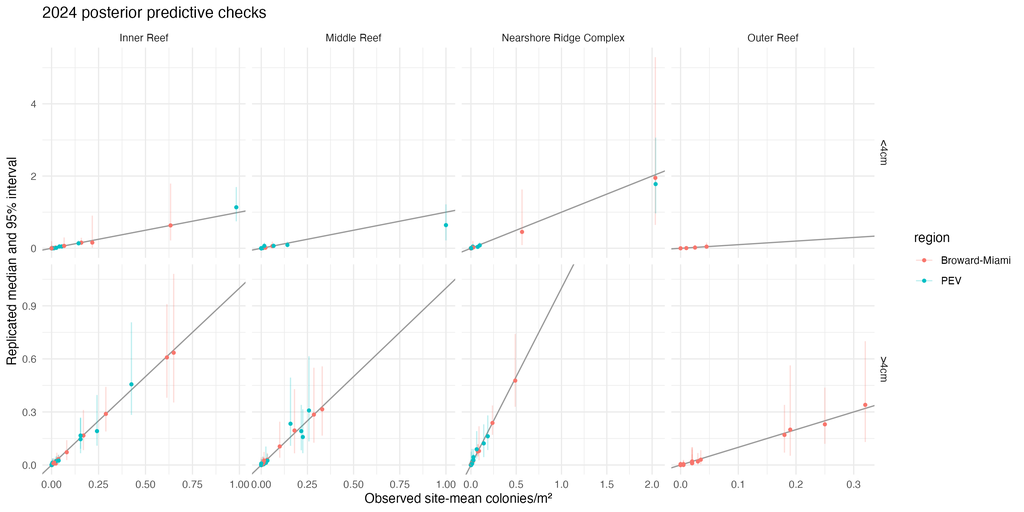

```r
knitr::include_graphics(output_file("posterior_predictive_density.png"))
```

**This fit does not pass every sampling criterion. The current posterior is the short pilot; manuscript figures and tables below remain provisional.**

Posterior saved at: `/Users/rosscunning/Projects/PENIP/outputs/coral_joint_analysis/models/7e2169d606b6259fd362df86804b7731/posterior.rds`. Rerunning matching inputs reuses it.

## 6.9 Final PEV density estimates

```r
# Equal weighting datasets

# Create newdata for prediction — dataset level only (site & dir not needed)
newdata <- dfftaxon %>%
  distinct(dataset, taxon, class, Type) %>%
  mutate(transect_area_m2 = 1)

# Get predictions from the model
# - Dataset RE included
# - Direction effects set to zero on the log scale
preds <- joint_epred_draws(newdata = newdata, region = "PEV")

# Equal-weight datasets so no dataset dominates
draws_equal_weighted <- preds %>%
  group_by(.draw, taxon, class, Type) %>%
  summarize(n_m2 = mean(.epred), .groups = "drop")

# Summarize posterior draws
summary_equal_weighted_new <- draws_equal_weighted %>%
  group_by(taxon, class, Type) %>%
  mean_qi(n_m2, .width = 0.95)


draws_equal_weighted_combined <- preds %>%
  group_by(.draw, taxon, dataset, Type, class) %>%
  summarize(n_m2 = mean(.epred), .groups = "drop") %>%

  # Average across datasets for each class
  group_by(.draw, taxon, class, Type) %>%
  summarize(n_m2 = mean(n_m2), .groups = "drop") %>%

  # Compute "All" after averaging across datasets
  group_by(.draw, taxon, Type) %>%
  mutate(total_n_m2 = sum(n_m2[class != "All"])) %>%
  ungroup() %>%
  pivot_longer(
    cols = c("n_m2", "total_n_m2"),
    names_to = "class_source",
    values_to = "n_m2"
  ) %>%
  mutate(class = ifelse(class_source == "total_n_m2", "All", class)) %>%
  select(-class_source) %>%

  # Remove redundant "All" for single-class taxa
  group_by(taxon) %>%
  mutate(n_classes = n_distinct(class[class != "All"])) %>%
  ungroup() %>%
  filter(class != "All" | n_classes > 1) %>%
  select(-n_classes)



summary_equal_weighted_combined <- draws_equal_weighted_combined %>%
  group_by(taxon, class, Type) %>%
  mean_qi(n_m2, .width = 0.95)


# Set taxon order for plotting
# Order taxa by overall abundance for plotting
taxorder <- summary_equal_weighted_combined %>%
  group_by(taxon) %>%
  mutate(
    n_classes = n_distinct(class[class != "All"])
  ) %>%
  ungroup() %>%
  filter((n_classes > 1 & class == "All") | (n_classes == 1 & class != "All")) %>%
  group_by(taxon) %>%
  summarize(maxdens = max(n_m2), .groups = "drop") %>%
  mutate(taxon = fct_reorder(taxon, -maxdens))

summary_equal_weighted_combined <- summary_equal_weighted_combined %>%
  mutate(taxon = factor(taxon, levels = levels(taxorder$taxon)),
         class = factor(class, levels = c("<4cm", "All", ">4cm")))
```

#### 6.9.0.1 2024-specific estimates

```r
newdata_drm24 <- dfftaxon %>%
  distinct(taxon, class, Type) %>%
  mutate(transect_area_m2 = 1)  %>%
  complete(Type = unique(dfftaxon$Type),  # add all habitat Types
           fill = list(transect_area_m2 = 1)) %>%
  mutate(dataset = "drm24")

preds_drm24 <- joint_epred_draws(newdata = newdata_drm24, region = "PEV")

summary_drm24 <- preds_drm24 %>%
  group_by(taxon, class, Type) %>%
  mean_qi(.epred, .width = 0.95) %>%
  rename(n_m2 = .epred)

draws_drm24_combined <- preds_drm24 %>%
  group_by(.draw, taxon, class, Type) %>%
  summarize(n_m2 = mean(.epred), .groups = "drop") %>%

  # Compute "All" class
  group_by(.draw, taxon, Type) %>%
  mutate(total_n_m2 = sum(n_m2[class != "All"])) %>%
  ungroup() %>%
  pivot_longer(
    cols = c("n_m2", "total_n_m2"),
    names_to = "class_source",
    values_to = "n_m2"
  ) %>%
  mutate(class = ifelse(class_source == "total_n_m2", "All", class)) %>%
  select(-class_source) %>%

  # Remove redundant "All" for single-class taxa
  group_by(taxon) %>%
  mutate(n_classes = n_distinct(class[class != "All"])) %>%
  ungroup() %>%
  filter(class != "All" | n_classes > 1) %>%
  select(-n_classes)

summary_drm24_combined <- draws_drm24_combined %>%
  group_by(taxon, class, Type) %>%
  mean_qi(n_m2, .width = 0.95)


summary_drm24_combined <- summary_drm24_combined %>%
  mutate(taxon = factor(taxon, levels = levels(taxorder$taxon)),
         class = factor(class, levels = c("<4cm", "All", ">4cm")))
```

# 7 Results

## 7.1 Densities

### 7.1.1 Taxon densities

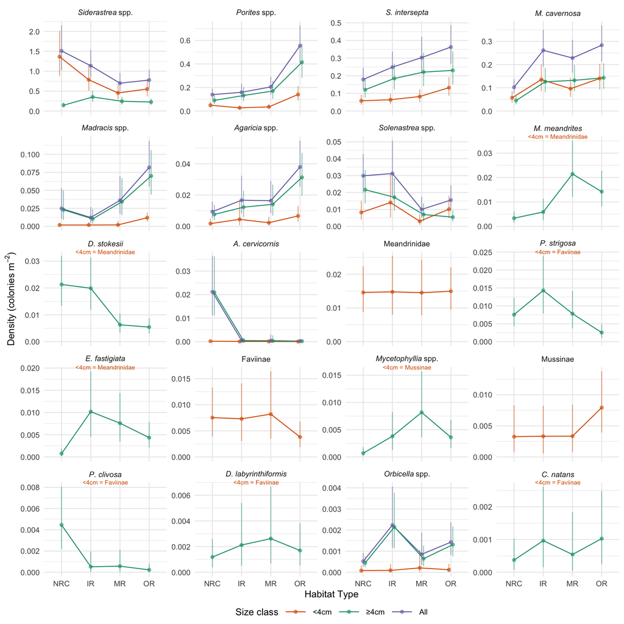

```r
##### Function to plot densities of all taxon:class:habitat combinations with provided data frame

make_taxon_density_plot <- function(densities, output_path, width, height) {

  # Create base plot
  taxdens <- ggplot(densities, aes(x = Type, y = n_m2, color = class)) +
    geom_errorbar(aes(ymin = .lower, ymax = .upper), width = 0, linewidth = 0.4,
                  position = position_dodge(width = 0.2), alpha = 0.6) +
    geom_line(aes(group = class), position = position_dodge(width = 0.2)) +
    geom_point(size = 1.5, alpha = 0.6, position = position_dodge(width = 0.2)) +
    facet_wrap(~taxon, labeller = labeller(taxon = as_labeller(taxon_labels, label_parsed)),
               scales = "free_y", ncol = 4) +
    scale_x_discrete(labels = type_labels) +
    scale_color_manual(
      values = c("<4cm" = "#d95f02", ">4cm" = "#1b9e77", "All" = "#7570b3"),
      labels = c("<4cm", "≥4cm", "All"),
      breaks = c("<4cm", ">4cm", "All")
    ) +
    labs(
      x = "Habitat Type",
      y = bquote("Density (colonies m"^-2*")"),
      color = "Size class"
    ) +
    theme_minimal()

  # Generate taxon group annotations
  taxon_group_df <- bind_rows(lapply(names(taxon_groups_juv), function(group) {
    tibble(taxon = taxon_groups_juv[[group]], group = group)
  })) %>%
    filter(taxon != group)

  annotation_df <- densities %>%
    distinct(taxon) %>%
    left_join(taxon_group_df, by = "taxon") %>%
    filter(!is.na(group)) %>%
    mutate(
      group2 = case_when(
        group == "FAVI" ~ "Faviinae",
        group == "MUSS" ~ "Mussinae",
        group == "MEAN" ~ "Meandrinidae",
        TRUE ~ group
      ),
      taxon = factor(taxon, levels = taxorder$taxon),
      label = paste0("<4cm = ", group2),
      x = 2.5,
      y = Inf
    )

  # Final figure with annotations
  fig <- taxdens +
    geom_text(data = annotation_df, aes(x = x, y = y, label = label),
              inherit.aes = FALSE, hjust = 0.5, size = 2.5, color = "#d95f02") +
    theme(
      panel.background = element_rect(fill = "white", color = NA),
      plot.background = element_rect(fill = "white", color = NA),
      legend.position = "bottom",
      legend.key.width = unit(2, "lines"),
      legend.margin = margin(t = -5, b = 0)
    ) +
    coord_cartesian(clip = "off") +
    scale_y_continuous(limits = c(0, NA))

  # Save and return the plot
  save_figure(filename = output_path, plot = fig,
         width = width, height = height,
         units = "mm", dpi = 300)
  return(fig)
}


# Create plot for dataset-averaged densities
make_taxon_density_plot(densities = summary_equal_weighted_combined,
                        output_path = output_file("Fig2.png"),
                        width = 170, height = 170)
```

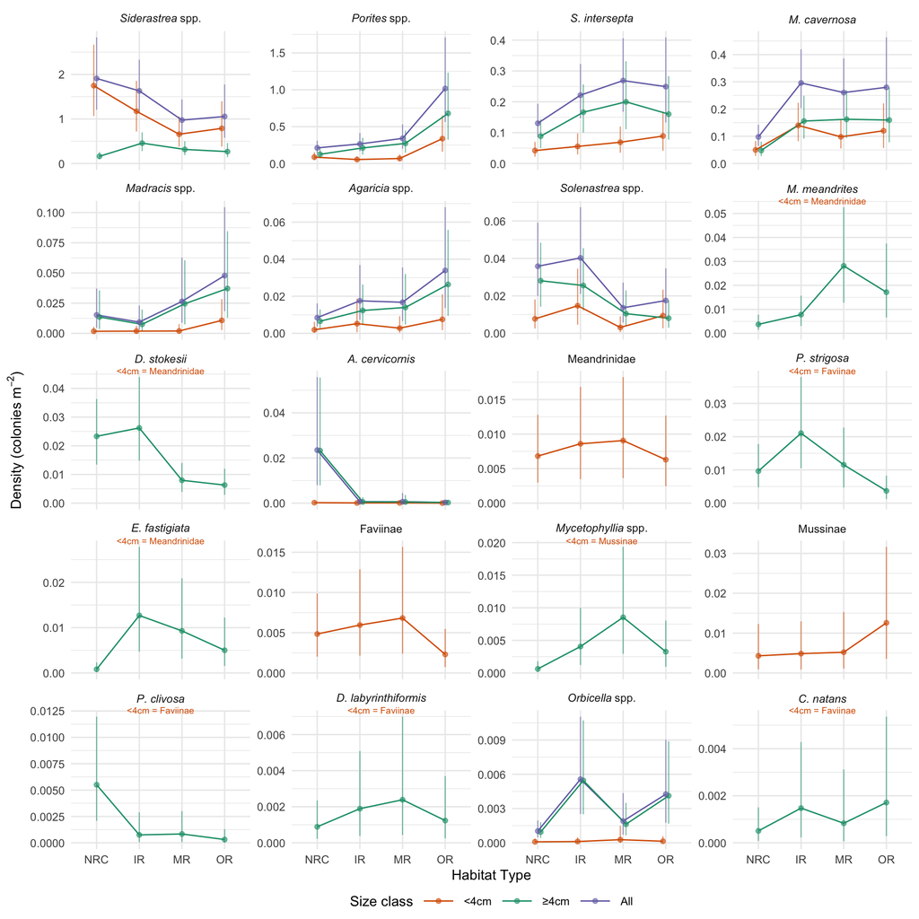

```r
# Create plot for current/2024 densities
make_taxon_density_plot(densities = summary_drm24_combined,
                        output_path = output_file("FigA2.png"),
                        width = 170, height = 170)
```

```r
#### TABLE version

make_taxon_density_table <- function(densities, output_path) {

  # Set display order
  type_order <- unique(densities$Type)  # preserves appearance order
  class_order <- c("<4cm", ">4cm", "All")
  taxon_levels <- taxorder$taxon  # assumed available

  # Format and reshape
  table_out <- densities %>%
    mutate(
      taxon = factor(taxon, levels = taxon_levels),
      class = factor(class, levels = class_order),
      Type = factor(Type, levels = type_order),
      mean_ci = sprintf(
        "%s [%s–%s]",  # en-dash
        formatC(n_m2, format = "fg", digits = 2, flag = "#"),
        formatC(.lower, format = "fg", digits = 2, flag = "#"),
        formatC(.upper, format = "fg", digits = 2, flag = "#")
      )
    ) %>%
    select(taxon, class, Type, mean_ci) %>%
    pivot_wider(names_from = Type, values_from = mean_ci) %>%
    arrange(taxon, class)

  # Save to CSV
  write_csv(table_out, file = output_path)

  return(table_out)
}

# Create table for dataset-averaged densities
make_taxon_density_table(densities = summary_equal_weighted_combined,
                         output_path = output_file("TableA2.csv"))
```

```
## # A tibble: 38 × 6
##    taxon class `Nearshore Ridge Complex` `Inner Reef` `Middle Reef` `Outer Reef`
##    <fct> <fct> <chr>                     <chr>        <chr>         <chr>
##  1 ACER  <4cm  0.00020 [0.000059–0.0005… 0.000074 [0… 0.000074 [0.… 0.000033 [0…
##  2 ACER  >4cm  0.021 [0.011–0.036]       0.00040 [0.… 0.00033 [0.0… 0.00020 [0.…
##  3 ACER  All   0.021 [0.011–0.036]       0.00048 [0.… 0.00041 [0.0… 0.00023 [0.…
##  4 AGAR  <4cm  0.0018 [0.00044–0.0049]   0.0045 [0.0… 0.0023 [0.00… 0.0067 [0.0…
##  5 AGAR  >4cm  0.0076 [0.0039–0.014]     0.012 [0.00… 0.014 [0.006… 0.031 [0.02…
##  6 AGAR  All   0.0094 [0.0053–0.016]     0.017 [0.00… 0.016 [0.008… 0.038 [0.02…
##  7 CNAT  >4cm  0.00037 [0.000073–0.0010] 0.00097 [0.… 0.00054 [0.0… 0.0010 [0.0…
##  8 DLAB  >4cm  0.0012 [0.00038–0.0026]   0.0021 [0.0… 0.0026 [0.00… 0.0017 [0.0…
##  9 DSTO  >4cm  0.021 [0.013–0.032]       0.020 [0.01… 0.0063 [0.00… 0.0054 [0.0…
## 10 EFAS  >4cm  0.00075 [0.00017–0.0019]  0.010 [0.00… 0.0076 [0.00… 0.0043 [0.0…
## # ℹ 28 more rows
```

```r
# Create table for current/2024 densities
make_taxon_density_table(densities = summary_drm24_combined,
                         output_path = output_file("TableA3.csv"))
```

```
## # A tibble: 38 × 6
##    taxon class `Nearshore Ridge Complex` `Inner Reef` `Middle Reef` `Outer Reef`
##    <fct> <fct> <chr>                     <chr>        <chr>         <chr>
##  1 ACER  <4cm  0.00023 [0.000037–0.0007… 0.00010 [0.… 0.00012 [0.0… 0.000042 [0…
##  2 ACER  >4cm  0.023 [0.0078–0.056]      0.00057 [0.… 0.00052 [0.0… 0.00027 [0.…
##  3 ACER  All   0.024 [0.0080–0.056]      0.00068 [0.… 0.00064 [0.0… 0.00031 [0.…
##  4 AGAR  <4cm  0.0019 [0.00035–0.0062]   0.0052 [0.0… 0.0028 [0.00… 0.0075 [0.0…
##  5 AGAR  >4cm  0.0065 [0.0026–0.013]     0.012 [0.00… 0.014 [0.004… 0.026 [0.00…
##  6 AGAR  All   0.0084 [0.0037–0.016]     0.018 [0.00… 0.017 [0.006… 0.034 [0.01…
##  7 CNAT  >4cm  0.00051 [0.000082–0.0015] 0.0015 [0.0… 0.00083 [0.0… 0.0017 [0.0…
##  8 DLAB  >4cm  0.00089 [0.00022–0.0023]  0.0019 [0.0… 0.0024 [0.00… 0.0012 [0.0…
##  9 DSTO  >4cm  0.023 [0.013–0.036]       0.026 [0.01… 0.0080 [0.00… 0.0063 [0.0…
## 10 EFAS  >4cm  0.00082 [0.00016–0.0023]  0.013 [0.00… 0.0093 [0.00… 0.0050 [0.0…
## # ℹ 28 more rows
```

### 7.1.2 Raw vs. modeled taxon densities

```r
# Average density per dataset-taxon-class-Type group
raw_density_summary <- pev_raw_counts %>%
  mutate(density = n / transect_area_m2) %>%
  group_by(dataset, taxon, class, Type) %>%
  summarize(
    raw_density_mean = mean(density, na.rm = TRUE),
    raw_density_sd   = sd(density, na.rm = TRUE),
    raw_density_n    = n(),
    .groups = "drop"
  ) %>%
  mutate(
    raw_density_se = raw_density_sd / sqrt(raw_density_n),
    t_crit = qt(0.975, df = raw_density_n - 1),
    raw_density_lower = pmax(0, raw_density_mean - t_crit * raw_density_se),
    raw_density_upper = raw_density_mean + t_crit * raw_density_se
  )

all <- raw_density_summary %>% left_join(summary_equal_weighted_combined) %>%
  mutate(taxon_class = paste(taxon, class))

all_long <- all %>%
  select(dataset, taxon, class, Type, raw_density_mean, raw_density_lower, raw_density_upper,
         n_m2, .lower, .upper, taxon_class) %>%
  pivot_longer(
    cols = c(raw_density_mean, n_m2),
    names_to = "source",
    values_to = "density"
  ) %>%
  mutate(
    lower = ifelse(source == "raw_density_mean", raw_density_lower, .lower),
    upper = ifelse(source == "raw_density_mean", raw_density_upper, .upper),
    source = ifelse(source == "raw_density_mean", dataset, "modeled")
  )

raw_vs_mod <- ggplot(all_long, aes(x = Type, y = density)) +
  geom_point(
    aes(shape = source, color = source),
    size = 2,
    position = position_dodge(width = 0.75),
    alpha = 0.5
  ) +
  geom_errorbar(
    aes(ymin = lower, ymax = upper, color = source),
    position = position_dodge(width = 0.75),
    width = 0,
    alpha = 0.5
  ) +
  facet_wrap(~ taxon_class, scales = "free", ncol = 5) +
  scale_y_continuous(limits = c(0, NA), expand = expansion(mult = c(0, 0))) +
  coord_cartesian(clip = "off") +
  scale_x_discrete(labels = c("NRC", "IR", "MR", "OR")) +
  scale_color_manual(
    name = "",
    values = c(
      "nsu11_esa" = "#1b9e77",
      "dca17_esa" = "#d95f02",
      "dca17"     = "#7570b3",
      "tt21"      = "#e7298a",
      "tt23"      = "#66a61e",
      "drm24"     = "#e6ab02",
      "modeled"   = "black"
    ),
    breaks = c("nsu11_esa", "dca17_esa", "dca17", "tt21", "tt23", "drm24", "modeled"),
    labels = c(
      "nsu11_esa" = "2011 – NSU ESA Survey",
      "dca17_esa" = "2017 – DCA ESA Survey",
      "dca17"     = "2017 – DCA Recon Survey",
      "tt21"      = "2021 – Tetra Tech Survey",
      "tt23"      = "2023 – Tetra Tech Survey",
      "drm24"     = "2024 – Shedd Survey",
      "modeled"   = "Modeled density"
    )
  ) +
  scale_shape_manual(
    name = "",
    values = c(
      "nsu11_esa" = 15,
      "dca17_esa" = 16,
      "dca17"     = 17,
      "tt21"      = 18,
      "tt23"      = 3,
      "drm24"     = 4,
      "modeled"   = 5
    ),
    breaks = c("nsu11_esa", "dca17_esa", "dca17", "tt21", "tt23", "drm24", "modeled"),
    labels = c(
      "nsu11_esa" = "2011 – NSU ESA Survey",
      "dca17_esa" = "2017 – DCA ESA Survey",
      "dca17"     = "2017 – DCA Recon Survey",
      "tt21"      = "2021 – Tetra Tech Survey",
      "tt23"      = "2023 – Tetra Tech Survey",
      "drm24"     = "2024 – Shedd Survey",
      "modeled"   = "Modeled density"
    )
  ) +
  guides(
    color = guide_legend(order = 1),
    shape = guide_legend(order = 1)
  )


figA1 <- raw_vs_mod + theme_minimal() +
  theme_minimal() +
  theme(
    legend.position = "bottom",
    panel.background = element_rect(fill = "white", color = NA),
    plot.background = element_rect(fill = "white", color = NA),
    panel.grid = element_blank(),
    panel.border = element_rect(color = "black", fill = NA, linewidth = 0.2),
    axis.ticks = element_line(color = "black", linewidth = 0.2),
    axis.ticks.length = unit(2, "pt"),
    axis.line = element_blank() # keep ticks but don't draw duplicate axis lines
  )

save_figure(filename = output_file("FigA1.png"), width = 190, height = 250, units = "mm")
```

### 7.1.3 Total densities by size and SCTLD-susceptibility

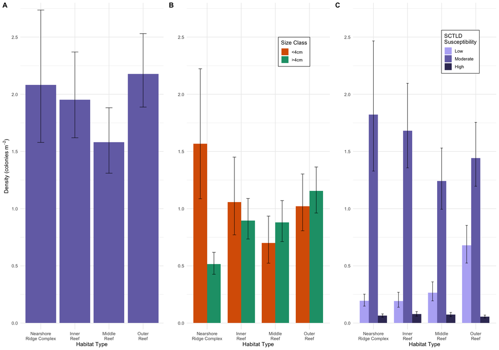

```r
make_combined_density_figure <- function(draws, table = FALSE,
                                         output_path,
                                         y_limits = c(0, 2.8)) {
  draws <- draws %>% filter(class != "All")
  type_order <- unique(draws$Type)
  y_breaks <- seq(y_limits[1], y_limits[2] - 0.3, 0.5)
  y_minor_breaks <- seq(y_limits[1], y_limits[2] - 0.05, 0.25)

  # -- Total density summary --
  summary_total <- draws %>%
    group_by(.draw, Type) %>%
    summarize(total_density = sum(n_m2), .groups = "drop") %>%
    group_by(Type) %>%
    summarize(
      mean = mean(total_density),
      lower = quantile(total_density, 0.025),
      upper = quantile(total_density, 0.975),
      .groups = "drop"
    )

  plot_total <- ggplot(summary_total, aes(x = Type, y = mean)) +
    geom_col(fill = "#7570b3") +
    geom_errorbar(aes(ymin = lower, ymax = upper), width = 0.2, linewidth = 0.25) +
    scale_x_discrete(labels = type_labels2) +
    scale_y_continuous(
      limits = y_limits,
      breaks = y_breaks,
      minor_breaks = y_minor_breaks,
      expand = expansion(mult = c(0.02, 0))
    ) +
    labs(
      x = "Habitat Type",
      y = bquote("Density (colonies m"^-2*")")
    ) +
    theme_minimal(base_size = 8) +
    theme(
      axis.text.x = element_text(angle = 0, hjust = 0.5),
      panel.background = element_rect(fill = "white", color = NA),
      plot.background = element_rect(fill = "white", color = NA)
    )

  # -- Size class summary --
  summary_class <- draws %>%
    group_by(.draw, Type, class) %>%
    summarize(total_epred = sum(n_m2), .groups = "drop") %>%
    group_by(Type, class) %>%
    mean_qi(total_epred, .width = 0.95) %>%
    mutate(
      class = factor(class, levels = c("<4cm", ">4cm")),
      label = sprintf("%.2f", total_epred)
    )

  plot_class <- ggplot(summary_class, aes(x = Type, y = total_epred, fill = class)) +
    geom_col(position = position_dodge(width = 0.8), width = 0.8) +
    geom_errorbar(aes(ymin = .lower, ymax = .upper),
                  position = position_dodge(width = 0.8), width = 0.2, linewidth = 0.25) +
    scale_fill_manual(values = c(">4cm" = "#1b9e77", "<4cm" = "#d95f02")) +
    scale_x_discrete(labels = type_labels2) +
    scale_y_continuous(
      limits = y_limits,
      breaks = y_breaks,
      minor_breaks = y_minor_breaks,
      expand = expansion(mult = c(0.02, 0))
    ) +
    labs(
      x = "Habitat Type",
      y = "",
      fill = "Size Class"
    ) +
    theme_minimal(base_size = 8) +
    theme(
      axis.text.x = element_text(angle = 0, hjust = 0.5),
      legend.key.size = unit(4, "mm"),
      legend.background = element_rect(fill = "white", color = "black", linewidth = 0.25),
      legend.position = c(0.75, 0.85),
      panel.background = element_rect(fill = "white", color = NA),
      plot.background = element_rect(fill = "white", color = NA)
    )

  # -- SCTLD susceptibility summary --
  summary_sus <- draws %>%
    left_join(group_definitions, by = "taxon") %>%
    group_by(.draw, Type, sus_group) %>%
    summarize(total_epred = sum(n_m2), .groups = "drop") %>%
    group_by(Type, sus_group) %>%
    mean_qi(total_epred, .width = 0.95) %>%
    mutate(
      taxon_group = factor(sus_group, levels = c("high_sus", "mod_sus", "low_sus")),
      label = sprintf("%.2f", total_epred)
    )

  plot_sus <- ggplot(summary_sus, aes(x = Type, y = total_epred, fill = sus_group)) +
    geom_col(position = position_dodge(width = 0.8), width = 0.8) +
    geom_errorbar(aes(ymin = .lower, ymax = .upper),
                  position = position_dodge(width = 0.8), width = 0.2, linewidth = 0.25) +
    scale_fill_manual(
      values = c(
        "high_sus" = darken("#7570b3", 0.5),
        "mod_sus"  = "#7570b3",
        "low_sus"  = lighten("#7570b3", 0.5)
      ),
      labels = c(
        "high_sus" = "High",
        "mod_sus"  = "Moderate",
        "low_sus"  = "Low"
      )
    ) +
    scale_x_discrete(labels = type_labels2) +
    scale_y_continuous(
      limits = y_limits,
      breaks = y_breaks,
      minor_breaks = y_minor_breaks,
      expand = expansion(mult = c(0.02, 0))
    ) +
    labs(
      x = "Habitat Type",
      y = "",
      fill = "SCTLD\nSusceptibility"
    ) +
    theme_minimal(base_size = 8) +
    theme(
      axis.text.x = element_text(angle = 0, hjust = 0.5),
      legend.key.size = unit(4, "mm"),
      legend.background = element_rect(fill = "white", color = "black", linewidth = 0.25),
      legend.position = c(0.75, 0.85),
      panel.background = element_rect(fill = "white", color = NA),
      plot.background = element_rect(fill = "white", color = NA)
    )

  # -- Combine all panels --
  combined_plot <- cowplot::plot_grid(
    plot_total, plot_class, plot_sus,
    ncol = 3,
    labels = c("A", "B", "C"),
    label_size = 10,
    align = "hv"
  )

  if (table == FALSE) {
    save_figure(filename = output_path, plot = combined_plot, width = 180, height = 80, units = "mm", dpi = 300)
    return(combined_plot)
  } else {
    return(list(summary_sus, summary_class, summary_total))
  }
}

make_combined_density_figure(draws = draws_equal_weighted,
                             output_path = output_file("Fig3.png"))
```

```r
make_combined_density_figure(draws = draws_equal_weighted, table = TRUE)
```

```
## [[1]]
## # A tibble: 12 × 10
##    Type  sus_group total_epred .lower .upper .width .point .interval taxon_group
##    <fct> <fct>           <dbl>  <dbl>  <dbl>  <dbl> <chr>  <chr>     <fct>
##  1 Near… low_sus        0.195  0.148  0.253    0.95 mean   qi        low_sus
##  2 Near… mod_sus        1.82   1.33   2.47     0.95 mean   qi        mod_sus
##  3 Near… high_sus       0.0643 0.0515 0.0799   0.95 mean   qi        high_sus
##  4 Inne… low_sus        0.192  0.138  0.269    0.95 mean   qi        low_sus
##  5 Inne… mod_sus        1.68   1.36   2.10     0.95 mean   qi        mod_sus
##  6 Inne… high_sus       0.0793 0.0607 0.100    0.95 mean   qi        high_sus
##  7 Midd… low_sus        0.266  0.194  0.360    0.95 mean   qi        low_sus
##  8 Midd… mod_sus        1.24   0.995  1.53     0.95 mean   qi        mod_sus
##  9 Midd… high_sus       0.0730 0.0560 0.0923   0.95 mean   qi        high_sus
## 10 Oute… low_sus        0.679  0.525  0.854    0.95 mean   qi        low_sus
## 11 Oute… mod_sus        1.44   1.20   1.75     0.95 mean   qi        mod_sus
## 12 Oute… high_sus       0.0561 0.0443 0.0698   0.95 mean   qi        high_sus
## # ℹ 1 more variable: label <chr>
##
## [[2]]
## # A tibble: 8 × 9
##   Type             class total_epred .lower .upper .width .point .interval label
##   <fct>            <fct>       <dbl>  <dbl>  <dbl>  <dbl> <chr>  <chr>     <chr>
## 1 Nearshore Ridge… <4cm        1.57   1.09   2.22    0.95 mean   qi        1.57
## 2 Nearshore Ridge… >4cm        0.515  0.426  0.618   0.95 mean   qi        0.51
## 3 Inner Reef       <4cm        1.06   0.771  1.45    0.95 mean   qi        1.06
## 4 Inner Reef       >4cm        0.895  0.735  1.09    0.95 mean   qi        0.90
## 5 Middle Reef      <4cm        0.701  0.523  0.935   0.95 mean   qi        0.70
## 6 Middle Reef      >4cm        0.879  0.712  1.07    0.95 mean   qi        0.88
## 7 Outer Reef       <4cm        1.02   0.806  1.30    0.95 mean   qi        1.02
## 8 Outer Reef       >4cm        1.16   0.962  1.36    0.95 mean   qi        1.16
##
## [[3]]
## # A tibble: 4 × 4
##   Type                     mean lower upper
##   <fct>                   <dbl> <dbl> <dbl>
## 1 Nearshore Ridge Complex  2.08  1.58  2.74
## 2 Inner Reef               1.95  1.62  2.37
## 3 Middle Reef              1.58  1.31  1.88
## 4 Outer Reef               2.18  1.89  2.53
```

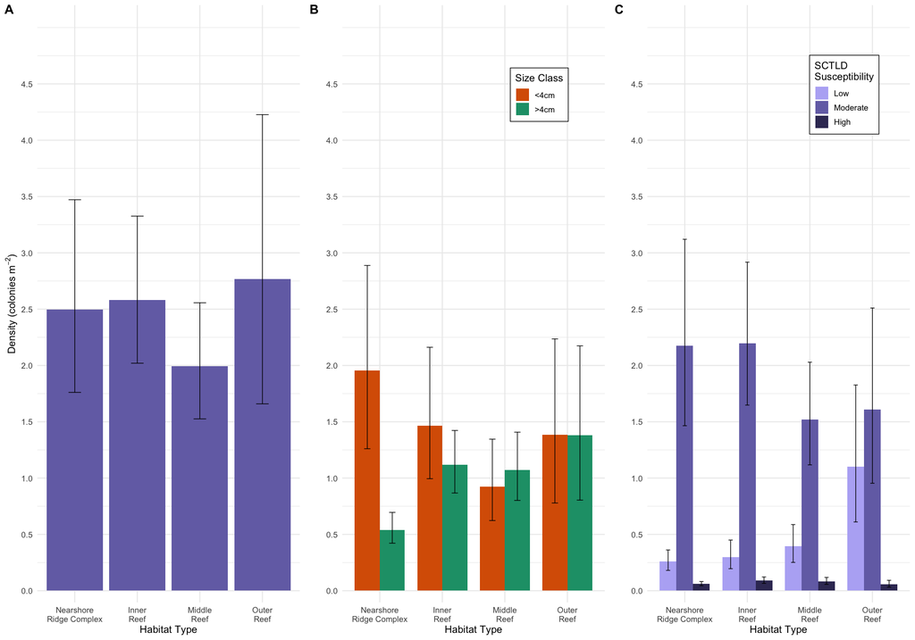

```r
make_combined_density_figure(draws = draws_drm24_combined,
                             y_limits = c(0, 5.2),
                             output_path = output_file("FigA3.png"))
```

```r
# Size class overall averages
post_summ <- draws_equal_weighted %>%
  group_by(.draw, Type, class) %>%
  summarise(total_epred = sum(n_m2), .groups = "drop") %>%
  group_by(.draw, class) %>%
  summarise(avg_total_epred = mean(total_epred), .groups = "drop") %>%
  group_by(class) %>%
  summarise(
    mean = mean(avg_total_epred),
    sd_post = sd(avg_total_epred),          # posterior SD of the mean
    # optional: 95% CrI if you still want it for comparison
    lower = quantile(avg_total_epred, 0.025),
    upper = quantile(avg_total_epred, 0.975),
    n_draws = dplyr::n()
  )
post_summ
```

```
## # A tibble: 2 × 6
##   class  mean sd_post lower upper n_draws
##   <chr> <dbl>   <dbl> <dbl> <dbl>   <int>
## 1 <4cm  1.09   0.0989 0.913 1.29     2000
## 2 >4cm  0.861  0.0454 0.779 0.954    2000
```

## 7.2 Temporal trends

```r
# Prediction grid
newdata <- dfftaxon %>%
  distinct(dataset, Type, taxon, class) %>%
  mutate(transect_area_m2 = 1) %>%
  #### Add missing habitat Type (Outer Reef) for drm24 dataset (will be imputed)
  group_by(dataset, taxon, class) %>%
  complete(Type = unique(dfftaxon$Type),  # add all habitat Types
           fill = list(transect_area_m2 = 1)) %>%
  ungroup()

# Predictions (same as before)
preds <- joint_epred_draws(newdata = newdata, region = "PEV", ndraws = 2000)

# Average across habitat types per draw
preds_avg <- preds %>%
  group_by(.draw, dataset, taxon, class) %>%
  summarize(mean_epred = mean(.epred), .groups = "drop") %>%
  mutate(year = parse_number(as.character(dataset)))

# Helper function for slopes + modeled changes
compute_trends <- function(data, group_vars, value_col) {
  data %>%
    filter(year >= 17) %>%
    group_by(across(all_of(group_vars)), .draw) %>%
    summarise(
      fit = list(lm(reformulate("year", value_col))),
      .groups = "drop"
    ) %>%
    mutate(
      intercept  = map_dbl(fit, ~ coef(.x)[1]),
      slope      = map_dbl(fit, ~ coef(.x)[2]),
      pred_17    = intercept + slope * 17,
      pred_24    = intercept + slope * 24,
      abs_change = pred_24 - pred_17,
      pct_change = ifelse(pred_17 > 0, (pred_24 - pred_17) / pred_17 * 100, NA_real_)
    ) %>%
    select(-fit)
}

# Taxon × class
trends_taxon_class <- compute_trends(preds_avg, c("taxon", "class"), "mean_epred")

trends_taxon_class_preds <- trends_taxon_class %>%
  crossing(year = 17:24) %>%                     # add year range
  mutate(pred_density = intercept + slope * year) %>%
  group_by(taxon, class, year) %>%
  mean_qi(pred_density, .width = 0.95)

# Taxon totals
trends_taxon <- preds_avg %>%
  group_by(taxon) %>%
  filter(n_distinct(class) > 1) %>%   # keep only taxa with multiple size classes
  ungroup() %>%
  group_by(.draw, dataset, taxon, year) %>%
  summarise(total_epred = sum(mean_epred), .groups = "drop") %>%
  compute_trends(c("taxon"), "total_epred") %>%
  mutate(class = "All")

trends_taxon_preds <- trends_taxon %>%
  crossing(year = 17:24) %>%                     # add year range
  mutate(pred_density = intercept + slope * year) %>%
  group_by(taxon, year) %>%
  mean_qi(pred_density, .width = 0.95) %>%
  mutate(class = "All")

# All corals (overall)
trends_all_totals <- preds_avg %>%
  # Totals cannot be derived from the ESA-only surveys
  filter(dataset %in% c("dca17", "tt21", "tt23", "drm24")) %>%
  group_by(.draw, dataset, year) %>%
  summarise(total_epred = sum(mean_epred), .groups = "drop") %>%
  compute_trends(character(0), "total_epred") %>%
  mutate(taxon = "All", class = "All")

# All corals by size class
trends_all_by_class <- preds_avg %>%
  # Totals cannot be derived from the ESA-only surveys
  filter(dataset %in% c("dca17", "tt21", "tt23", "drm24")) %>%
  group_by(.draw, dataset, year, class) %>%
  summarise(total_epred = sum(mean_epred), .groups = "drop") %>%
  compute_trends("class", "total_epred") %>%
  mutate(taxon = "All")

# Combine
trends_all <- bind_rows(trends_all_totals, trends_all_by_class)

trends_all_preds <- trends_all %>%
  crossing(year = 17:24) %>%                     # add year range
  mutate(pred_density = intercept + slope * year) %>%
  group_by(class, year) %>%
  mean_qi(pred_density, .width = 0.95) %>%
  mutate(taxon = "All")

# Combine results
trends_combined <- bind_rows(
  trends_taxon_class %>% mutate(level = "taxon_class"),
  trends_taxon %>% mutate(level = "taxon"),
  trends_all %>% mutate(level = "all")
)

preds_combined <- bind_rows(
  trends_taxon_class_preds %>% mutate(level = "taxon_class"),
  trends_taxon_preds %>% mutate(level = "taxon"),
  trends_all_preds %>% mutate(level = "all")
)

# Summarize posterior distributions
trends_summary <- trends_combined %>%
  group_by(level, taxon, class) %>%
  mean_qi(slope, abs_change, pct_change, .width = 0.95, na.rm = TRUE) %>%
  as_tibble()

# Derive the previously interactive ordering object explicitly.
trends_summary_subset <- trends_summary %>%
  group_by(taxon) %>%
  filter(if (any(class == "All")) class == "All" else TRUE) %>%
  ungroup() %>% mutate(taxon = fct_reorder(taxon, -abs(abs_change)))

# Identify temporal changes whose pointwise interval excludes zero
preds_combined <- preds_combined %>%
  left_join(
    trends_summary %>%
      mutate(sig_trend = sign(slope.lower) == sign(slope.upper)) %>%
      select(taxon, class, sig_trend),
    by = c("taxon", "class")
  )

preds_combined <- preds_combined %>%
  mutate(taxon = factor(taxon, levels = levels(trends_summary_subset$taxon)))

trends_summary <- trends_summary %>%
  mutate(taxon = factor(taxon, levels = levels(trends_summary_subset$taxon)))


# Taxon × class summary
summary_taxon_class <- preds_avg %>%
  group_by(dataset, taxon, class) %>%
  mean_qi(mean_epred, .width = 0.95) %>%
  mutate(level = "taxon_class")

# Taxon totals (sum over classes)
summary_taxon <- preds_avg %>%
  group_by(taxon) %>%
  filter(n_distinct(class) > 1) %>%   # keep only taxa with multiple size classes
  ungroup() %>%
  group_by(.draw, dataset, taxon) %>%
  summarise(mean_epred = sum(mean_epred), .groups = "drop") %>%
  group_by(dataset, taxon) %>%
  mean_qi(mean_epred, .width = 0.95) %>%
  mutate(class = "All", level = "taxon")

# All corals combined (sum over taxa and classes)
summary_all <- preds_avg %>%
  # Totals cannot be derived from the ESA-only surveys
  filter(dataset %in% c("dca17", "tt21", "tt23", "drm24")) %>%
  group_by(.draw, dataset) %>%
  summarise(mean_epred = sum(mean_epred), .groups = "drop") %>%
  group_by(dataset) %>%
  mean_qi(mean_epred, .width = 0.95) %>%
  mutate(taxon = "All", class = "All", level = "all")

# All corals combined by size class (sum over taxa)
summary_all_by_class <- preds_avg %>%
  # Totals cannot be derived from the ESA-only surveys
  filter(dataset %in% c("dca17", "tt21", "tt23", "drm24")) %>%
  group_by(.draw, dataset, class) %>%
  summarise(mean_epred = sum(mean_epred), .groups = "drop") %>%
  group_by(dataset, class) %>%
  mean_qi(mean_epred, .width = 0.95) %>%
  mutate(taxon = "All", level = "all_by_class")

# Combine all summaries
summary_datasets <- bind_rows(
  summary_taxon_class,
  summary_taxon,
  summary_all,
  summary_all_by_class
) %>%
  mutate(year = parse_number(dataset)) %>%
  mutate(taxon = factor(taxon, levels = levels(trends_summary_subset$taxon)))


trends_summary <- trends_summary %>%
  group_by(taxon) %>%
  mutate(
    y_max = max(summary_datasets$.upper[summary_datasets$taxon == unique(taxon)], na.rm = TRUE),
    n_classes = n_distinct(class),
    y_label = case_when(
      n_classes == 1 ~ y_max * 1.02,  # single class at top
      n_classes == 2 & class %in% c("All", ">4cm") ~ y_max * 1.02,  # top position for first
      n_classes == 2 & class == "<4cm" ~ y_max * 0.87,              # middle position for second
      n_classes == 3 & class == "All" ~ y_max * 1.02,
      n_classes == 3 & class == ">4cm" ~ y_max * 0.87,
      n_classes == 3 & class == "<4cm" ~ y_max * 0.72,
      TRUE ~ y_max * 1.02  # fallback
    ),
    sig_trend = sign(slope.lower) == sign(slope.upper),
    abs_change
  ) %>%
  ungroup()


# trends_summary %>% filter(taxon == "PSTR")
# trends_summary %>% filter(taxon == "MYCE")
# trends_summary %>% select(taxon, class, abs_change, pct_change) %>%
#   filter(taxon %in% c("PORI", "SIDE", "MCAV"))
# trends_summary %>% select(taxon, class, abs_change, pct_change) %>%
#   filter(taxon %in% c("SOLE", "AGAR"))
# trends_summary %>% select(taxon, class, abs_change, pct_change) %>%
#   filter(taxon %in% c("MMEA", "EFAS", "ORBI"))
# trends_summary %>% select(taxon, class, abs_change, pct_change) %>%
#   filter(taxon %in% c("FAVI", "MEAN"))
# trends_summary %>% select(taxon, class, abs_change, pct_change) %>%
#   filter(taxon %in% c("PSTR", "MYCE"))
#
```

### 7.2.1 Plot trajectories

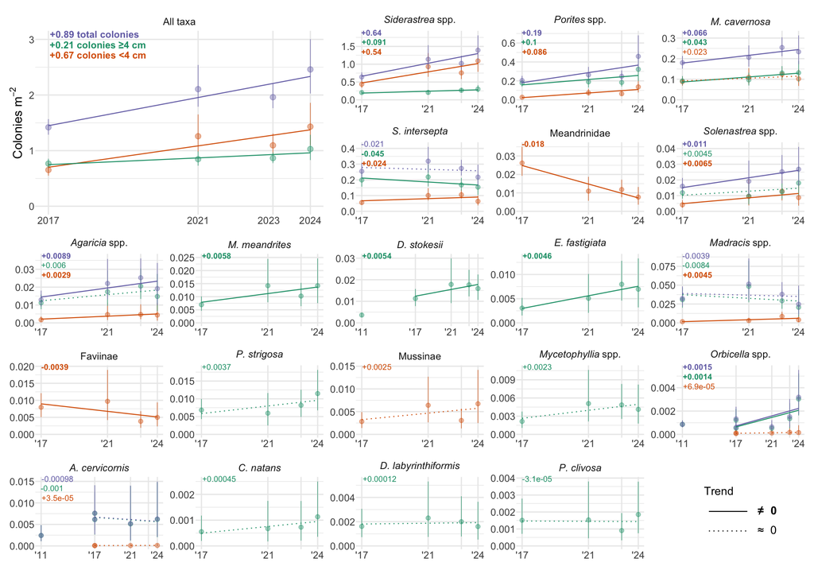

```r
# Final Figure 5 trends plot

alltax <- ggplot(summary_datasets %>% filter(taxon == "All"), aes(x = year, y = mean_epred)) +
  geom_point(aes(color = class), alpha = 0.4, size = 2) +
  geom_errorbar(aes(color = class, ymin = .lower, ymax = .upper), width = 0, linewidth = 0.2) +
  geom_line(data = preds_combined %>% filter(taxon == "All"), linewidth = 0.4,
            aes(color = class, y = pred_density, linetype = sig_trend)) +
  geom_text(data = trends_summary %>% filter(taxon == "All"),
            aes(x = -Inf, y = Inf,
                label = paste0(ifelse(abs_change > 0,
                        paste0("+", signif(abs_change, 2)),
                        as.character(signif(abs_change, 2))),
                        c(" colonies <4 cm", " colonies ≥4 cm", " total colonies   ")),
                color = class, fontface = ifelse(sig_trend, "bold", "plain")),
            inherit.aes = FALSE, size = 3, hjust = -0.15, vjust = c(4.0, 2.5, 1.0)) +
  facet_wrap(~taxon, scales = "free",
             labeller = labeller(taxon = as_labeller(taxon_labels, label_parsed))) +
  labs(y = expression("Colonies m"^-2)) +
  scale_y_continuous(limits = c(0, NA)) +
  scale_linetype_manual(values = c(`FALSE` = 3, `TRUE` = 1)) +
  scale_color_manual(values = c('#d95f02', '#1b9e77', '#7570b3')) +
  scale_x_continuous(breaks = c(11, 17, 21, 23, 24),
                     labels = c(
                       str_pad("2011", width = 4, side = "right"),
                       str_pad("2017", width = 4, side = "right"),
                       str_pad("2021", width = 4, side = "right"),
                       str_pad("2023", width = 7, side = "right"),
                       str_pad("2024", width = 4, side = "left")))+
  theme_minimal(base_size = 11) +
  theme(plot.background = element_rect(fill = "white", color = NA),
        axis.title.x = element_blank(),
        legend.position = "none",
        panel.grid.minor.x = element_blank(),
        axis.text.y = element_text(margin = margin(r = -2)),
        axis.title.y = element_text(margin = margin(r = -14)),
        axis.text.x = element_text(margin = margin(t = -1)),
        plot.margin = margin(t = 3, r = 3, b = 3, l = 3)) +
  coord_cartesian(clip = "off")

taxa_other <- levels(summary_datasets$taxon)[-1]
p_others <- map(taxa_other, function(taxon) {
  ggplot(summary_datasets %>%
           filter(taxon == !!taxon) %>%
           mutate(class = factor(class, levels = c(">4cm", "<4cm", "All"))),
         aes(x = year, y = mean_epred)) +
  geom_point(aes(color = class), alpha = 0.4) +
  geom_errorbar(aes(color = class, ymin = .lower, ymax = .upper), width = 0, linewidth = 0.2) +
  geom_line(data = preds_combined %>%
           filter(taxon == !!taxon) %>%
           mutate(class = factor(class, levels = c(">4cm", "<4cm", "All"))),
           linewidth = 0.4,
            aes(color = class, y = pred_density, linetype = sig_trend)) +
  geom_text(data = trends_summary %>%
           filter(taxon == !!taxon) %>%
           mutate(class = factor(class, levels = c(">4cm", "<4cm", "All"))),
            aes(x = -Inf, y = y_label,
               label = str_pad(
  ifelse(abs_change > 0,
         paste0("+", signif(abs_change, 2)),
         as.character(signif(abs_change, 2))),
  width = 8,
  side = "right"
),
                color = class, fontface = ifelse(sig_trend, "bold", "plain")),
            inherit.aes = FALSE, size = 2.5, hjust = -0.2, vjust = 0.2) +
  facet_wrap(~taxon, scales = "free",
              labeller = labeller(taxon = as_labeller(taxon_labels, label_parsed))) +
  scale_y_continuous(limits = c(0, NA)) +
  scale_linetype_manual(values = c("FALSE" = 3, "TRUE" = 1), drop = FALSE) +
  scale_color_manual(values = c("<4cm" = "#d95f02", ">4cm" = "#1b9e77", "All" = "#7570b3"),
                     drop = FALSE) +
  scale_x_continuous(breaks = c(11, 17, 21, 23, 24),
                     labels = c(
    str_pad("'11", width = 3, side = "left"),
    str_pad("'17", width = 3, side = "left"),
    str_pad("'21", width = 3, side = "right"), "",
    #str_pad("'23", width = 6, side = "right"),
    str_pad("'24", width = 3, side = "left")))+
  theme_minimal(base_size = 11) +
  theme(plot.background = element_rect(fill = "white", color = NA),
        axis.title.x = element_blank(),
        axis.title.y = element_blank(),
        axis.text.y = element_text(margin = margin(r = -2)),
        axis.text.x = element_text(margin = margin(t = -1)),
        legend.position = "none",
        panel.grid.minor.x = element_blank(),
        plot.margin = margin(t = 3, r = 3, b = 3, l = 3)) +
  coord_cartesian(clip = "off") +
    labs(x = "", y = "")
})


# MAKE STANDALONE LEGEND
# Dummy data for legend creation
legend_data <- data.frame(
  x = 1:2,
  y = 1:2,
  trend = factor(c("credible", "uncertain"), levels = c("credible", "uncertain"))
)

# Build dummy plot for legend
legend_plot <- ggplot(legend_data, aes(x = x, y = y, linetype = trend)) +
  geom_line(linewidth = 0.4) +
  scale_linetype_manual(
    name = "Trend",
    values = c("credible" = "solid", "uncertain" = "dotted"),
    labels = c("<b>≠ 0</b>", "≈ 0"),
  ) +
  theme_void(base_size = 10) +
  theme(
    legend.position = "right",       # vertical legend
    legend.title = element_text(size = 10),
    legend.text = element_text(size = 10),
    theme(legend.key.width = unit(3, "cm"))
  ) +
  guides(linetype = guide_legend(override.aes = list(size = 0.6),
                                 label.theme = element_markdown()),
         color = "none") +
  theme(legend.key.width = unit(1.5, "cm"))

# Extract just the legend
legend_only <- cowplot::get_legend(legend_plot)

# Show legend-only plot
legplot <- cowplot::ggdraw(legend_only)


# Define the layout
layout <- c(
  area(t = 1, l = 1, b = 2, r = 2),  # 'alltax' spans top-left 2×2
  area(t = 1, l = 3, b = 1, r = 3),  # plot 1
  area(t = 1, l = 4, b = 1, r = 4),  # plot 2
  area(t = 1, l = 5, b = 1, r = 5),  # plot 3
  area(t = 2, l = 3, b = 2, r = 3),  # plot 4
  area(t = 2, l = 4, b = 2, r = 4),  # plot 5
  area(t = 2, l = 5, b = 2, r = 5),  # plot 6
  area(t = 3, l = 1, b = 3, r = 1),  # plot 7
  area(t = 3, l = 2, b = 3, r = 2),  # plot 8
  area(t = 3, l = 3, b = 3, r = 3),  # plot 9
  area(t = 3, l = 4, b = 3, r = 4),  # plot 10
  area(t = 3, l = 5, b = 3, r = 5),  # plot 11
  area(t = 4, l = 1, b = 4, r = 1),  # plot 12
  area(t = 4, l = 2, b = 4, r = 2),  # plot 13
  area(t = 4, l = 3, b = 4, r = 3),  # plot 14
  area(t = 4, l = 4, b = 4, r = 4),  # plot 15
  area(t = 4, l = 5, b = 4, r = 5),  # plot 16
  area(t = 5, l = 1, b = 5, r = 1),  # plot 17
  area(t = 5, l = 2, b = 5, r = 2),  # plot 18
  area(t = 5, l = 3, b = 5, r = 3),  # plot 19
  area(t = 5, l = 4, b = 5, r = 4),  # plot 20
  area(t = 5, l = 5, b = 5, r = 5)   # plot 21
)

# Combine plots
final_plot <- alltax + p_others[[1]] + p_others[[2]] + p_others[[3]] +
  p_others[[4]] + p_others[[5]] + p_others[[6]] + p_others[[7]] +
  p_others[[8]] + p_others[[9]] + p_others[[10]] + p_others[[11]] +
  p_others[[12]] + p_others[[13]] + p_others[[14]] + p_others[[15]] +
  p_others[[16]] + p_others[[17]] + p_others[[18]] + p_others[[19]] +
  p_others[[20]] + legplot +
  plot_layout(design = layout)

final_plot
```

```r
save_figure(filename = output_file("Fig4.png"), width = 180, height = 180, units = "mm", dpi = 300)


figz <- (alltax + theme(axis.title.y = element_text(margin = margin(r = 0)))) +
  p_others[[which(taxa_other == "ACER")]] +
  p_others[[which(taxa_other == "ORBI")]] +
  plot_layout(ncol = 3)
save_figure(filename = output_file("Trends_all_acer_orbi.png"), width = 170, height = 70, units = "mm")
```

### 7.2.2 Plot abs. changes

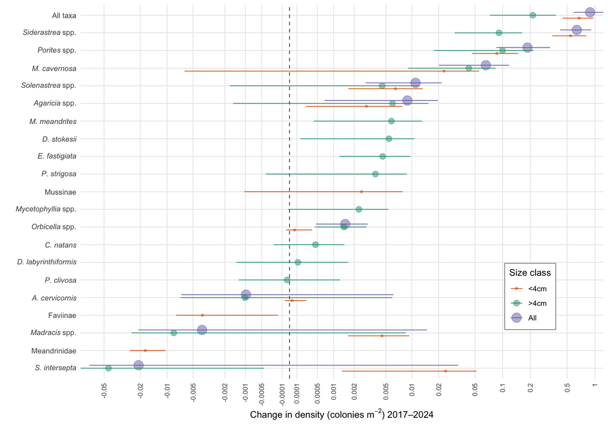

```r
# Final figure 6 trends plot

# Custom signed log-like transform
signed_pseudo_log <- function(x, scale = 1000) {
  sign(x) * log1p(abs(x) * scale)
}

# Transform slopes
scale_factor <- 2000
trends_summary_trans <- trends_summary %>%
  mutate(
    abs_change_trans = signed_pseudo_log(abs_change, scale = scale_factor),
    lower_trans = signed_pseudo_log(abs_change.lower, scale = scale_factor),
    upper_trans = signed_pseudo_log(abs_change.upper, scale = scale_factor),
    taxon = fct_reorder(taxon, abs_change)
  )

# Tick marks (original scale)
ticks <- c(-1, -0.5, -0.2, -0.1, -0.05, -0.02, -0.01, -0.005, -0.002, -0.001,
            -0.0005, -0.0001, 0.0001, 0.0005,
            0.001, 0.002, 0.005, 0.01, 0.02, 0.05, 0.1, 0.2, 0.5, 1)
# Custom function to format tick labels
format_ticks <- function(x) {
  sapply(x, function(v) {
    if (v == 0) {
      "0"
    } else {
      sub("\\.?0+$", "", format(v, scientific = FALSE, trim = TRUE))
    }
  })
}

xmax <- max(trends_summary_trans$upper_trans)
xmin <- min(trends_summary_trans$lower_trans)

# Plot
ggplot(trends_summary_trans, aes(x = abs_change_trans, y = taxon)) +
  geom_point(aes(color = class, size = class), position = position_dodge(width = 0.5),
             alpha = 0.5) +
  geom_errorbarh(aes(color = class, xmin = lower_trans, xmax = upper_trans),
                 position = position_dodge(width = 0.5), height = 0, linewidth = 0.4) +
  geom_vline(xintercept = 0, linetype = "dashed", color = "gray40") +
  scale_x_continuous(
    breaks = signed_pseudo_log(ticks, scale = scale_factor),      # positions in transformed space
    minor_breaks = NULL,
    labels = format_ticks(ticks),       # labels in original space
    limits = c(xmin, xmax),
    expand = expansion(mult = c(0, 0))
  ) +
  scale_y_discrete(
    labels = function(x) parse(text = taxon_labels[x])  # now safe with proper levels
  )  +
  scale_color_manual(values = c("<4cm" = "#d95f02", ">4cm" = "#1b9e77", "All" = "#7570b3"))+
  scale_size_manual(values = c(1,3,5)) +
  labs(
    x = expression("Change in density (colonies m"^{-2}*") 2017–2024"),
    y = "",
    color = "Size class",
    size = "Size class"
  ) +
  theme_minimal() +
  coord_cartesian(clip = "off") +
  theme(axis.text.x = element_text(angle = 90, vjust = 0.5, hjust = 1, size = 8),
        plot.background = element_rect(fill = "white", color = NA),
        legend.position = c(0.86, 0.22),
        legend.background = element_rect(fill = "white", linewidth = 0.2),
        legend.spacing.y = unit(0.1, "cm"),    # vertical space between items
        legend.spacing.x = unit(0.1, "cm"))    # horizontal space between items)
```

```r
save_figure(filename = output_file("Fig5.png"), width = 140, height = 120, units = "mm", dpi = 300)
```

```r
# Fixed manuscript color identity, independent of the new fitted abundance ranking.
taxon_palette_order <- c("SIDE", "PORI", "SINT", "MCAV", "MADR", "AGAR", "SOLE", "MMEA", "DSTO", "ACER", "MEAN", "PSTR", "EFAS", "MYCE", "FAVI", "MUSS", "PCLI", "DLAB", "ORBI", "CNAT")
```

## 7.3 Totals in impact zones

### 7.3.1 Equal-weighted estimates

```r
format_count <- function(x) {
  format(round(x), big.mark = ",", scientific = FALSE, trim = TRUE)
}

format_interval_count <- function(estimate, lower, upper) {
  paste0(
    format_count(estimate),
    " (",
    format_count(lower),
    "-",
    format_count(upper),
    ")"
  )
}

make_taxclass_zone_interval_table <- function(draw_totals) {
  draw_totals <- draw_totals %>%
    mutate(
      taxon = as.character(taxon),
      class = as.character(class),
      name = as.character(name)
    )

  draw_totals_for_table <- bind_rows(
    draw_totals,
    draw_totals %>%
      group_by(.draw, taxon, class) %>%
      summarize(name = "Total", tot = sum(tot), .groups = "drop"),
    draw_totals %>%
      group_by(.draw, name) %>%
      summarize(taxon = "Total", class = "-", tot = sum(tot), .groups = "drop"),
    draw_totals %>%
      group_by(.draw) %>%
      summarize(taxon = "Total", class = "-", name = "Total", tot = sum(tot), .groups = "drop")
  )

  draw_totals_for_table %>%
    mutate(
      name = factor(name, levels = c(zone_levels, "Total")),
      taxon = factor(taxon, levels = c(sort(unique(draw_totals$taxon)), "Total")),
      class = factor(class, levels = c("<4cm", ">4cm", "-"))
    ) %>%
    group_by(taxon, class, name) %>%
    summarize(
      tot_estimate = mean(tot),
      tot_lower_95 = quantile(tot, 0.025),
      tot_upper_95 = quantile(tot, 0.975),
      .groups = "drop"
    ) %>%
    mutate(tot = format_interval_count(tot_estimate, tot_lower_95, tot_upper_95)) %>%
    arrange(taxon, class, name) %>%
    select(taxon, class, name, tot) %>%
    pivot_wider(names_from = name, values_from = tot, names_sort = FALSE) %>%
    mutate(
      taxon = as.character(taxon),
      class = as.character(class)
    )
}

# TOTAL COLONIES IN EACH IMPACT ZONE
densities_tot_draws <- draws_equal_weighted_combined %>% filter(class != "All")

# Calculate total per taxclass per habitat Type and impact zone
tot1_draws <- left_join(densities_tot_draws, area_summary, by = "Type") %>%
  mutate(tot = n_m2 * total_area_m2)

# Calculate total per taxclass per impact zone (sum all habitat Types)
tot2_draws <- tot1_draws %>%
  group_by(.draw, taxon, class, name) %>%
  summarize(tot = sum(tot), .groups = "drop") %>%
  arrange(name)

tot2 <- tot2_draws %>%
  group_by(taxon, class, name) %>%
  mean_qi(tot, .width = 0.95) %>%
  ungroup() %>%
  mutate(tot = round(tot))

tab2 <- make_taxclass_zone_interval_table(tot2_draws)

tab2 %>%
  knitr::kable(caption = "Total number of colonies in each impact zone - surveys (years) equal-weighted")
```

Total number of colonies in each impact zone - surveys (years) equal-weighted

| taxon | class | Channel | Side Slopes | Depth_10cm | Depth_5cm | Depth_1cm | Depth_0_5cm | Depth_0_1cm | Nearshore | North | East | South | Rest of Monitoring Area | Total |
| --- | --- | --- | --- | --- | --- | --- | --- | --- | --- | --- | --- | --- | --- | --- |
| ACER | <4cm | 4 (0-17) | 4 (1-12) | 11 (3-31) | 11 (3-31) | 53 (16-150) | 36 (11-101) | 92 (28-266) | 13 (4-36) | 2 (0-10) | 1 (0-6) | 1 (0-4) | 316 (94-907) | 544 (164-1,558) |
| ACER | >4cm | 30 (8-126) | 397 (209-688) | 936 (492-1,625) | 958 (504-1,663) | 4,641 (2,443-8,048) | 3,164 (1,666-5,482) | 8,122 (4,274-14,085) | 1,315 (693-2,273) | 12 (1-58) | 7 (0-36) | 5 (0-26) | 26,193 (13,775-45,419) | 45,779 (24,091-79,382) |
| AGAR | <4cm | 437 (209-818) | 53 (21-122) | 226 (112-450) | 225 (112-448) | 999 (487-2,050) | 654 (319-1,347) | 1,758 (817-3,703) | 111 (28-308) | 398 (170-786) | 248 (106-490) | 176 (76-348) | 7,548 (3,813-14,879) | 12,832 (6,514-24,420) |
| AGAR | >4cm | 2,151 (1,433-3,092) | 246 (157-371) | 961 (687-1,310) | 963 (685-1,313) | 4,249 (3,032-5,837) | 2,811 (1,990-3,884) | 7,212 (5,142-10,057) | 478 (246-862) | 1,873 (1,170-2,810) | 1,167 (729-1,751) | 830 (519-1,246) | 31,970 (23,071-43,395) | 54,911 (39,560-74,576) |
| CNAT | >4cm | 73 (23-164) | 11 (4-25) | 45 (18-86) | 44 (18-85) | 198 (81-385) | 129 (53-254) | 350 (142-692) | 23 (5-64) | 61 (15-148) | 38 (9-93) | 27 (7-66) | 1,452 (617-2,766) | 2,453 (1,044-4,647) |
| DLAB | >4cm | 173 (74-339) | 38 (18-70) | 122 (63-214) | 120 (62-210) | 548 (280-964) | 361 (184-632) | 942 (477-1,659) | 74 (24-163) | 101 (32-228) | 63 (20-142) | 45 (14-101) | 3,771 (1,965-6,534) | 6,359 (3,318-10,999) |
| DSTO | >4cm | 505 (334-737) | 453 (299-649) | 1,303 (916-1,785) | 1,303 (910-1,801) | 6,161 (4,288-8,552) | 4,097 (2,836-5,717) | 11,074 (7,724-15,280) | 1,336 (836-2,002) | 324 (180-520) | 202 (112-324) | 144 (80-231) | 38,463 (27,377-52,082) | 65,364 (46,049-89,242) |
| EFAS | >4cm | 471 (277-740) | 62 (36-101) | 279 (176-424) | 265 (169-403) | 1,174 (737-1,790) | 743 (469-1,137) | 2,104 (1,273-3,296) | 47 (11-116) | 260 (126-472) | 162 (79-294) | 115 (56-209) | 9,012 (5,685-13,710) | 14,694 (9,358-22,313) |
| FAVI | <4cm | 462 (256-747) | 190 (112-304) | 544 (344-850) | 540 (341-847) | 2,522 (1,577-3,972) | 1,677 (1,040-2,658) | 4,387 (2,721-6,906) | 473 (248-835) | 228 (114-406) | 142 (71-253) | 101 (51-180) | 16,138 (10,335-24,898) | 27,405 (17,525-42,388) |
| MADR | <4cm | 716 (399-1,163) | 56 (25-116) | 252 (145-421) | 258 (148-431) | 1,112 (634-1,895) | 741 (418-1,271) | 1,865 (1,061-3,231) | 117 (35-287) | 712 (396-1,155) | 444 (247-720) | 316 (175-512) | 8,849 (5,191-14,234) | 15,437 (9,011-24,849) |
| MADR | >4cm | 4,875 (3,273-7,038) | 657 (354-1,197) | 2,224 (1,426-3,549) | 2,252 (1,438-3,593) | 10,039 (6,334-16,564) | 6,736 (4,233-11,142) | 16,623 (10,274-27,855) | 1,437 (560-3,145) | 4,181 (2,633-6,326) | 2,606 (1,641-3,942) | 1,853 (1,167-2,804) | 72,384 (47,689-111,170) | 125,868 (83,303-193,255) |
| MCAV | <4cm | 10,669 (7,760-14,406) | 1,757 (1,283-2,346) | 6,619 (5,175-8,282) | 6,540 (5,098-8,195) | 29,400 (22,881-37,002) | 19,241 (14,978-24,131) | 51,634 (40,027-65,654) | 3,578 (2,256-5,363) | 8,384 (5,523-12,160) | 5,225 (3,442-7,578) | 3,716 (2,448-5,389) | 213,010 (167,514-265,225) | 359,772 (283,139-450,324) |
| MCAV | >4cm | 11,900 (8,856-15,648) | 1,693 (1,258-2,230) | 6,362 (5,046-7,870) | 6,252 (4,941-7,721) | 27,887 (21,996-34,663) | 18,231 (14,416-22,738) | 48,004 (37,704-59,761) | 2,820 (1,782-4,169) | 8,563 (5,758-12,260) | 5,336 (3,588-7,640) | 3,795 (2,552-5,433) | 205,096 (163,083-253,033) | 345,939 (274,867-426,720) |
| MEAN | <4cm | 1,269 (879-1,765) | 368 (248-528) | 1,128 (819-1,524) | 1,125 (815-1,530) | 5,193 (3,728-7,113) | 3,452 (2,465-4,748) | 9,027 (6,401-12,338) | 915 (552-1,403) | 894 (565-1,316) | 557 (352-820) | 396 (251-583) | 34,472 (25,476-45,922) | 58,795 (43,122-78,732) |
| MMEA | >4cm | 1,425 (956-2,066) | 180 (117-270) | 585 (419-802) | 573 (408-786) | 2,533 (1,789-3,504) | 1,677 (1,182-2,331) | 4,028 (2,831-5,584) | 209 (97-384) | 848 (491-1,360) | 529 (306-848) | 376 (218-603) | 18,462 (13,292-25,018) | 31,425 (22,520-42,830) |
| MUSS | <4cm | 538 (299-901) | 86 (35-181) | 302 (150-555) | 304 (152-558) | 1,370 (667-2,591) | 911 (442-1,738) | 2,351 (1,118-4,464) | 205 (52-521) | 474 (235-822) | 295 (147-513) | 210 (104-364) | 9,769 (4,993-17,228) | 16,817 (8,606-29,891) |
| MYCE | >4cm | 445 (258-725) | 58 (31-97) | 197 (118-305) | 189 (114-293) | 835 (497-1,302) | 544 (324-848) | 1,356 (802-2,122) | 43 (9-114) | 216 (95-408) | 134 (59-254) | 96 (42-181) | 6,160 (3,769-9,389) | 10,271 (6,288-15,742) |
| ORBI | <4cm | 13 (2-46) | 3 (0-11) | 8 (1-35) | 8 (1-33) | 36 (6-153) | 24 (4-100) | 59 (11-251) | 5 (1-20) | 7 (1-24) | 4 (0-15) | 3 (0-11) | 241 (46-1,011) | 410 (79-1,717) |
| ORBI | >4cm | 92 (57-146) | 14 (9-22) | 66 (45-94) | 64 (45-92) | 288 (200-411) | 185 (128-264) | 531 (365-771) | 28 (15-47) | 78 (45-130) | 49 (28-81) | 35 (20-57) | 2,169 (1,504-3,109) | 3,599 (2,505-5,135) |
| PCLI | >4cm | 32 (7-84) | 87 (44-156) | 212 (109-373) | 216 (111-382) | 1,039 (529-1,837) | 706 (358-1,250) | 1,816 (930-3,222) | 280 (137-506) | 14 (0-49) | 8 (0-31) | 6 (0-22) | 5,970 (3,075-10,477) | 10,385 (5,354-18,296) |
| PORI | <4cm | 8,815 (6,014-12,712) | 1,229 (840-1,793) | 4,357 (3,237-5,914) | 4,438 (3,277-6,037) | 19,836 (14,589-27,180) | 13,295 (9,751-18,263) | 33,644 (24,688-46,275) | 3,088 (1,854-4,884) | 8,412 (5,360-12,663) | 5,242 (3,340-7,891) | 3,728 (2,375-5,612) | 143,266 (106,318-191,291) | 249,349 (184,460-334,141) |
| PORI | >4cm | 27,947 (20,416-37,210) | 2,945 (2,195-3,915) | 11,704 (9,246-14,544) | 11,769 (9,277-14,628) | 51,688 (40,695-64,393) | 34,260 (26,919-42,770) | 87,142 (68,126-108,931) | 5,657 (3,625-8,431) | 24,779 (16,890-34,109) | 15,442 (10,526-21,257) | 10,982 (7,485-15,117) | 393,076 (309,147-487,080) | 677,391 (530,388-844,513) |
| PSTR | >4cm | 383 (223-602) | 193 (124-292) | 611 (422-864) | 599 (411-848) | 2,795 (1,916-3,978) | 1,829 (1,250-2,614) | 5,044 (3,417-7,163) | 473 (270-771) | 151 (64-291) | 94 (40-182) | 67 (28-129) | 18,314 (12,595-25,549) | 30,553 (21,067-42,775) |
| SIDE | <4cm | 44,957 (32,844-60,659) | 28,975 (19,807-41,064) | 80,246 (57,656-109,520) | 80,862 (57,793-110,824) | 381,651 (270,193-527,021) | 255,883 (180,567-354,704) | 672,851 (481,495-928,406) | 85,626 (55,180-126,144) | 33,065 (21,998-47,899) | 20,606 (13,709-29,851) | 14,654 (9,749-21,228) | 2,368,902 (1,740,949-3,212,403) | 4,068,278 (2,968,848-5,520,951) |
| SIDE | >4cm | 19,977 (15,212-25,549) | 4,386 (3,285-5,760) | 15,568 (12,461-19,402) | 15,279 (12,193-19,068) | 69,526 (55,302-87,438) | 45,392 (35,931-57,014) | 123,216 (97,022-154,821) | 9,134 (6,029-13,353) | 13,501 (9,431-18,612) | 8,414 (5,877-11,599) | 5,983 (4,180-8,249) | 488,203 (392,114-605,762) | 818,579 (657,396-1,015,473) |
| SINT | <4cm | 9,780 (7,056-13,297) | 1,642 (1,172-2,307) | 5,575 (4,256-7,211) | 5,582 (4,230-7,251) | 25,162 (18,965-33,159) | 16,720 (12,552-22,204) | 42,908 (32,189-56,925) | 3,645 (2,250-5,788) | 7,912 (5,163-11,518) | 4,931 (3,218-7,178) | 3,506 (2,288-5,105) | 177,967 (137,244-228,097) | 305,328 (234,834-393,018) |
| SINT | >4cm | 19,396 (14,249-26,034) | 3,661 (2,690-4,982) | 12,242 (9,534-15,552) | 12,131 (9,400-15,540) | 54,953 (42,532-70,951) | 36,299 (27,926-47,081) | 94,299 (72,882-121,437) | 7,581 (4,803-11,545) | 13,767 (9,049-20,222) | 8,580 (5,639-12,603) | 6,101 (4,010-8,962) | 384,621 (298,287-484,295) | 653,631 (505,818-824,701) |
| SOLE | <4cm | 657 (345-1,143) | 190 (105-323) | 672 (413-1,066) | 669 (410-1,058) | 3,076 (1,869-4,918) | 2,021 (1,217-3,238) | 5,576 (3,340-8,926) | 516 (244-947) | 605 (291-1,080) | 377 (181-673) | 268 (129-479) | 21,160 (13,031-33,384) | 35,787 (22,025-56,310) |
| SOLE | >4cm | 525 (313-809) | 460 (303-680) | 1,293 (899-1,827) | 1,296 (897-1,841) | 6,136 (4,221-8,779) | 4,093 (2,809-5,854) | 10,954 (7,516-15,628) | 1,360 (851-2,091) | 324 (166-564) | 202 (103-352) | 144 (73-250) | 37,998 (26,577-53,061) | 64,785 (45,157-90,856) |
| Total | - | 168,718 (151,009-189,458) | 50,095 (40,439-62,621) | 154,649 (131,296-184,905) | 154,836 (131,090-185,537) | 715,097 (602,215-864,129) | 475,910 (399,367-576,965) | 1,248,970 (1,048,719-1,515,281) | 130,587 (99,072-171,662) | 130,145 (112,851-151,261) | 81,106 (70,328-94,265) | 57,679 (50,014-67,037) | 4,744,951 (4,076,193-5,604,287) | 8,112,743 (6,953,343-9,592,383) |

```r
write_csv(tab2, file = output_file("TableA4.csv"))


# Calculate total ESA and non-ESA corals per impact zone
tot3_draws <- tot2_draws %>%
  mutate(ESA = case_when(!taxon %in% c("ACER", "ORBI") ~ "non-ESA",
                         TRUE ~ taxon)) %>%
  group_by(.draw, name, ESA) %>%
  summarize(tot = sum(tot), .groups = "drop") %>%
  pivot_wider(names_from = ESA, values_from = tot, values_fill = list(tot = 0)) %>%
  mutate(Total = ACER + ORBI + `non-ESA`)

tot3 <- tot3_draws %>%
  group_by(name) %>%
  summarize(
    ACER = round(mean(ACER)),
    ORBI = round(mean(ORBI)),
    `non-ESA` = round(mean(`non-ESA`)),
    Total = round(mean(Total)),
    .groups = "drop"
  ) %>%
  mutate(cum_ACER = cumsum(ACER),
         cum_ORBI = cumsum(ORBI),
         cum_non_ESA = cumsum(`non-ESA`),
         cum_Total = cumsum(Total)) %>%
  mutate(across(where(is.numeric), ~ format(round(.), big.mark = ",")))

tot3 %>%
  knitr::kable(caption = "Total coral colonies in all impact zones")
```

Total coral colonies in all impact zones

| name | ACER | ORBI | non-ESA | Total | cum_ACER | cum_ORBI | cum_non_ESA | cum_Total |
| --- | --- | --- | --- | --- | --- | --- | --- | --- |
| Channel | 34 | 105 | 168,578 | 168,718 | 34 | 105 | 168,578 | 168,718 |
| Side Slopes | 401 | 17 | 49,677 | 50,095 | 435 | 122 | 218,255 | 218,813 |
| Depth_10cm | 947 | 74 | 153,629 | 154,649 | 1,382 | 196 | 371,884 | 373,462 |
| Depth_5cm | 969 | 72 | 153,794 | 154,836 | 2,351 | 268 | 525,678 | 528,298 |
| Depth_1cm | 4,693 | 323 | 710,080 | 715,097 | 7,044 | 591 | 1,235,758 | 1,243,395 |
| Depth_0_5cm | 3,200 | 208 | 472,502 | 475,910 | 10,244 | 799 | 1,708,260 | 1,719,305 |
| Depth_0_1cm | 8,214 | 590 | 1,240,165 | 1,248,970 | 18,458 | 1,389 | 2,948,425 | 2,968,275 |
| Nearshore | 1,327 | 33 | 129,227 | 130,587 | 19,785 | 1,422 | 3,077,652 | 3,098,862 |
| North | 14 | 85 | 130,046 | 130,145 | 19,799 | 1,507 | 3,207,698 | 3,229,007 |
| East | 9 | 53 | 81,045 | 81,106 | 19,808 | 1,560 | 3,288,743 | 3,310,113 |
| South | 6 | 38 | 57,635 | 57,679 | 19,814 | 1,598 | 3,346,378 | 3,367,792 |
| Rest of Monitoring Area | 26,508 | 2,410 | 4,716,033 | 4,744,951 | 46,322 | 4,008 | 8,062,411 | 8,112,743 |

```r
dir.create(output_file("intermediate"), recursive = TRUE, showWarnings = FALSE)
write_csv(tot3, file = output_file("intermediate/coral_Table2.csv"))

tot3_total_draws <- tot3_draws %>%
  group_by(.draw) %>%
  summarize(
    name = "Total",
    ACER = sum(ACER),
    ORBI = sum(ORBI),
    `non-ESA` = sum(`non-ESA`),
    Total = sum(Total),
    .groups = "drop"
  )

tot3_intervals <- bind_rows(tot3_draws, tot3_total_draws) %>%
  mutate(name = factor(name, levels = c(zone_levels, "Total"))) %>%
  arrange(name) %>%
  group_by(name) %>%
  summarize(
    ACER_estimate = mean(ACER),
    ACER_lower_95 = quantile(ACER, 0.025),
    ACER_upper_95 = quantile(ACER, 0.975),
    ORBI_estimate = mean(ORBI),
    ORBI_lower_95 = quantile(ORBI, 0.025),
    ORBI_upper_95 = quantile(ORBI, 0.975),
    non_ESA_estimate = mean(`non-ESA`),
    `non-ESA_lower_95` = quantile(`non-ESA`, 0.025),
    `non-ESA_upper_95` = quantile(`non-ESA`, 0.975),
    Total_estimate = mean(Total),
    Total_lower_95 = quantile(Total, 0.025),
    Total_upper_95 = quantile(Total, 0.975),
    .groups = "drop"
  ) %>%
  rename(
    ACER = ACER_estimate,
    ORBI = ORBI_estimate,
    `non-ESA` = non_ESA_estimate,
    Total = Total_estimate
  ) %>%
  select(
    name,
    ACER, ACER_lower_95, ACER_upper_95,
    ORBI, ORBI_lower_95, ORBI_upper_95,
    `non-ESA`, `non-ESA_lower_95`, `non-ESA_upper_95`,
    Total, Total_lower_95, Total_upper_95
  ) %>%
  mutate(name = as.character(name))

tot3_intervals %>%
  knitr::kable(caption = "Total coral colonies in all impact zones with 95% posterior intervals")
```

Total coral colonies in all impact zones with 95% posterior intervals

| name | ACER | ACER_lower_95 | ACER_upper_95 | ORBI | ORBI_lower_95 | ORBI_upper_95 | non-ESA | non-ESA_lower_95 | non-ESA_upper_95 | Total | Total_lower_95 | Total_upper_95 |
| --- | --- | --- | --- | --- | --- | --- | --- | --- | --- | --- | --- | --- |
| Channel | 34.498450 | 1.021678e+01 | 145.03038 | 105.17698 | 64.95938 | 168.67232 | 168578.17 | 150875.70 | 189328.03 | 168717.85 | 151009.01 | 189458.29 |
| Side Slopes | 401.009450 | 2.117615e+02 | 690.28916 | 16.91917 | 10.77887 | 28.50475 | 49677.30 | 40040.91 | 62103.71 | 50095.23 | 40438.89 | 62620.93 |
| Depth_10cm | 946.779576 | 5.006528e+02 | 1633.22046 | 73.83201 | 50.37932 | 114.25645 | 153628.75 | 130541.07 | 183938.85 | 154649.36 | 131295.68 | 184904.94 |
| Depth_5cm | 969.493948 | 5.131626e+02 | 1673.68369 | 72.13981 | 49.42417 | 110.25235 | 153794.01 | 130259.70 | 184623.33 | 154835.64 | 131089.77 | 185537.35 |
| Depth_1cm | 4693.461462 | 2.481090e+03 | 8090.96875 | 323.43434 | 220.81751 | 497.65489 | 710080.46 | 598246.23 | 859202.03 | 715097.36 | 602214.56 | 864128.83 |
| Depth_0_5cm | 3199.783085 | 1.689584e+03 | 5507.13976 | 208.15476 | 142.34613 | 322.74508 | 472501.65 | 396504.02 | 573410.64 | 475909.58 | 399366.51 | 576965.24 |
| Depth_0_1cm | 8214.187412 | 4.341454e+03 | 14161.77053 | 590.28731 | 397.84097 | 905.24803 | 1240165.48 | 1041191.19 | 1506280.60 | 1248969.95 | 1048719.48 | 1515280.88 |
| Nearshore | 1327.263083 | 7.021297e+02 | 2284.20835 | 32.67923 | 17.82869 | 57.19385 | 129227.19 | 97648.62 | 170476.79 | 130587.13 | 99072.10 | 171661.52 |
| North | 13.696630 | 9.828444e-01 | 60.44697 | 85.31148 | 48.98858 | 140.93265 | 130046.36 | 112713.99 | 151147.69 | 130145.37 | 112850.52 | 151260.79 |
| East | 8.535709 | 6.125064e-01 | 37.67042 | 53.16593 | 30.52958 | 87.82891 | 81044.60 | 70243.11 | 94194.90 | 81106.30 | 70328.19 | 94265.39 |
| South | 6.070160 | 4.355833e-01 | 26.78928 | 37.80889 | 21.71107 | 62.45943 | 57634.78 | 49953.30 | 66986.60 | 57678.66 | 50013.81 | 67036.72 |
| Rest of Monitoring Area | 26508.028265 | 1.401910e+04 | 45660.83210 | 2409.97381 | 1656.39730 | 3656.46846 | 4716032.96 | 4051433.67 | 5582410.83 | 4744950.96 | 4076193.43 | 5604287.20 |
| Total | 46322.807229 | 2.451112e+04 | 79852.94427 | 4008.88372 | 2753.56934 | 6069.71220 | 8062411.71 | 6913695.98 | 9549186.62 | 8112743.40 | 6953343.11 | 9592382.91 |

```r
write_csv(tot3_intervals, file = output_file("intermediate/coral_Table2_intervals.csv"))
```

#### 7.3.1.1 Treemap plot - Scenario2+NMFS

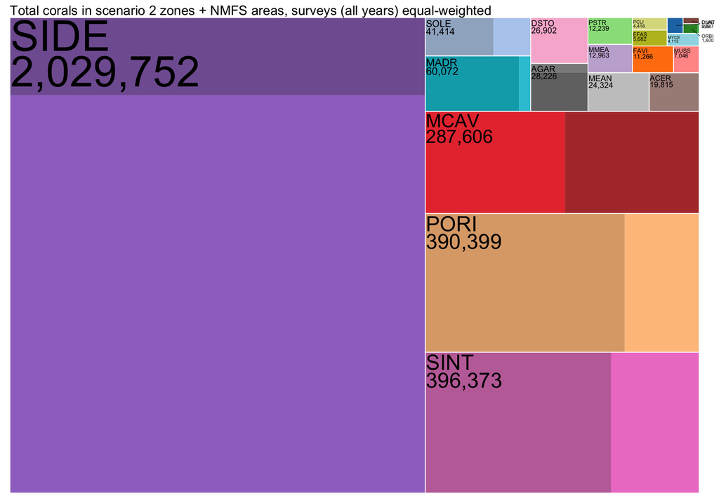

```r
# Aggregate total abundance by taxon + class
tot4 <- tot2 %>%
  filter(name != "Rest of Monitoring Area") %>%
  group_by(taxon, class) %>%
  summarize(tot = sum(tot), .groups = "drop")

# Assign a base color per taxon
set.seed(3)
base_colors <- sample(ggsci::pal_d3("category20")(20), 20)
names(base_colors) <- taxon_palette_order

# Define shading function
get_shades <- function(base_col, class, all_classes) {
  if (length(all_classes) == 2) {
    if (class == "<4cm") colorspace::lighten(base_col, 0.1)
    else colorspace::darken(base_col, 0.1)
  } else {
    base_col
  }
}

# Build taxon_class and corresponding shades
shade_map <- tot4 %>%
  distinct(taxon, class) %>%
  rowwise() %>%
  mutate(
    base_col = base_colors[[taxon]],
    all_classes = list(tot4$class[tot4$taxon == taxon]),
    shade = get_shades(base_col, class, all_classes),
    taxon_class = paste(taxon, class, sep = "_")
  ) %>%
  ungroup()

# Final color map
fill_colors <- setNames(shade_map$shade, shade_map$taxon_class)

# Add taxon_class to original data
tot4 <- tot4 %>%
  mutate(taxon_class = paste(taxon, class, sep = "_"))

# Plot with taxon labels only
p <- ggplot(tot4, aes(area = tot, fill = taxon_class, subgroup = taxon)) +
  geom_treemap(color = NA)+#, layout = "srow") +
  geom_treemap_subgroup_border(colour = "white", size = 1)+#, layout = "srow") +
  # geom_treemap_subgroup_text(place = "topleft", grow = TRUE,
  #                             alpha = 0.8, colour = "black", size = 8) +
  scale_fill_manual(values = fill_colors) +
  theme(legend.position = "none")


# Get tile layout and attach taxon_class
tile_layout <- treemapify(tot4, area = "tot",#, layout = "srow",
                          fill = "taxon_class", subgroup = "taxon")

# Flag small boxes (aggregate size classes)
tile_layout_ag <- tile_layout %>%
  group_by(taxon) %>%
  summarize(xmin = min(xmin), xmax = max(xmax),
            ymin = min(ymin), ymax = max(ymax),
            area = (xmax - xmin) * (ymax - ymin),
            center_x = (xmin + xmax) / 2,
            center_y = (ymin + ymax) / 2)
area_threshold <- 0.001
internal_labels <- tile_layout_ag %>%
  filter(area >= area_threshold)
external_labels <- tile_layout_ag %>%
  filter(area < area_threshold)

# Create labels with taxontotals
taxtots <- tot4 %>%
  group_by(taxon) %>%
  summarize(tot = scales::comma(sum(tot)))

internal_labels <- left_join(internal_labels, taxtots) %>%
  mutate(label = paste0(taxon, "\n", tot))

external_labels <- left_join(external_labels, taxtots) %>%
  mutate(label = paste0(taxon, "\n", tot))

# Final plot
p +
  scale_x_continuous(limits = c(0, 1), expand = c(0, 0)) +
  scale_y_continuous(limits = c(0, 1), expand = c(0, 0)) +
  coord_cartesian(clip = "off") +
  geom_text(data = internal_labels,
            aes(x = xmin, y = ymax-0.00001,
                label = label, size = area), inherit.aes = FALSE,
            hjust = 0, vjust = 1, lineheight = 0.7,
            nudge_x = 0.001, nudge_y = -0.005) +
  scale_size_continuous(range = c(1.5, 15)) +
  geom_text_repel(data = external_labels,
             aes(x = center_x, y = center_y,
                 label = label), inherit.aes = FALSE,
             max.overlaps = Inf,
             box.padding = 0.18,
             xlim = c(1, NA),
             force = 3,
             lineheight = 0.7,
             min.segment.length = 0.1,
             segment.size = 0.2,
             hjust = 0,
             size = 1.7, seed = 123) +
  theme_void() +
  theme(
    legend.position = "none",
    plot.margin = margin(t = 0, r = 20, b = 10, l = 10),
    plot.background = element_rect(fill = "white", color = NA),
  ) +
  labs(title = "Total corals in scenario 2 zones + NMFS areas, surveys (all years) equal-weighted")
```

```r
save_figure(filename = output_file("Fig6.png"), width = 180, height = 130, units = "mm", dpi = 600)
```

#### 7.3.1.2 Treemap plot - Full monitoring area

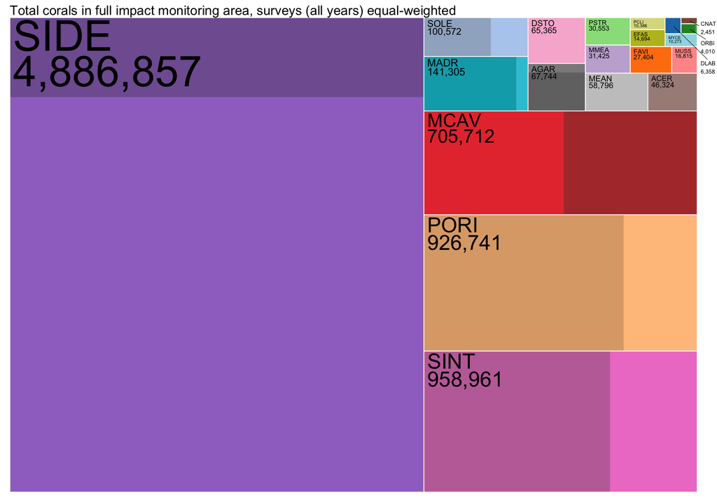

```r
# Aggregate total abundance by taxon + class
tot4 <- tot2 %>%
  group_by(taxon, class) %>%
  summarize(tot = sum(tot), .groups = "drop")

# Assign a base color per taxon
set.seed(3)
base_colors <- sample(ggsci::pal_d3("category20")(20), 20)
names(base_colors) <- taxon_palette_order

# Define shading function
get_shades <- function(base_col, class, all_classes) {
  if (length(all_classes) == 2) {
    if (class == "<4cm") colorspace::lighten(base_col, 0.1)
    else colorspace::darken(base_col, 0.1)
  } else {
    base_col
  }
}

# Build taxon_class and corresponding shades
shade_map <- tot4 %>%
  distinct(taxon, class) %>%
  rowwise() %>%
  mutate(
    base_col = base_colors[[taxon]],
    all_classes = list(tot4$class[tot4$taxon == taxon]),
    shade = get_shades(base_col, class, all_classes),
    taxon_class = paste(taxon, class, sep = "_")
  ) %>%
  ungroup()

# Final color map
fill_colors <- setNames(shade_map$shade, shade_map$taxon_class)

# Add taxon_class to original data
tot4 <- tot4 %>%
  mutate(taxon_class = paste(taxon, class, sep = "_"))

# Plot with taxon labels only
p <- ggplot(tot4, aes(area = tot, fill = taxon_class, subgroup = taxon)) +
  geom_treemap(color = NA) +
  geom_treemap_subgroup_border(colour = "white", size = 1) +
  # geom_treemap_subgroup_text(place = "topleft", grow = TRUE,
  #                             alpha = 0.8, colour = "black", size = 8) +
  scale_fill_manual(values = fill_colors) +
  theme(legend.position = "none")


# Get tile layout and attach taxon_class
tile_layout <- treemapify(tot4, area = "tot",
                          fill = "taxon_class", subgroup = "taxon")

# Flag small boxes (aggregate size classes)
tile_layout_ag <- tile_layout %>%
  group_by(taxon) %>%
  summarize(xmin = min(xmin), xmax = max(xmax),
            ymin = min(ymin), ymax = max(ymax),
            area = (xmax - xmin) * (ymax - ymin),
            center_x = (xmin + xmax) / 2,
            center_y = (ymin + ymax) / 2)
area_threshold <- 0.001
internal_labels <- tile_layout_ag %>%
  filter(area >= area_threshold)
external_labels <- tile_layout_ag %>%
  filter(area < area_threshold)

# Create labels with taxontotals
taxtots <- tot4 %>%
  group_by(taxon) %>%
  summarize(tot = scales::comma(sum(tot)))

internal_labels <- left_join(internal_labels, taxtots) %>%
  mutate(label = paste0(taxon, "\n", tot))

external_labels <- left_join(external_labels, taxtots) %>%
  mutate(label = paste0(taxon, "\n", tot))

# Final plot
p +
  scale_x_continuous(limits = c(0, 1), expand = c(0, 0)) +
  scale_y_continuous(limits = c(0, 1), expand = c(0, 0)) +
  coord_cartesian(clip = "off") +
  geom_text(data = internal_labels,
            aes(x = xmin, y = ymax-0.00001,
                label = label, size = area), inherit.aes = FALSE,
            hjust = 0, vjust = 1, lineheight = 0.7,
            nudge_x = 0.005, nudge_y = -0.005) +
  scale_size_continuous(range = c(1.5, 15)) +
  geom_text_repel(data = external_labels,
             aes(x = center_x, y = center_y,
                 label = label), inherit.aes = FALSE,
             max.overlaps = Inf,
             xlim = c(1, NA),
             force = 5,
             min.segment.length = 0.1,
             segment.size = 0.2,
             hjust = 0, seed = 123,
             size = 2) +
  theme_void() +
  theme(
    legend.position = "none",
    plot.margin = margin(t = 0, r = 20, b = 10, l = 10),
    plot.background = element_rect(fill = "white", color = NA),
  ) +
  labs(title = "Total corals in full impact monitoring area, surveys (all years) equal-weighted")
```

```r
save_figure(filename = output_file("FigA4.png"), width = 180, height = 130, units = "mm", dpi = 600)
```

### 7.3.2 2024 estimates

```r
# TOTAL COLONIES IN EACH IMPACT ZONE
densities_tot_2024_draws <- draws_drm24_combined %>% filter(class != "All")


# Calculate total per taxclass per habitat Type and impact zone
tot1_2024_draws <- left_join(densities_tot_2024_draws, area_summary, by = "Type") %>%
  mutate(tot = n_m2 * total_area_m2)

# Calculate total per taxclass per impact zone (sum all habitat Types)
tot2_2024_draws <- tot1_2024_draws %>%
  group_by(.draw, taxon, class, name) %>%
  summarize(tot = sum(tot), .groups = "drop") %>%
  arrange(name)

tot2_2024 <- tot2_2024_draws %>%
  group_by(taxon, class, name) %>%
  mean_qi(tot, .width = 0.95) %>%
  ungroup() %>%
  mutate(tot = round(tot))

tab2_2024 <- make_taxclass_zone_interval_table(tot2_2024_draws)

tab2_2024 %>%
  knitr::kable(caption = "Total number of colonies in each impact zone - 2024 estimates")
```

Total number of colonies in each impact zone - 2024 estimates

| taxon | class | Channel | Side Slopes | Depth_10cm | Depth_5cm | Depth_1cm | Depth_0_5cm | Depth_0_1cm | Nearshore | North | East | South | Rest of Monitoring Area | Total |
| --- | --- | --- | --- | --- | --- | --- | --- | --- | --- | --- | --- | --- | --- | --- |
| ACER | <4cm | 6 (0-26) | 5 (1-17) | 13 (2-44) | 13 (2-44) | 62 (10-213) | 42 (7-144) | 108 (18-376) | 14 (2-48) | 3 (0-13) | 2 (0-8) | 1 (0-6) | 374 (62-1,287) | 643 (107-2,190) |
| ACER | >4cm | 41 (6-182) | 442 (148-1,052) | 1,043 (350-2,487) | 1,068 (359-2,547) | 5,169 (1,733-12,323) | 3,524 (1,182-8,384) | 9,047 (3,034-21,674) | 1,460 (490-3,489) | 16 (0-71) | 10 (0-44) | 7 (0-32) | 29,208 (9,800-69,751) | 51,035 (17,141-121,937) |
| AGAR | <4cm | 501 (130-1,314) | 60 (16-160) | 257 (75-626) | 255 (76-622) | 1,131 (332-2,753) | 739 (218-1,821) | 1,990 (574-5,011) | 121 (22-388) | 451 (103-1,261) | 281 (64-786) | 200 (46-559) | 8,575 (2,505-21,026) | 14,561 (4,271-35,191) |
| AGAR | >4cm | 1,875 (728-3,783) | 220 (98-414) | 858 (394-1,590) | 857 (390-1,597) | 3,785 (1,728-7,015) | 2,497 (1,138-4,650) | 6,439 (2,988-11,976) | 409 (164-806) | 1,577 (564-3,338) | 983 (352-2,080) | 699 (250-1,479) | 28,416 (12,810-53,009) | 48,615 (21,779-91,151) |
| CNAT | >4cm | 120 (27-338) | 16 (4-39) | 67 (21-151) | 66 (21-150) | 294 (93-661) | 192 (61-434) | 520 (165-1,167) | 32 (5-95) | 102 (17-320) | 64 (11-200) | 45 (8-142) | 2,203 (703-4,940) | 3,723 (1,193-8,387) |
| DLAB | >4cm | 140 (39-344) | 31 (10-73) | 99 (34-216) | 97 (33-211) | 441 (153-965) | 289 (100-631) | 758 (258-1,666) | 56 (14-147) | 74 (15-221) | 46 (9-138) | 33 (7-98) | 3,042 (1,030-6,651) | 5,105 (1,728-11,098) |
| DSTO | >4cm | 608 (349-982) | 505 (307-763) | 1,494 (955-2,172) | 1,489 (946-2,180) | 7,023 (4,445-10,320) | 4,653 (2,934-6,888) | 12,689 (8,075-18,503) | 1,462 (843-2,279) | 377 (173-718) | 235 (108-447) | 167 (77-318) | 44,356 (28,615-64,502) | 75,058 (48,284-109,259) |
| EFAS | >4cm | 560 (229-1,182) | 74 (32-149) | 336 (156-645) | 319 (148-609) | 1,412 (656-2,701) | 892 (414-1,691) | 2,539 (1,124-4,906) | 51 (10-146) | 300 (93-732) | 187 (58-456) | 133 (41-324) | 10,860 (4,974-20,826) | 17,663 (8,145-33,994) |
| FAVI | <4cm | 336 (133-686) | 130 (61-249) | 379 (181-710) | 374 (180-700) | 1,741 (838-3,257) | 1,152 (552-2,172) | 3,028 (1,440-5,643) | 304 (127-619) | 138 (44-327) | 86 (27-204) | 61 (19-145) | 11,234 (5,354-20,732) | 18,963 (9,066-35,083) |
| MADR | <4cm | 647 (162-1,720) | 51 (12-145) | 231 (64-586) | 236 (65-597) | 1,019 (276-2,624) | 679 (183-1,760) | 1,712 (469-4,360) | 107 (19-336) | 639 (161-1,697) | 398 (100-1,058) | 283 (71-752) | 8,084 (2,267-20,410) | 14,086 (3,933-35,780) |
| MADR | >4cm | 2,780 (1,039-6,191) | 406 (136-954) | 1,328 (480-2,921) | 1,337 (483-2,955) | 5,985 (2,149-13,391) | 4,009 (1,436-9,031) | 9,885 (3,581-22,155) | 847 (222-2,233) | 2,218 (770-5,052) | 1,382 (480-3,148) | 983 (341-2,239) | 42,582 (15,699-93,899) | 73,743 (26,950-162,949) |
| MCAV | <4cm | 9,627 (5,572-15,856) | 1,619 (1,043-2,443) | 6,161 (4,078-9,106) | 6,055 (4,016-9,011) | 27,236 (18,037-40,459) | 17,753 (11,712-26,383) | 48,048 (31,702-70,720) | 3,127 (1,743-5,188) | 7,187 (3,429-13,218) | 4,479 (2,137-8,237) | 3,185 (1,520-5,858) | 197,640 (131,105-291,776) | 332,118 (219,134-493,030) |
| MCAV | >4cm | 13,719 (7,983-21,660) | 1,930 (1,253-2,849) | 7,330 (4,851-10,513) | 7,175 (4,743-10,348) | 31,973 (21,127-46,029) | 20,842 (13,722-30,082) | 55,111 (36,663-79,143) | 3,002 (1,706-5,043) | 9,538 (4,661-16,728) | 5,944 (2,905-10,425) | 4,227 (2,066-7,413) | 236,110 (155,554-340,833) | 396,901 (259,781-572,144) |
| MEAN | <4cm | 624 (281-1,138) | 184 (86-326) | 563 (271-969) | 558 (269-971) | 2,574 (1,246-4,495) | 1,704 (824-2,986) | 4,472 (2,131-7,768) | 428 (186-803) | 376 (147-758) | 235 (92-472) | 167 (65-336) | 17,100 (8,259-29,631) | 28,983 (14,005-50,617) |
| MMEA | >4cm | 1,789 (881-3,350) | 223 (115-391) | 724 (384-1,230) | 707 (373-1,201) | 3,121 (1,659-5,318) | 2,063 (1,084-3,513) | 4,944 (2,651-8,308) | 235 (93-489) | 1,026 (395-2,239) | 639 (246-1,396) | 455 (175-992) | 22,815 (12,024-38,960) | 38,740 (20,276-66,975) |
| MUSS | <4cm | 851 (264-1,998) | 120 (38-302) | 435 (157-992) | 438 (157-1,010) | 1,957 (696-4,522) | 1,301 (457-3,015) | 3,343 (1,196-7,813) | 270 (57-771) | 752 (212-1,891) | 469 (132-1,179) | 333 (94-838) | 14,225 (5,145-31,356) | 24,495 (8,804-54,636) |
| MYCE | >4cm | 437 (175-886) | 58 (24-119) | 197 (86-385) | 188 (82-366) | 833 (361-1,626) | 541 (234-1,051) | 1,354 (590-2,766) | 39 (7-113) | 195 (56-481) | 122 (35-300) | 87 (25-213) | 6,131 (2,682-12,029) | 10,183 (4,475-19,901) |
| ORBI | <4cm | 16 (1-73) | 3 (0-15) | 9 (1-45) | 9 (1-43) | 42 (4-199) | 28 (3-131) | 69 (7-327) | 5 (0-23) | 8 (0-35) | 5 (0-22) | 4 (0-15) | 285 (31-1,326) | 483 (53-2,229) |
| ORBI | >4cm | 278 (128-553) | 34 (18-57) | 168 (91-286) | 164 (89-279) | 728 (399-1,227) | 466 (254-788) | 1,338 (722-2,283) | 59 (27-113) | 246 (100-531) | 153 (62-331) | 109 (44-235) | 5,642 (3,033-9,774) | 9,386 (5,035-16,304) |
| PCLI | >4cm | 45 (8-135) | 109 (42-231) | 264 (103-561) | 269 (105-572) | 1,294 (504-2,764) | 878 (342-1,868) | 2,262 (874-4,819) | 345 (131-751) | 19 (1-77) | 12 (0-48) | 8 (0-34) | 7,459 (2,904-15,785) | 12,963 (5,038-27,527) |
| PORI | <4cm | 20,619 (10,103-37,877) | 2,277 (1,331-3,756) | 8,778 (5,101-14,412) | 8,963 (5,199-14,728) | 39,532 (23,081-64,515) | 26,465 (15,373-43,261) | 66,693 (38,866-109,130) | 5,463 (2,866-9,594) | 20,161 (9,558-38,949) | 12,564 (5,957-24,273) | 8,935 (4,236-17,262) | 296,311 (172,018-489,431) | 516,761 (297,239-854,194) |
| PORI | >4cm | 45,664 (25,003-77,926) | 4,366 (2,763-6,629) | 18,067 (11,549-27,662) | 18,159 (11,550-27,897) | 79,265 (50,677-120,881) | 52,459 (33,515-80,085) | 133,285 (85,763-202,925) | 7,837 (4,470-13,059) | 40,652 (19,326-73,661) | 25,334 (12,044-45,906) | 18,016 (8,565-32,646) | 612,926 (378,394-951,820) | 1,056,032 (646,597-1,650,355) |
| PSTR | >4cm | 563 (266-1,048) | 257 (144-438) | 836 (495-1,348) | 817 (478-1,331) | 3,800 (2,225-6,209) | 2,478 (1,444-4,092) | 6,873 (3,999-11,184) | 605 (299-1,117) | 221 (74-494) | 138 (46-308) | 98 (33-219) | 25,187 (14,816-40,697) | 41,874 (24,763-67,717) |
| SIDE | <4cm | 64,382 (38,217-100,711) | 37,680 (24,263-55,143) | 106,433 (71,798-151,404) | 107,025 (71,902-153,011) | 503,831 (337,199-721,633) | 337,043 (225,012-485,194) | 889,811 (595,689-1,272,612) | 109,654 (66,858-167,433) | 47,160 (22,756-83,557) | 29,390 (14,182-52,073) | 20,901 (10,085-37,031) | 3,158,287 (2,149,908-4,454,265) | 5,411,599 (3,665,709-7,648,777) |
| SIDE | >4cm | 24,445 (15,450-37,369) | 5,157 (3,469-7,330) | 18,726 (13,123-25,787) | 18,307 (12,854-25,203) | 83,126 (58,148-114,780) | 54,076 (37,863-74,886) | 147,694 (103,044-204,624) | 10,169 (6,109-16,179) | 15,981 (8,505-27,547) | 9,959 (5,300-17,167) | 7,082 (3,769-12,208) | 588,651 (414,844-806,949) | 983,373 (691,564-1,353,224) |
| SINT | <4cm | 6,995 (3,686-11,969) | 1,234 (715-1,921) | 4,163 (2,467-6,504) | 4,146 (2,448-6,479) | 18,727 (11,100-29,193) | 12,406 (7,359-19,415) | 32,019 (18,936-49,983) | 2,632 (1,389-4,414) | 5,322 (2,468-10,071) | 3,316 (1,538-6,276) | 2,358 (1,094-4,463) | 131,904 (77,906-206,031) | 225,223 (132,412-354,126) |
| SINT | >4cm | 14,894 (8,790-23,372) | 2,882 (1,853-4,335) | 9,633 (6,480-13,868) | 9,481 (6,378-13,678) | 42,976 (28,740-62,389) | 28,274 (18,863-41,317) | 73,828 (49,805-106,776) | 5,556 (3,169-8,976) | 9,574 (4,626-16,923) | 5,966 (2,883-10,547) | 4,243 (2,050-7,500) | 300,700 (203,871-434,777) | 508,007 (343,625-739,136) |
| SOLE | <4cm | 624 (195-1,457) | 181 (67-404) | 653 (261-1,339) | 649 (258-1,342) | 2,979 (1,177-6,200) | 1,951 (769-4,130) | 5,423 (2,160-11,208) | 485 (162-1,135) | 565 (160-1,394) | 352 (100-869) | 250 (71-618) | 20,571 (8,283-42,208) | 34,683 (13,903-71,405) |
| SOLE | >4cm | 783 (349-1,521) | 607 (322-1,020) | 1,741 (974-2,828) | 1,741 (971-2,833) | 8,221 (4,567-13,399) | 5,470 (3,002-8,954) | 14,705 (8,193-23,887) | 1,762 (892-3,036) | 483 (178-1,052) | 301 (111-656) | 214 (79-466) | 51,428 (28,746-82,996) | 87,456 (48,612-142,157) |
| Total | - | 213,970 (150,309-299,664) | 60,862 (46,088-79,821) | 190,990 (151,174-239,649) | 190,961 (150,080-240,397) | 880,277 (689,323-1,113,451) | 584,864 (455,278-742,672) | 1,539,986 (1,208,902-1,959,021) | 156,538 (110,459-217,762) | 165,360 (99,174-252,680) | 103,052 (61,805-157,469) | 73,285 (43,953-111,984) | 5,882,308 (4,667,580-7,395,850) | 10,042,453 (7,928,959-12,704,401) |

```r
write_csv(tab2_2024, file = output_file("TableA5.csv"))


## SUM ESA and non-ESA corals
# Calculate total ESA and non-ESA corals per impact zone
tot3_2024_draws <- tot2_2024_draws %>%
  mutate(ESA = case_when(!taxon %in% c("ACER", "ORBI") ~ "non-ESA",
                         TRUE ~ taxon)) %>%
  group_by(.draw, name, ESA) %>%
  summarize(tot = sum(tot), .groups = "drop") %>%
  pivot_wider(names_from = ESA, values_from = tot, values_fill = list(tot = 0)) %>%
  mutate(Total = ACER + ORBI + `non-ESA`) %>%
  mutate(name = factor(name, levels = zone_levels)) %>%
  arrange(.draw, name) %>%
  group_by(.draw) %>%
  mutate(cum_ACER = cumsum(ACER),
         cum_ORBI = cumsum(ORBI),
         cum_non_ESA = cumsum(`non-ESA`),
         cum_Total = cumsum(Total)) %>%
  ungroup()

tot3_2024 <- tot3_2024_draws %>%
  select(.draw, name, ACER, ORBI, `non-ESA`, Total, cum_ACER, cum_ORBI, cum_non_ESA, cum_Total) %>%
  pivot_longer(-c(.draw, name), names_to = "metric", values_to = "tot") %>%
  group_by(name, metric) %>%
  summarize(
    tot_estimate = mean(tot),
    tot_lower_95 = quantile(tot, 0.025),
    tot_upper_95 = quantile(tot, 0.975),
    .groups = "drop"
  ) %>%
  mutate(
    name = factor(name, levels = zone_levels),
    metric = factor(metric, levels = c("ACER", "ORBI", "non-ESA", "Total", "cum_ACER", "cum_ORBI", "cum_non_ESA", "cum_Total")),
    tot = format_interval_count(tot_estimate, tot_lower_95, tot_upper_95)
  ) %>%
  arrange(name, metric) %>%
  select(name, metric, tot) %>%
  pivot_wider(names_from = metric, values_from = tot) %>%
  mutate(name = as.character(name))

tot3_2024 %>%
  knitr::kable(caption = "Total coral colonies in all impact zones, 2024 estimates")
```

Total coral colonies in all impact zones, 2024 estimates

| name | ACER | ORBI | non-ESA | Total | cum_ACER | cum_ORBI | cum_non_ESA | cum_Total |
| --- | --- | --- | --- | --- | --- | --- | --- | --- |
| Channel | 47 (8-205) | 294 (138-584) | 213,629 (149,925-299,333) | 213,970 (150,309-299,664) | 47 (8-205) | 294 (138-584) | 213,629 (149,925-299,333) | 213,970 (150,309-299,664) |
| Side Slopes | 447 (152-1,059) | 37 (20-64) | 60,378 (45,668-79,243) | 60,862 (46,088-79,821) | 494 (165-1,190) | 331 (161-644) | 274,008 (203,473-359,491) | 274,832 (204,083-360,607) |
| Depth_10cm | 1,056 (361-2,499) | 177 (97-302) | 189,756 (149,916-238,428) | 190,990 (151,174-239,649) | 1,550 (528-3,629) | 508 (262-925) | 463,764 (359,556-587,459) | 465,822 (361,141-589,959) |
| Depth_5cm | 1,081 (370-2,560) | 174 (95-295) | 189,707 (149,001-239,100) | 190,961 (150,080-240,397) | 2,631 (904-6,194) | 682 (356-1,219) | 653,471 (513,733-821,972) | 656,783 (517,162-824,757) |
| Depth_1cm | 5,232 (1,787-12,400) | 770 (420-1,319) | 874,276 (683,474-1,108,233) | 880,277 (689,323-1,113,451) | 7,862 (2,683-18,564) | 1,451 (774-2,482) | 1,527,747 (1,207,602-1,927,517) | 1,537,060 (1,217,223-1,935,699) |
| Depth_0_5cm | 3,566 (1,218-8,440) | 494 (270-839) | 580,805 (451,547-738,386) | 584,864 (455,278-742,672) | 11,428 (3,905-27,019) | 1,945 (1,041-3,328) | 2,108,552 (1,660,073-2,654,467) | 2,121,925 (1,671,086-2,670,099) |
| Depth_0_1cm | 9,155 (3,129-21,737) | 1,407 (766-2,400) | 1,529,424 (1,200,218-1,948,198) | 1,539,986 (1,208,902-1,959,021) | 20,583 (7,038-48,740) | 3,352 (1,826-5,687) | 3,637,976 (2,858,362-4,589,027) | 3,661,910 (2,877,765-4,613,794) |
| Nearshore | 1,474 (500-3,504) | 65 (31-123) | 154,998 (108,933-216,057) | 156,538 (110,459-217,762) | 22,057 (7,538-52,265) | 3,416 (1,861-5,798) | 3,792,974 (2,971,784-4,782,968) | 3,818,448 (2,996,736-4,814,047) |
| North | 19 (1-79) | 254 (105-540) | 165,087 (98,907-252,205) | 165,360 (99,174-252,680) | 22,076 (7,552-52,281) | 3,671 (1,980-6,269) | 3,958,061 (3,111,127-4,995,604) | 3,983,808 (3,126,405-5,024,122) |
| East | 12 (1-49) | 159 (66-336) | 102,882 (61,638-157,174) | 103,052 (61,805-157,469) | 22,088 (7,555-52,291) | 3,829 (2,042-6,624) | 4,060,943 (3,184,155-5,143,962) | 4,086,860 (3,205,216-5,185,118) |
| South | 8 (0-35) | 113 (47-239) | 73,164 (43,834-111,774) | 73,285 (43,953-111,984) | 22,096 (7,557-52,299) | 3,942 (2,095-6,855) | 4,134,107 (3,238,278-5,251,295) | 4,160,145 (3,268,064-5,294,072) |
| Rest of Monitoring Area | 29,583 (10,089-69,991) | 5,927 (3,209-10,119) | 5,846,798 (4,639,632-7,361,212) | 5,882,308 (4,667,580-7,395,850) | 51,678 (17,647-122,379) | 9,869 (5,288-16,985) | 9,980,905 (7,885,204-12,618,542) | 10,042,453 (7,928,959-12,704,401) |

```r
write_csv(tot3_2024, file = output_file("TableA6.csv"))
```

#### 7.3.2.1 Treemap plot - Scenario2+NMFS

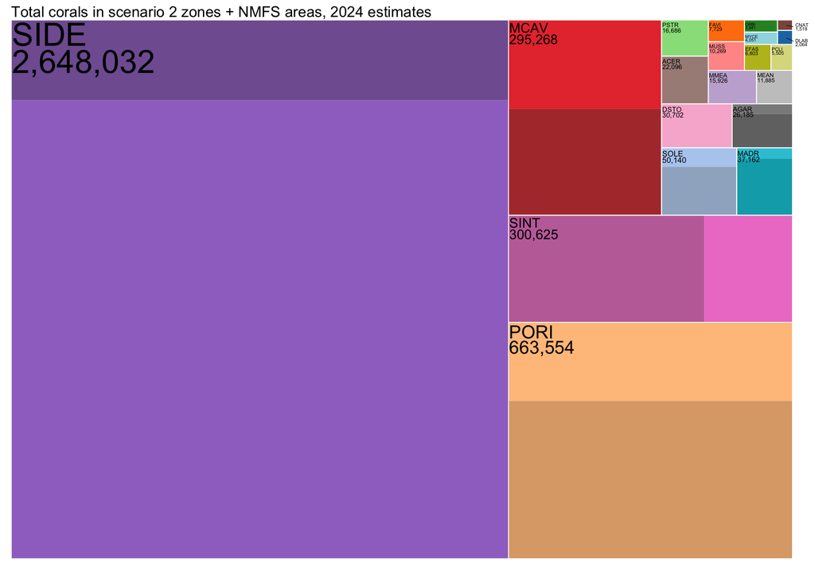

```r
# Aggregate total abundance by taxon + class
tot4_2024 <- tot2_2024 %>%
  filter(name != "Rest of Monitoring Area") %>%
  group_by(taxon, class) %>%
  summarize(tot = sum(tot), .groups = "drop")

# Add taxon_class to original data
tot4_2024 <- tot4_2024 %>%
  mutate(taxon_class = paste(taxon, class, sep = "_"))

# Plot with taxon labels only
p <- ggplot(tot4_2024, aes(area = tot, fill = taxon_class, subgroup = taxon)) +
  geom_treemap(color = NA)+#, layout = "srow") +
  geom_treemap_subgroup_border(colour = "white", size = 1)+#, layout = "srow") +
  # geom_treemap_subgroup_text(place = "topleft", grow = TRUE,
  #                             alpha = 0.8, colour = "black", size = 8) +
  scale_fill_manual(values = fill_colors) +
  theme(legend.position = "none")


# Get tile layout and attach taxon_class
tile_layout <- treemapify(tot4_2024, area = "tot",#, layout = "srow",
                          fill = "taxon_class", subgroup = "taxon")

# Flag small boxes (aggregate size classes)
tile_layout_ag <- tile_layout %>%
  group_by(taxon) %>%
  summarize(xmin = min(xmin), xmax = max(xmax),
            ymin = min(ymin), ymax = max(ymax),
            area = (xmax - xmin) * (ymax - ymin),
            center_x = (xmin + xmax) / 2,
            center_y = (ymin + ymax) / 2)
area_threshold <- 0.0009
internal_labels <- tile_layout_ag %>%
  filter(area >= area_threshold)
external_labels <- tile_layout_ag %>%
  filter(area < area_threshold)

# Create labels with taxontotals
taxtots <- tot4_2024 %>%
  group_by(taxon) %>%
  summarize(tot = scales::comma(sum(tot)))

internal_labels <- left_join(internal_labels, taxtots) %>%
  mutate(label = paste0(taxon, "\n", tot))

external_labels <- left_join(external_labels, taxtots) %>%
  mutate(label = paste0(taxon, "\n", tot))

# Final plot
p +
  scale_x_continuous(limits = c(0, 1), expand = c(0, 0)) +
  scale_y_continuous(limits = c(0, 1), expand = c(0, 0)) +
  coord_cartesian(clip = "off") +
  geom_text(data = internal_labels,
            aes(x = xmin, y = ymax-0.00001,
                label = label, size = area), inherit.aes = FALSE,
            hjust = 0, vjust = 1, lineheight = 0.7,
            nudge_x = 0.001, nudge_y = -0.005) +
  scale_size_continuous(range = c(1.3, 10)) +
  geom_text_repel(data = external_labels,
             aes(x = center_x, y = center_y,
                 label = label), inherit.aes = FALSE,
             max.overlaps = Inf,
             box.padding = 0.18,
             xlim = c(1, NA),
             force = 3,
             lineheight = 0.7,
             min.segment.length = 0.1,
             segment.size = 0.2,
             hjust = 0,
             size = 1.5, seed = 123) +
  theme_void() +
  theme(
    legend.position = "none",
    plot.margin = margin(t = 0, r = 20, b = 10, l = 10),
    plot.background = element_rect(fill = "white", color = NA),
  ) +
  labs(title = "Total corals in scenario 2 zones + NMFS areas, 2024 estimates")
```

```r
save_figure(filename = output_file("FigA5.png"), width = 180, height = 130, units = "mm", dpi = 600)
```

#### 7.3.2.2 Treemap plot - Full monitoring area

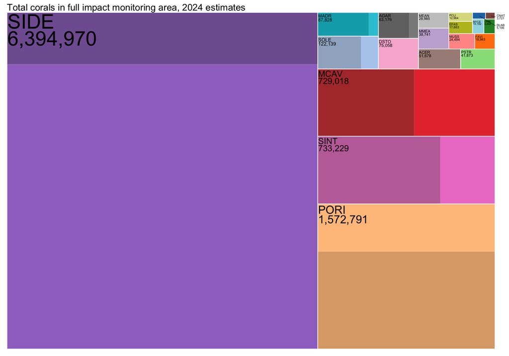

```r
# TOTAL COLONIES IN EACH IMPACT ZONE
densities_tot_2024 <- summary_drm24_combined %>% filter(class != "All")


# Calculate total per taxclass per habitat Type and impact zone
tot1_2024 <- left_join(densities_tot_2024, area_summary, by = "Type") %>%
  mutate(tot = n_m2 * total_area_m2,
         tot_lower = n_m2 * total_area_m2,
         tot_upper = n_m2 * total_area_m2)

# Calculate total per taxclass per impact zone (sum all habitat Types)
tot2_2024 <- tot1_2024 %>%
  group_by(taxon, class, name) %>%
  summarize(tot = round(sum(tot))) %>%
  arrange(name)

# Aggregate total abundance by taxon + class
tot4_2024 <- tot2_2024 %>%
  group_by(taxon, class) %>%
  summarize(tot = sum(tot), .groups = "drop")

# Add taxon_class to original data
tot4_2024 <- tot4_2024 %>%
  mutate(taxon_class = paste(taxon, class, sep = "_"))

# Plot with taxon labels only
p <- ggplot(tot4_2024, aes(area = tot, fill = taxon_class, subgroup = taxon)) +
  geom_treemap(color = NA)+#, layout = "srow") +
  geom_treemap_subgroup_border(colour = "white", size = 1)+#, layout = "srow") +
  # geom_treemap_subgroup_text(place = "topleft", grow = TRUE,
  #                             alpha = 0.8, colour = "black", size = 8) +
  scale_fill_manual(values = fill_colors) +
  theme(legend.position = "none")


# Get tile layout and attach taxon_class
tile_layout <- treemapify(tot4_2024, area = "tot",#, layout = "srow",
                          fill = "taxon_class", subgroup = "taxon")

# Flag small boxes (aggregate size classes)
tile_layout_ag <- tile_layout %>%
  group_by(taxon) %>%
  summarize(xmin = min(xmin), xmax = max(xmax),
            ymin = min(ymin), ymax = max(ymax),
            area = (xmax - xmin) * (ymax - ymin),
            center_x = (xmin + xmax) / 2,
            center_y = (ymin + ymax) / 2)
area_threshold <- 0.0009
internal_labels <- tile_layout_ag %>%
  filter(area >= area_threshold)
external_labels <- tile_layout_ag %>%
  filter(area < area_threshold)

# Create labels with taxontotals
taxtots <- tot4_2024 %>%
  group_by(taxon) %>%
  summarize(tot = scales::comma(sum(tot)))

internal_labels <- left_join(internal_labels, taxtots) %>%
  mutate(label = paste0(taxon, "\n", tot))

external_labels <- left_join(external_labels, taxtots) %>%
  mutate(label = paste0(taxon, "\n", tot))

# Final plot
p +
  scale_x_continuous(limits = c(0, 1), expand = c(0, 0)) +
  scale_y_continuous(limits = c(0, 1), expand = c(0, 0)) +
  coord_cartesian(clip = "off") +
  geom_text(data = internal_labels,
            aes(x = xmin, y = ymax-0.00001,
                label = label, size = area), inherit.aes = FALSE,
            hjust = 0, vjust = 1, lineheight = 0.7,
            nudge_x = 0.001, nudge_y = -0.005) +
  scale_size_continuous(range = c(1.3, 10)) +
  geom_text_repel(data = external_labels,
             aes(x = center_x, y = center_y,
                 label = label), inherit.aes = FALSE,
             max.overlaps = Inf,
             box.padding = 0.18,
             xlim = c(1, NA),
             force = 3,
             lineheight = 0.7,
             min.segment.length = 0.1,
             segment.size = 0.2,
             hjust = 0,
             size = 1.5, seed = 123) +
  theme_void() +
  theme(
    legend.position = "none",
    plot.margin = margin(t = 0, r = 20, b = 10, l = 10),
    plot.background = element_rect(fill = "white", color = NA),
  ) +
  labs(title = "Total corals in full impact monitoring area, 2024 estimates")
```

```r
save_figure(filename = output_file("FigA6.png"), width = 180, height = 130, units = "mm", dpi = 600)


#save_figure(filename = output_file("FigA62.png"), width = 180, height = 90, units = "mm", dpi = 600)
```

# 8 Extra figures

```r
pp3 <- ggplot(polygons_final) +
    geom_sf(aes(fill = Type), color = NA, size = 0.1, alpha = 0.5) +
    geom_point(
        data = selected,
        aes(x = longitude, y = latitude),
        pch = 4, alpha = 0.6, size = 1, stroke = 0.4, inherit.aes = FALSE
    ) +
    scale_fill_manual(values = typecols, na.value = "gray80") +
    facet_wrap(~ dataset, ncol = 3,
               labeller = as_labeller(c(
                   "nsu11_esa" = "2011 – NSU ESA Survey",
                   "dca17_esa" = "2017 – DCA ESA Survey",
                   "dca17"     = "2017 – DCA Recon Survey",
                   "tt21"      = "2021 – Tetra Tech Survey",
                   "tt23"      = "2023 – Tetra Tech Survey",
                   "drm24"     = "2024 – Shedd Survey"
               ))) +
    #coord_limits +
    labs(title = NULL, fill = NULL) +
    base_theme +
    theme(
        legend.position = "bottom",
        strip.text = element_text(size = 6),
        panel.spacing = unit(0.5, "lines")
    ) +
  geom_segment(
    data = scale_lines,
    aes(x = x, y = y, xend = xend, yend = yend),
    inherit.aes = FALSE,
    color = "black",
    linewidth = 0.4
  ) +
  geom_segment(
    data = ticks_segments,
    aes(x = x, y = y, xend = xend, yend = yend),
    color = "black",
    linewidth = 0.3
  ) +
  geom_text(
    data = tick_labels,
    aes(x = x, y = y, label = label),
    hjust = 1,
    #vjust = c(rep(1.5, 4), rep(-0.5, 4)),
    size = 1.7
  ) +
  theme(plot.margin = margin(0,0,0,0),
        strip.text = element_text(size = 10, margin = margin(t = 8, b = -8)),
        strip.clip = "off")


save_figure(pp3, filename = output_file("survey_locations.png"), width = 180, height = 220, units = "mm", dpi = 300, bg = "white")
```

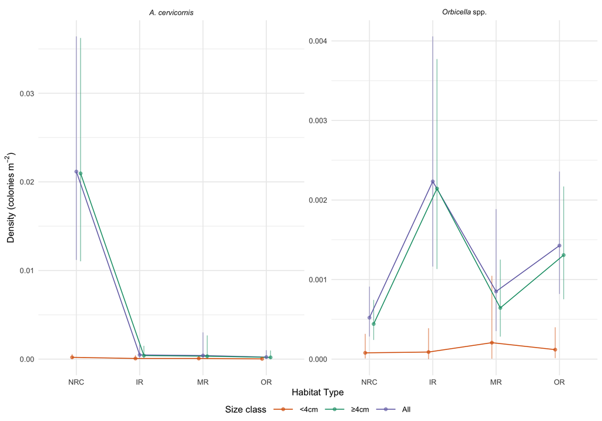

```r
# Create plot for just ACER/ORBI
make_taxon_density_plot(densities = summary_equal_weighted_combined %>%
                          filter(taxon %in% c("ACER", "ORBI")),
                        output_path = output_file("ACERORBI.png"),
                        width = 120, height = 70)
```

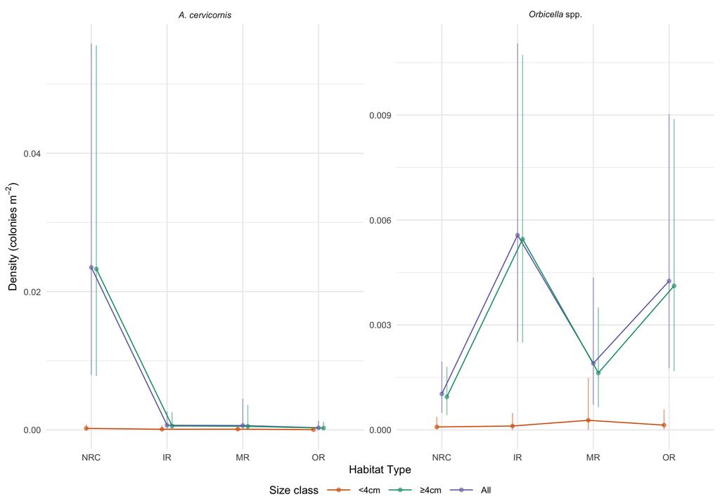

```r
make_taxon_density_plot(densities = summary_drm24_combined %>%
                          filter(taxon %in% c("ACER", "ORBI")),
                        output_path = output_file("ACERORBI_2024.png"),
                        width = 120, height = 70)
```

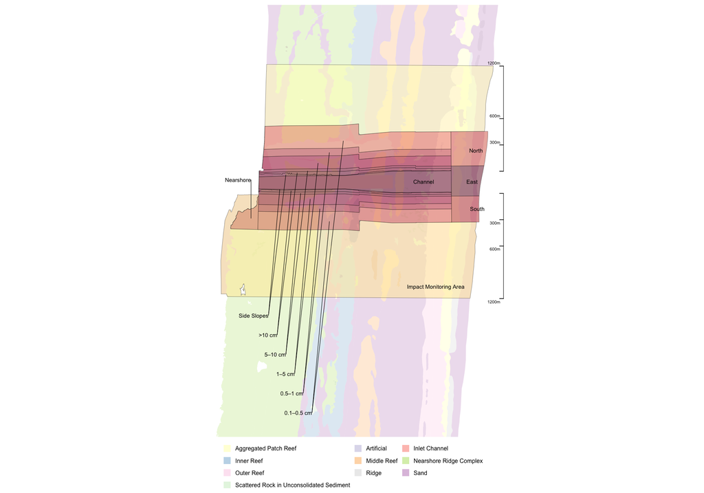

```r
iz_plot_clean2 <- iz_plot_clean +
  coord_sf(xlim = c(-80.1116, -80.077),
           ylim = c(26.0675, 26.112), expand = FALSE) +
  theme(plot.margin = margin(5,5,5,5))

legend_plot <- polyplot +
  scale_fill_manual(values = typecols, na.value = "gray80") +
  guides(
    shape = "none",
    color = "none",
    fill  = guide_legend(nrow = 4, byrow = T)   # <- 3 rows
  ) +
  base_theme +
  theme(
    legend.position = "bottom",
    legend.key.size = unit(0.3, "cm"),
    legend.text = element_text(size = 6),
    legend.title = element_text(size = 7),
    legend.box = "vertical"                         # helps with multi-row at bottom
  )

grob <- ggplotGrob(legend_plot)
fill_legend2 <- gtable::gtable_filter(grob, "guide-box")


zonefig <- plot_grid(iz_plot_clean2, fill_legend2, ncol = 1, rel_heights = c(0.9, 0.1))



zonefig
```

```r
save_figure(zonefig, filename = output_file("zonefig.png"), width = 110, height = 170, units = "mm", bg = "white")
```